# PBS Utah Major-Donor Prospecting: Individual Modeling Notebook

- Show All Code
- Hide All Code
- View Source

Published

November 5, 2026

```r
# Run once if needed:
# install.packages(c("tidyverse", "janitor", "skimr", "naniar", "lubridate", "here"))

library(tidyverse)
library(janitor)
library(skimr)
library(naniar)
library(lubridate)
library(here)

theme_set(theme_minimal())
options(dplyr.summarise.inform = FALSE, scipen = 999)

# Shared modeling helper: fiscal years run July through June.
fiscal_year_from_date <- function(date) {
  year(date) + if_else(month(date) >= 7, 1L, 0L)
}

# Raw source files are stored in the project's tables/ folder. Keep this path
# relative so the document works after cloning the project.
data_dir <- here("tables")
```

## Executive summary

This notebook evaluates three separate PBS Utah decision-support workflows using fiscal-year rolling tests, training-only preprocessing, realistic contact capacities, and paired bootstrap uncertainty.

- **Active never-major prospects:** prior-year giving is the operational benchmark; giving-history Ridge is exploratory because its modest observed improvement was not statistically reliable.
- **Current-major retention risk:** giving-history Ridge is the final ranking model because it reliably outperformed the decline/recency benchmark at top-25 and top-50 capacities.
- **Former-major reactivation:** prior-year giving remains the preferred transparent benchmark because Ridge did not show a reliable improvement.

Rankings are decision support, not automated outreach decisions, and should be prospectively validated with PBS outreach outcomes.

## 1. Data Preparation for Modeling

PBS Utah wants to identify current non-major donors who are likely to reach $1,200 or more in annual giving. The immediate outcome is conversion within 12 months; if the historical data supports it, the longer-term outcome will be conversion within 3-5 years. This analysis uses constituent, payment, legacy giving, soft-credit, campaign, Passport viewing, cultivation, and officer-portfolio data.

The purpose of this EDA is to assess data quality, coverage, and useful patterns before building a time-based prediction model. All records in this release are synthetic, so no row represents a real constituent or gift.

```r
# This check makes the expected source files explicit before any analysis.
expected_files <- c(
  "constituents_w_memberships.csv",
  "unite_payments.csv",
  "team_approach_legacy_payments.csv",
  "soft_credits.csv",
  "campaign_codes.csv",
  "campaign_members.csv",
  "passport_viewing.csv",
  "cultivation.csv",
  "officer_portfolios.csv"
)

tibble(file = expected_files, exists = file.exists(file.path(data_dir, expected_files)))
```

```
# A tibble: 9 × 2
  file                              exists
  <chr>                             <lgl>
1 constituents_w_memberships.csv    TRUE
2 unite_payments.csv                TRUE
3 team_approach_legacy_payments.csv TRUE
4 soft_credits.csv                  TRUE
5 campaign_codes.csv                TRUE
6 campaign_members.csv              TRUE
7 passport_viewing.csv              TRUE
8 cultivation.csv                   TRUE
9 officer_portfolios.csv            TRUE
```

## 2. Data inventory and grain/key documentation

These datasets have different grains, including one row per constituent, payment, solicitation, or constituent-year-genre. They should not be joined at the raw-row level because doing so can duplicate records. Transactional datasets will later be aggregated to a common donor-fiscal-year grain before modeling.

| File | Row represents / type | Unique key and links | Rows / unique constituents | Coverage | Data-quality findings |
| --- | --- | --- | --- | --- | --- |
| `constituents_w_memberships.csv` | One constituent snapshot; attribute table | Constituent ID; referenced by most datasets | 196,167 / 196,167 | End-of-data snapshot; no dates | No missing or duplicate IDs; no duplicate rows; ages are 0–120. |
| `unite_payments.csv` | One payment; transaction table | payment_id; donor_id → Constituent ID; marketing_code → campaign code | 1,722,698 / 71,643 IDs (71,642 matched constituents + SYN-ORPHAN) | FY2021–FY2026, 2020-07-01 to 2026-06-30 | Content-based valid-twin checks remove 36,044 invalid-link or nonpositive copies; 1,686,654 rows remain. Synthetic labels are audit-only. |
| `team_approach_legacy_payments.csv` | One legacy gift/payment; transaction table | No unique transaction ID. ta_account_id is a repeating household account; constituent_id_1–_7 → Constituent ID | 1,202,857 / 109,284 linked constituents | 1983-07-26 to 2020-06-28, pre-FY2021 | All amounts are positive. Cleaning removes 216,128 rows with no linked constituent before allocation, leaving 986,729 retained rows. |
| `soft_credits.csv` | One soft credit; transaction table | Credit ID; Soft Credit Constituent ID → Constituent ID | 4,145 / 3,028 IDs (3,027 matched + SYN-ORPHAN) | FY2021–FY2026, 2020-07-01 to 2026-06-29 | Exact duplicates are removed first; valid-twin checks then remove invalid-recipient or nonpositive copies. Total removal: 192 rows; 3,953 remain. |
| `campaign_codes.csv` | One marketing/campaign code; reference table | Marketing Code; used by campaign members and payments | 29,249 / n.a. | No transaction date; includes initiative fields | No missing or duplicate keys or rows. All records are marked Active and Solicitation. |
| `campaign_members.csv` | One constituent solicitation/campaign-membership record; workflow/operational table | No unique key. constituent_id → Constituent ID; marketing_code → Marketing Code | 5,233,404 / 181,680 | FY2021–FY2026; campaign markers 2020-07-01 to 2025-07-01; responses through 2026-06-30 | Links are complete and valid. 56,689 exact duplicate rows; constituent/code pairs repeat in 58,786 rows, sometimes valid under the documented solicitation rules. |
| `passport_viewing.csv` | One constituent × fiscal year × genre viewing record; behavioral attribute table | Composite constituent_id + fiscal_year + genre; constituent ID → Constituent ID | 444,741 / 70,515 | FY2021–FY2026 | Composite key is unique; all IDs link; no duplicate rows; viewing counts are positive and watch percentages are within 0–1. |
| `cultivation.csv` | One constituent-year portfolio assignment; workflow/operational table | Composite synthetic_id + fiscal_year; IDs → Constituent ID and portfolio_id → officer portfolios | 4,000 / 2,398 | FY2022–FY2025 | Composite key is unique; all links and binary flags are valid; no duplicate rows. |
| `officer_portfolios.csv` | One officer portfolio; workflow/reference table | portfolio_id; referenced by cultivation | 8 / n.a. | Rollout FYs: 2023–2026 | No missing or duplicate keys or rows. |

**Key implications:** Payments, soft credits, campaign memberships, and Passport viewing are one-to-many relative to constituents and cannot be raw-joined without duplicating records. Campaign-member repeats are retained because they can represent valid solicitations. Content-based valid-twin checks remove copied Unite-payment and soft-credit rows, while unlinked legacy rows are removed before allocation. Individual giving uses non-organization direct payments plus soft credits, so organization-payment dollars are not double counted. Current constituent attributes are end-of-data snapshots and will need time-aware handling later to prevent leakage.

```r
# Import as character first where IDs could otherwise be reformatted. Convert
# dates and numeric measures deliberately in the cleaning section.
constituents_raw <- read_csv(file.path(data_dir, "constituents_w_memberships.csv"),
                             show_col_types = FALSE)
unite_payments_raw <- read_csv(file.path(data_dir, "unite_payments.csv"),
                               show_col_types = FALSE)
legacy_payments_raw <- read_csv(file.path(data_dir, "team_approach_legacy_payments.csv"),
                                show_col_types = FALSE)
soft_credits_raw <- read_csv(file.path(data_dir, "soft_credits.csv"),
                             show_col_types = FALSE)
campaign_codes_raw <- read_csv(file.path(data_dir, "campaign_codes.csv"),
                               show_col_types = FALSE)
campaign_members_raw <- read_csv(file.path(data_dir, "campaign_members.csv"),
                                 show_col_types = FALSE)
passport_raw <- read_csv(file.path(data_dir, "passport_viewing.csv"),
                         show_col_types = FALSE)
cultivation_raw <- read_csv(file.path(data_dir, "cultivation.csv"),
                            show_col_types = FALSE)
portfolios_raw <- read_csv(file.path(data_dir, "officer_portfolios.csv"),
                           show_col_types = FALSE)
```

```r
# A compact inventory checks expected scale and schema before transformations.
raw_tables <- list(
  constituents = constituents_raw,
  unite_payments = unite_payments_raw,
  legacy_payments = legacy_payments_raw,
  soft_credits = soft_credits_raw,
  campaign_codes = campaign_codes_raw,
  campaign_members = campaign_members_raw,
  passport_viewing = passport_raw,
  cultivation = cultivation_raw,
  officer_portfolios = portfolios_raw
)

imap_dfr(raw_tables, ~ tibble(
  table = .y,
  rows = nrow(.x),
  columns = ncol(.x),
  column_names = paste(names(.x), collapse = ", ")
))
```

```
# A tibble: 9 × 4
  table                 rows columns column_names
  <chr>                <int>   <int> <chr>
1 constituents        196167      22 Constituent ID, Spouse Constituent ID, Add…
2 unite_payments     1722698      13 donor_id, designation_detail_id, credit_da…
3 legacy_payments    1202857      44 ta_account_id, gift_kind, gift_type, gift_…
4 soft_credits          4145       9 Credit ID, Designation Detail ID, Soft Cre…
5 campaign_codes       29249      17 Marketing Code, Source Category, Campaign …
6 campaign_members   5233404       8 constituent_id, marketing_code, campaign_n…
7 passport_viewing    444741       5 constituent_id, fiscal_year, genre, titles…
8 cultivation           4000       7 synthetic_id, fiscal_year, portfolio_id, s…
9 officer_portfolios       8       4 portfolio_id, officer_id, capacity, rollou…
```

## 3. Raw data quality checks

### Loading and structural checks

The following code loads the raw files and verifies their basic structure before any transformations or joins. This creates a compact baseline for checking that each expected file is readable and has the expected scale.

```r
# Standardize names immediately after import so all later code can use
# consistent snake_case column names.
constituents <- read_csv(file.path(data_dir, "constituents_w_memberships.csv"),
                         show_col_types = FALSE) |>
  clean_names()
unite_payments <- read_csv(file.path(data_dir, "unite_payments.csv"),
                           show_col_types = FALSE) |>
  clean_names()
legacy_payments <- read_csv(file.path(data_dir, "team_approach_legacy_payments.csv"),
                            show_col_types = FALSE) |>
  clean_names()
soft_credits <- read_csv(file.path(data_dir, "soft_credits.csv"),
                         show_col_types = FALSE) |>
  clean_names()
campaign_codes <- read_csv(file.path(data_dir, "campaign_codes.csv"),
                           show_col_types = FALSE) |>
  clean_names()
campaign_members <- read_csv(file.path(data_dir, "campaign_members.csv"),
                             show_col_types = FALSE) |>
  clean_names()
passport_viewing <- read_csv(file.path(data_dir, "passport_viewing.csv"),
                             show_col_types = FALSE) |>
  clean_names()
cultivation <- read_csv(file.path(data_dir, "cultivation.csv"),
                        show_col_types = FALSE) |>
  clean_names()
officer_portfolios <- read_csv(file.path(data_dir, "officer_portfolios.csv"),
                               show_col_types = FALSE) |>
  clean_names()

raw_data <- list(
  "constituents_w_memberships.csv" = constituents,
  "unite_payments.csv" = unite_payments,
  "team_approach_legacy_payments.csv" = legacy_payments,
  "soft_credits.csv" = soft_credits,
  "campaign_codes.csv" = campaign_codes,
  "campaign_members.csv" = campaign_members,
  "passport_viewing.csv" = passport_viewing,
  "cultivation.csv" = cultivation,
  "officer_portfolios.csv" = officer_portfolios
)

structural_summary <- imap_dfr(raw_data, ~ tibble(
  file_name = .y,
  total_rows = nrow(.x),
  total_columns = ncol(.x),
  exact_duplicate_rows = nrow(.x) - nrow(distinct(.x)),
  total_missing_values = sum(is.na(.x))
))

knitr::kable(structural_summary, format = "pipe")
```

| file_name | total_rows | total_columns | exact_duplicate_rows | total_missing_values |
| --- | --- | --- | --- | --- |
| constituents_w_memberships.csv | 196167 | 22 | 0 | 1193242 |
| unite_payments.csv | 1722698 | 13 | 0 | 0 |
| team_approach_legacy_payments.csv | 1202857 | 44 | 0 | 25466685 |
| soft_credits.csv | 4145 | 9 | 79 | 0 |
| campaign_codes.csv | 29249 | 17 | 0 | 29249 |
| campaign_members.csv | 5233404 | 8 | 56689 | 10321394 |
| passport_viewing.csv | 444741 | 5 | 0 | 0 |
| cultivation.csv | 4000 | 7 | 0 | 0 |
| officer_portfolios.csv | 8 | 4 | 0 | 1 |

This structural check is designed to identify unexpected file sizes, schema differences, exact duplicate records, and missing-data volume before detailed quality checks begin. It does not make cleaning decisions or interpret any findings.

### Missing-data checks

Missingness must be assessed by column because it can reflect unavailable information, an unknown value, or a valid absence of activity.

```r
missing_data_summary <- imap_dfr(raw_data, function(data, file) {
  map_dfr(names(data), function(column) {
    values <- data[[column]]

    tibble(
      file_name = file,
      column_name = column,
      missing_na = sum(is.na(values)),
      percent_missing = 100 * mean(is.na(values)),
      blank_strings = if (is.character(values)) {
        sum(!is.na(values) & trimws(values) == "")
      } else {
        0L
      }
    )
  })
}) |>
  filter(missing_na > 0 | blank_strings > 0) |>
  arrange(desc(percent_missing))

knitr::kable(missing_data_summary, format = "pipe", digits = 1)
```

| file_name | column_name | missing_na | percent_missing | blank_strings |
| --- | --- | --- | --- | --- |
| constituents_w_memberships.csv | uof_u_degree_info | 196167 | 100.0 | 0 |
| constituents_w_memberships.csv | latest_uof_u_degree_year | 196167 | 100.0 | 0 |
| constituents_w_memberships.csv | uof_u_employment_status | 196167 | 100.0 | 0 |
| team_approach_legacy_payments.csv | source_description | 1202857 | 100.0 | 0 |
| team_approach_legacy_payments.csv | county | 1202857 | 100.0 | 0 |
| team_approach_legacy_payments.csv | program | 1202857 | 100.0 | 0 |
| team_approach_legacy_payments.csv | premium_1_code | 1202857 | 100.0 | 0 |
| team_approach_legacy_payments.csv | premium_1_name | 1202857 | 100.0 | 0 |
| team_approach_legacy_payments.csv | premium_2_code | 1202857 | 100.0 | 0 |
| team_approach_legacy_payments.csv | premium_2_name | 1202857 | 100.0 | 0 |
| team_approach_legacy_payments.csv | premium_3_code | 1202857 | 100.0 | 0 |
| team_approach_legacy_payments.csv | premium_3_name | 1202857 | 100.0 | 0 |
| team_approach_legacy_payments.csv | premium_4_code | 1202857 | 100.0 | 0 |
| team_approach_legacy_payments.csv | premium_4_name | 1202857 | 100.0 | 0 |
| team_approach_legacy_payments.csv | premium_5_code | 1202857 | 100.0 | 0 |
| team_approach_legacy_payments.csv | premium_5_name | 1202857 | 100.0 | 0 |
| team_approach_legacy_payments.csv | premium_6_code | 1202857 | 100.0 | 0 |
| team_approach_legacy_payments.csv | premium_6_name | 1202857 | 100.0 | 0 |
| team_approach_legacy_payments.csv | constituent_id_3 | 1202857 | 100.0 | 0 |
| team_approach_legacy_payments.csv | constituent_id_4 | 1202857 | 100.0 | 0 |
| team_approach_legacy_payments.csv | constituent_id_5 | 1202857 | 100.0 | 0 |
| team_approach_legacy_payments.csv | constituent_id_6 | 1202857 | 100.0 | 0 |
| team_approach_legacy_payments.csv | constituent_id_7 | 1202857 | 100.0 | 0 |
| campaign_codes.csv | campaign_description | 29249 | 100.0 | 0 |
| constituents_w_memberships.csv | major_donor_class_pbs_utah | 195608 | 99.7 | 0 |
| team_approach_legacy_payments.csv | constituent_id_2 | 1193417 | 99.2 | 0 |
| campaign_members.csv | response_type | 5160697 | 98.6 | 0 |
| campaign_members.csv | responded_date | 5160697 | 98.6 | 0 |
| constituents_w_memberships.csv | spouse_constituent_id | 178807 | 91.2 | 0 |
| constituents_w_memberships.csv | marital_status | 178807 | 91.2 | 0 |
| constituents_w_memberships.csv | address_city | 51497 | 26.3 | 0 |
| team_approach_legacy_payments.csv | constituent_id_1 | 216128 | 18.0 | 0 |
| officer_portfolios.csv | rollout_fy | 1 | 12.5 | 0 |
| constituents_w_memberships.csv | address_zip | 2 | 0.0 | 0 |
| constituents_w_memberships.csv | age | 2 | 0.0 | 0 |
| constituents_w_memberships.csv | annual_giving_group | 2 | 0.0 | 0 |
| constituents_w_memberships.csv | uof_u_degree_count | 2 | 0.0 | 0 |
| constituents_w_memberships.csv | gender | 2 | 0.0 | 0 |
| constituents_w_memberships.csv | has_uof_u_legacy_gift | 2 | 0.0 | 0 |
| constituents_w_memberships.csv | legacy_circle_member_pbs_utah | 2 | 0.0 | 0 |
| constituents_w_memberships.csv | lifetime_uof_u_fundraising | 2 | 0.0 | 0 |
| constituents_w_memberships.csv | previous_fy_uof_u_cash | 2 | 0.0 | 0 |
| constituents_w_memberships.csv | prospect_committed_giving_amount_uof_u | 2 | 0.0 | 0 |
| constituents_w_memberships.csv | sustainer_pbs_utah | 2 | 0.0 | 0 |

### Key and duplicate checks

Repeated activity is not always a duplicate: a donor can have many payments or solicitations. Duplicates must therefore be evaluated using each dataset’s documented key.

```r
key_specs <- list(
  constituents = c("constituent_id"),
  unite_payments = c("payment_id"),
  campaign_codes = c("marketing_code"),
  passport_viewing = c("constituent_id", "fiscal_year", "genre"),
  cultivation = c("synthetic_id", "fiscal_year"),
  officer_portfolios = c("portfolio_id")
)

key_quality_summary <- imap_dfr(key_specs, function(key_columns, dataset_name) {
  data <- get(dataset_name)
  missing_key <- reduce(map(key_columns, function(column) {
    values <- data[[column]]
    is.na(values) | (is.character(values) & trimws(values) == "")
  }), `|`)

  valid_keys <- data |>
    filter(!missing_key) |>
    select(all_of(key_columns))

  duplicate_key_rows <- valid_keys |>
    group_by(across(all_of(key_columns))) |>
    summarise(rows_per_key = n(), .groups = "drop") |>
    filter(rows_per_key > 1) |>
    summarise(rows_in_duplicated_keys = sum(rows_per_key)) |>
    pull(rows_in_duplicated_keys)

  tibble(
    dataset = dataset_name,
    total_rows = nrow(data),
    rows_with_missing_key = sum(missing_key),
    distinct_keys = nrow(distinct(valid_keys)),
    rows_in_duplicated_keys = replace_na(duplicate_key_rows, 0L)
  )
})

knitr::kable(key_quality_summary, format = "pipe")
```

| dataset | total_rows | rows_with_missing_key | distinct_keys | rows_in_duplicated_keys |
| --- | --- | --- | --- | --- |
| constituents | 196167 | 0 | 196167 | 0 |
| unite_payments | 1722698 | 0 | 1722698 | 0 |
| campaign_codes | 29249 | 0 | 29249 | 0 |
| passport_viewing | 444741 | 0 | 444741 | 0 |
| cultivation | 4000 | 0 | 4000 | 0 |
| officer_portfolios | 8 | 0 | 8 | 0 |

```r
exact_duplicate_summary <- imap_dfr(raw_data, ~ tibble(
  file_name = .y,
  exact_duplicate_rows = nrow(.x) - nrow(distinct(.x))
))

knitr::kable(exact_duplicate_summary, format = "pipe")
```

| file_name | exact_duplicate_rows |
| --- | --- |
| constituents_w_memberships.csv | 0 |
| unite_payments.csv | 0 |
| team_approach_legacy_payments.csv | 0 |
| soft_credits.csv | 79 |
| campaign_codes.csv | 0 |
| campaign_members.csv | 56689 |
| passport_viewing.csv | 0 |
| cultivation.csv | 0 |
| officer_portfolios.csv | 0 |

### Relationship and link checks

These checks verify whether foreign keys can be linked to their documented parent tables before later aggregation. An unmatched ID does not automatically mean an error because the synthetic data includes documented `SYN-ORPHAN` and legacy-data exceptions.

```r
relationship_specs <- tribble(
  ~child_dataset, ~child_key, ~parent_dataset, ~parent_key,
  "unite_payments", "donor_id", "constituents", "constituent_id",
  "soft_credits", "soft_credit_constituent_id", "constituents", "constituent_id",
  "campaign_members", "constituent_id", "constituents", "constituent_id",
  "campaign_members", "marketing_code", "campaign_codes", "marketing_code",
  "unite_payments", "marketing_code", "campaign_codes", "marketing_code",
  "passport_viewing", "constituent_id", "constituents", "constituent_id",
  "cultivation", "synthetic_id", "constituents", "constituent_id",
  "cultivation", "portfolio_id", "officer_portfolios", "portfolio_id"
)

relationship_quality_summary <- pmap_dfr(
  relationship_specs,
  function(child_dataset, child_key, parent_dataset, parent_key) {
    child_data <- get(child_dataset)
    parent_data <- get(parent_dataset)

    child_ids <- child_data |>
      transmute(foreign_key = as.character(.data[[child_key]]))
    parent_ids <- parent_data |>
      transmute(parent_key_value = as.character(.data[[parent_key]])) |>
      distinct()
    unmatched_ids <- child_ids |>
      anti_join(parent_ids, by = c("foreign_key" = "parent_key_value"))

    tibble(
      child_dataset_foreign_key = paste0(child_dataset, "$", child_key),
      parent_dataset_key = paste0(parent_dataset, "$", parent_key),
      total_child_rows = nrow(child_data),
      unmatched_child_rows = nrow(unmatched_ids),
      distinct_unmatched_ids = n_distinct(unmatched_ids$foreign_key)
    )
  }
)

knitr::kable(relationship_quality_summary, format = "pipe")
```

[output not shown]

```r
legacy_constituent_columns <- paste0("constituent_id_", 1:7)
legacy_link_matrix <- legacy_payments |>
  select(all_of(legacy_constituent_columns)) |>
  mutate(across(everything(), as.character)) |>
  as.matrix()

legacy_has_link <- rowSums(
  !is.na(legacy_link_matrix) & trimws(legacy_link_matrix) != ""
) > 0
legacy_ids <- legacy_link_matrix[
  !is.na(legacy_link_matrix) & trimws(legacy_link_matrix) != ""
]
constituent_ids <- as.character(constituents$constituent_id)

legacy_link_summary <- tibble(
  total_legacy_rows = nrow(legacy_payments),
  rows_with_no_linked_constituent = sum(!legacy_has_link),
  percent_rows_with_no_linked_constituent = 100 * mean(!legacy_has_link),
  nonmissing_legacy_constituent_ids = length(legacy_ids),
  unmatched_legacy_constituent_ids = sum(!legacy_ids %in% constituent_ids)
)

knitr::kable(legacy_link_summary, format = "pipe", digits = 1)
```

| total_legacy_rows | rows_with_no_linked_constituent | percent_rows_with_no_linked_constituent | nonmissing_legacy_constituent_ids | unmatched_legacy_constituent_ids |
| --- | --- | --- | --- | --- |
| 1202857 | 216128 | 18 | 996169 | 0 |

### Value and date-range checks

These checks identify values outside plausible ranges and describe highly skewed transaction amounts. An outlier is not automatically an error.

```r
amount_specs <- tribble(
  ~dataset, ~column,
  "unite_payments", "payment_amount",
  "legacy_payments", "payment_amount",
  "soft_credits", "credit_amount"
)

transaction_amount_summary <- pmap_dfr(amount_specs, function(dataset, column) {
  values <- get(dataset)[[column]]
  percentiles <- quantile(
    values,
    probs = c(0.25, 0.50, 0.75, 0.95),
    na.rm = TRUE,
    names = FALSE
  )

  tibble(
    amount_field = paste0(dataset, "$", column),
    missing_values = sum(is.na(values)),
    zero_values = sum(values == 0, na.rm = TRUE),
    negative_values = sum(values < 0, na.rm = TRUE),
    minimum = min(values, na.rm = TRUE),
    percentile_25 = percentiles[1],
    median = percentiles[2],
    percentile_75 = percentiles[3],
    percentile_95 = percentiles[4],
    maximum = max(values, na.rm = TRUE)
  )
})

knitr::kable(transaction_amount_summary, format = "pipe", digits = 2)
```

[output not shown]

```r
summarise_range_validity <- function(values, field, lower_bound, upper_bound) {
  tibble(
    field = field,
    missing_values = sum(is.na(values)),
    minimum = min(values, na.rm = TRUE),
    maximum = max(values, na.rm = TRUE),
    count_below_lower_bound = sum(values < lower_bound, na.rm = TRUE),
    count_above_upper_bound = sum(values > upper_bound, na.rm = TRUE)
  )
}

range_validity_summary <- bind_rows(
  summarise_range_validity(constituents$age, "constituents$age", 0, 120),
  summarise_range_validity(passport_viewing$titles_viewed,
                           "passport_viewing$titles_viewed", 0, Inf),
  summarise_range_validity(passport_viewing$mean_percent_watched,
                           "passport_viewing$mean_percent_watched", 0, 1)
)

knitr::kable(range_validity_summary, format = "pipe", digits = 2)
```

[output not shown]

```r
date_specs <- tribble(
  ~dataset, ~column,
  "unite_payments", "credit_date",
  "legacy_payments", "gift_date",
  "soft_credits", "credit_date",
  "campaign_members", "campaign_start_date",
  "campaign_members", "responded_date"
)

date_range_summary <- pmap_dfr(date_specs, function(dataset, column) {
  values <- as.Date(get(dataset)[[column]])
  nonmissing_dates <- values[!is.na(values)]

  tibble(
    date_field = paste0(dataset, "$", column),
    missing_values = sum(is.na(values)),
    minimum_date = if (length(nonmissing_dates) > 0) min(nonmissing_dates) else as.Date(NA),
    maximum_date = if (length(nonmissing_dates) > 0) max(nonmissing_dates) else as.Date(NA)
  )
})

knitr::kable(date_range_summary, format = "pipe")
```

[output not shown]

### Summary of data quality findings

The raw tables contain 79 exact soft-credit duplicates and 56,689 exact campaign-member repeats. Campaign-member repeats are retained because a constituent can legitimately receive more than one solicitation. Soft-credit duplicates are removed as the first step of the completed valid-twin cleaning process. Missingness is concentrated in fields that are either unavailable in this synthetic release or structurally blank. Several University degree/employment fields, legacy descriptive and premium fields, and campaign_description are entirely missing. Campaign response_type and responded_date are missing for most records because most solicitations did not receive a response. Spouse and marital-status fields are also largely incomplete, while only two age values are missing. The constituent table is an end-of-data snapshot, so its fields will require time-aware handling later to avoid using information that would not have been available at a historical prediction date. Most foreign-key relationships are complete. The raw unmatched payment and soft-credit IDs use the documented SYN-ORPHAN placeholder, which is reported only as an audit check. Completed content-based valid-twin cleaning removes 36,044 Unite-payment copies and 192 soft-credit copies; the former includes 1,225 invalid campaign-code copies, while the latter includes 79 exact duplicates. It also removes 216,128 unlinked legacy rows before allocation. Amounts contain no negative values; nonpositive copies with valid twins are included in the verified removals, while large gifts are retained as plausible outliers. All checked dates and Passport viewing ranges were valid.

## 4. Cleaning decisions

The raw imported tables remain unchanged. The following rules will be applied only when creating analysis-ready copies.

| Issue | Decision | Reason |
| --- | --- | --- |
| Unite payment copies | Remove only invalid donor-link, campaign-code-link, or nonpositive-amount rows when an otherwise identical valid twin exists. | Content-based twin checks avoid relying on synthetic ID labels. |
| Soft-credit copies | Remove exact duplicates first, then remove invalid-recipient or nonpositive-amount rows only when a valid twin exists. | Prevents duplicate credit while retaining unmatched records that lack a valid twin. |
| Unlinked legacy copies | Remove rows with no populated linked constituent ID before allocation. | They cannot be assigned to an individual donor. |
| Campaign-member rows | Retain all rows, including exact repeats. | Repeats can be valid solicitations. |
| Negative amounts | No action required. | None were found. |
| Fields that are 100% missing | Exclude from future feature creation. | They contain no information. |
| Structurally missing campaign response fields | Do not impute. | Missing `responded_date` and `response_type` generally indicate no recorded response. |
| Missing Passport records | Do not treat as zero viewing. | Preserve missingness and coverage as a separate concept. |
| Missing age and other partially missing constituent fields | Retain as missing for now. | Any model imputation must later be fit using training data only. |
| End-of-data constituent snapshot fields | Do not use directly as historical predictors unless a time-valid version can be created. | They could introduce data leakage. |
| Unite payments with an unmatched marketing code | Retain the payment for giving totals; treat campaign information as unknown unless the code can be mapped later. | The payment remains valid for giving analysis. |
| Large gifts | Retain. | They are plausible donor behavior, not demonstrated errors. |

The next subsection applies these rules to create analysis-ready copies while preserving the raw tables.

### Creating analysis-ready copies

The following code creates new analysis-ready objects while preserving all raw objects for audit. These copies apply only the documented record-level rules; they do not aggregate transactions, impute values, or create modeling features.

```r
content_twin_key <- function(data, columns) {
  do.call(
    paste,
    c(
      lapply(data[columns], function(value) replace_na(as.character(value), "<NA>")),
      sep = "\u001f"
    )
  )
}

valid_constituent_ids <- as.character(constituents$constituent_id)
valid_campaign_codes <- as.character(campaign_codes$marketing_code)

# A valid twin matches every substantive field except the record ID and the
# field that makes the candidate invalid. Synthetic labels are audit-only.
unite_payment_columns <- names(unite_payments)
unite_payment_candidates <- unite_payments |>
  mutate(
    valid_donor_link = donor_id %in% valid_constituent_ids,
    valid_campaign_link = marketing_code %in% valid_campaign_codes,
    valid_amount = coalesce(payment_amount > 0, FALSE)
  )

unite_donor_twin_key <- content_twin_key(
  unite_payment_candidates,
  setdiff(unite_payment_columns, c("payment_id", "donor_id"))
)
unite_campaign_twin_key <- content_twin_key(
  unite_payment_candidates,
  setdiff(unite_payment_columns, c("payment_id", "marketing_code"))
)
unite_amount_twin_key <- content_twin_key(
  unite_payment_candidates,
  setdiff(unite_payment_columns, c("payment_id", "payment_amount"))
)

unite_payments_flagged <- unite_payment_candidates |>
  mutate(
    invalid_donor_copy = !valid_donor_link &
      unite_donor_twin_key %in% unite_donor_twin_key[valid_donor_link],
    invalid_campaign_copy = !valid_campaign_link &
      unite_campaign_twin_key %in% unite_campaign_twin_key[valid_campaign_link],
    nonpositive_amount_copy = !valid_amount &
      unite_amount_twin_key %in% unite_amount_twin_key[valid_amount],
    remove_valid_twin_copy = invalid_donor_copy | invalid_campaign_copy |
      nonpositive_amount_copy
  )

unite_payments_analysis <- unite_payments_flagged |>
  filter(!remove_valid_twin_copy) |>
  mutate(
    positive_amount = valid_amount,
    campaign_code_matched = valid_campaign_link
  )

soft_credit_exact_duplicate <- duplicated(soft_credits)
soft_credits_after_exact_deduplication <- soft_credits |>
  filter(!soft_credit_exact_duplicate)
soft_credit_columns <- names(soft_credits_after_exact_deduplication)
soft_credit_candidates <- soft_credits_after_exact_deduplication |>
  mutate(
    valid_recipient_link = soft_credit_constituent_id %in% valid_constituent_ids,
    valid_amount = coalesce(credit_amount > 0, FALSE)
  )

soft_recipient_twin_key <- content_twin_key(
  soft_credit_candidates,
  setdiff(soft_credit_columns, c("credit_id", "soft_credit_constituent_id"))
)
soft_amount_twin_key <- content_twin_key(
  soft_credit_candidates,
  setdiff(soft_credit_columns, c("credit_id", "credit_amount"))
)

soft_credits_flagged <- soft_credit_candidates |>
  mutate(
    invalid_recipient_copy = !valid_recipient_link &
      soft_recipient_twin_key %in% soft_recipient_twin_key[valid_recipient_link],
    nonpositive_amount_copy = !valid_amount &
      soft_amount_twin_key %in% soft_amount_twin_key[valid_amount],
    remove_valid_twin_copy = invalid_recipient_copy | nonpositive_amount_copy,
    positive_amount = valid_amount
  )

soft_credits_analysis <- soft_credits_flagged |>
  filter(!remove_valid_twin_copy)

legacy_id_columns <- paste0("constituent_id_", 1:7)
legacy_payment_candidates <- legacy_payments |>
  mutate(
    has_linked_constituent = if_any(
      all_of(legacy_id_columns),
      ~ !is.na(.x) & trimws(as.character(.x)) != ""
    ),
    remove_unlinked_copy = !has_linked_constituent
  )
legacy_payments_analysis <- legacy_payment_candidates |>
  filter(!remove_unlinked_copy)

campaign_members_analysis <- campaign_members

organization_constituents <- constituents |>
  filter(
    primary_constituent_type == "Organization" |
      str_detect(
        coalesce(as.character(constituent_type), ""),
        regex("Organization", ignore_case = TRUE)
      )
  ) |>
  select(constituent_id, primary_constituent_type, constituent_type)

unite_payments_analysis <- unite_payments_analysis |>
  mutate(organization_payment = donor_id %in% organization_constituents$constituent_id)

constituents_analysis <- constituents
passport_viewing_analysis <- passport_viewing
cultivation_analysis <- cultivation
officer_portfolios_analysis <- officer_portfolios
campaign_codes_analysis <- campaign_codes
```

```r
analysis_ready_audit <- bind_rows(
  tibble(
    dataset = "unite_payments",
    raw_rows = nrow(unite_payments),
    exact_duplicates_removed = NA_integer_,
    invalid_donor_link_copies_removed = sum(
      unite_payments_flagged$invalid_donor_copy
    ),
    invalid_campaign_link_copies_removed = sum(
      unite_payments_flagged$invalid_campaign_copy
    ),
    invalid_recipient_link_copies_removed = NA_integer_,
    nonpositive_amount_copies_removed = sum(
      unite_payments_flagged$nonpositive_amount_copy
    ),
    unlinked_legacy_copies_removed = NA_integer_,
    total_rows_removed = nrow(unite_payments) - nrow(unite_payments_analysis),
    final_analysis_ready_rows = nrow(unite_payments_analysis),
    synthetic_orphan_rows_in_raw = sum(unite_payments$donor_id == "SYN-ORPHAN",
                                       na.rm = TRUE)
  ),
  tibble(
    dataset = "soft_credits",
    raw_rows = nrow(soft_credits),
    exact_duplicates_removed = sum(soft_credit_exact_duplicate),
    invalid_donor_link_copies_removed = NA_integer_,
    invalid_campaign_link_copies_removed = NA_integer_,
    invalid_recipient_link_copies_removed = sum(
      soft_credits_flagged$invalid_recipient_copy
    ),
    nonpositive_amount_copies_removed = sum(
      soft_credits_flagged$nonpositive_amount_copy
    ),
    unlinked_legacy_copies_removed = NA_integer_,
    total_rows_removed = nrow(soft_credits) - nrow(soft_credits_analysis),
    final_analysis_ready_rows = nrow(soft_credits_analysis),
    synthetic_orphan_rows_in_raw = sum(
      soft_credits$soft_credit_constituent_id == "SYN-ORPHAN", na.rm = TRUE
    )
  ),
  tibble(
    dataset = "legacy_payments",
    raw_rows = nrow(legacy_payments),
    exact_duplicates_removed = NA_integer_,
    invalid_donor_link_copies_removed = NA_integer_,
    invalid_campaign_link_copies_removed = NA_integer_,
    invalid_recipient_link_copies_removed = NA_integer_,
    nonpositive_amount_copies_removed = NA_integer_,
    unlinked_legacy_copies_removed = sum(
      legacy_payment_candidates$remove_unlinked_copy
    ),
    total_rows_removed = nrow(legacy_payments) - nrow(legacy_payments_analysis),
    final_analysis_ready_rows = nrow(legacy_payments_analysis),
    synthetic_orphan_rows_in_raw = NA_integer_
  )
)

knitr::kable(analysis_ready_audit, format = "pipe")
```

| dataset | raw_rows | exact_duplicates_removed | invalid_donor_link_copies_removed | invalid_campaign_link_copies_removed | invalid_recipient_link_copies_removed | nonpositive_amount_copies_removed | unlinked_legacy_copies_removed | total_rows_removed | final_analysis_ready_rows | synthetic_orphan_rows_in_raw |
| --- | --- | --- | --- | --- | --- | --- | --- | --- | --- | --- |
| unite_payments | 1722698 | NA | 33733 | 1225 | NA | 1086 | NA | 36044 | 1686654 | 33733 |
| soft_credits | 4145 | 79 | NA | NA | 79 | 34 | NA | 192 | 3953 | 79 |
| legacy_payments | 1202857 | NA | NA | NA | NA | NA | 216128 | 216128 | 986729 | NA |

```r
stopifnot(
  analysis_ready_audit$total_rows_removed[
    analysis_ready_audit$dataset == "unite_payments"
  ] == 36044L,
  analysis_ready_audit$total_rows_removed[
    analysis_ready_audit$dataset == "soft_credits"
  ] == 192L,
  analysis_ready_audit$exact_duplicates_removed[
    analysis_ready_audit$dataset == "soft_credits"
  ] == 79L,
  analysis_ready_audit$total_rows_removed[
    analysis_ready_audit$dataset == "legacy_payments"
  ] == 216128L
)
```

## 5. Data Preparation for Modeling

## 6. Building the donor–fiscal-year dataset

### Annual giving base

The model needs one record per constituent per fiscal year. Individual annual giving equals positive non-organization direct payments plus positive soft credits. Legacy payments are handled separately because they are household- level and predate FY2021.

```r
positive_individual_unite_payments <- unite_payments_analysis |>
  filter(!organization_payment, positive_amount) |>
  mutate(fiscal_year = paste0("FY", fiscal_year_from_date(credit_date)))

excluded_organization_payments <- unite_payments_analysis |>
  filter(organization_payment, positive_amount) |>
  mutate(fiscal_year = paste0("FY", fiscal_year_from_date(credit_date)))

positive_soft_credits <- soft_credits_analysis |>
  filter(positive_amount) |>
  mutate(fiscal_year = paste0("FY", fiscal_year_from_date(credit_date)))

direct_payment_transactions <- positive_individual_unite_payments |>
  transmute(
    constituent_id = as.character(donor_id),
    fiscal_year,
    gift_credit_date = credit_date,
    amount = payment_amount,
    source = "direct_payment"
  )

soft_credit_transactions <- positive_soft_credits |>
  transmute(
    constituent_id = as.character(soft_credit_constituent_id),
    fiscal_year,
    gift_credit_date = credit_date,
    amount = credit_amount,
    source = "soft_credit"
  )

constituent_giving_transactions <- bind_rows(
  direct_payment_transactions,
  soft_credit_transactions
)

donor_fiscal_year_giving <- constituent_giving_transactions |>
  group_by(constituent_id, fiscal_year) |>
  summarise(
    annual_giving = sum(amount, na.rm = TRUE),
    direct_payment_dollars = sum(amount[source == "direct_payment"], na.rm = TRUE),
    soft_credit_dollars = sum(amount[source == "soft_credit"], na.rm = TRUE),
    direct_payment_count = sum(source == "direct_payment"),
    soft_credit_count = sum(source == "soft_credit"),
    largest_gift = max(amount, na.rm = TRUE),
    first_gift_date = min(gift_credit_date, na.rm = TRUE),
    last_gift_date = max(gift_credit_date, na.rm = TRUE),
    .groups = "drop"
  )
```

```r
annual_giving_base_audit <- bind_rows(
  tibble(
    metric = "Positive individual Unite payments retained",
    rows = nrow(positive_individual_unite_payments),
    dollars = sum(positive_individual_unite_payments$payment_amount, na.rm = TRUE)
  ),
  tibble(
    metric = "Positive organization Unite payments excluded",
    rows = nrow(excluded_organization_payments),
    dollars = sum(excluded_organization_payments$payment_amount, na.rm = TRUE)
  ),
  tibble(
    metric = "Positive soft credits retained",
    rows = nrow(soft_credit_transactions),
    dollars = sum(soft_credit_transactions$amount, na.rm = TRUE)
  ),
  tibble(
    metric = "Final combined constituent-giving transactions",
    rows = nrow(constituent_giving_transactions),
    dollars = NA_real_
  ),
  tibble(
    metric = "Final donor-fiscal-year records",
    rows = nrow(donor_fiscal_year_giving),
    dollars = NA_real_
  )
)

knitr::kable(
  annual_giving_base_audit |>
    mutate(rows = scales::comma(rows),
           dollars = if_else(is.na(dollars), NA_character_,
                             scales::dollar(dollars))),
  format = "pipe"
)
```

| metric | rows | dollars |
| --- | --- | --- |
| Positive individual Unite payments retained | 1,682,701 | $17,829,077 |
| Positive organization Unite payments excluded | 3,953 | $1,802,435 |
| Positive soft credits retained | 3,953 | $1,802,435 |
| Final combined constituent-giving transactions | 1,686,654 | NA |
| Final donor-fiscal-year records | 199,772 | NA |

```r
organization_payment_audit <- excluded_organization_payments |>
  group_by(fiscal_year) |>
  summarise(
    excluded_organization_payment_dollars = sum(payment_amount, na.rm = TRUE),
    .groups = "drop"
  ) |>
  full_join(
    positive_soft_credits |>
      group_by(fiscal_year) |>
      summarise(
        retained_soft_credit_dollars = sum(credit_amount, na.rm = TRUE),
        .groups = "drop"
      ),
    by = "fiscal_year"
  ) |>
  mutate(
    across(c(excluded_organization_payment_dollars,
             retained_soft_credit_dollars), ~ replace_na(.x, 0)),
    dollar_difference = excluded_organization_payment_dollars -
      retained_soft_credit_dollars
  ) |>
  arrange(fiscal_year)

knitr::kable(organization_payment_audit, format = "pipe", digits = 2)
```

| fiscal_year | excluded_organization_payment_dollars | retained_soft_credit_dollars | dollar_difference |
| --- | --- | --- | --- |
| FY2021 | 293983 | 293983 | 0 |
| FY2022 | 256336 | 256336 | 0 |
| FY2023 | 306789 | 306789 | 0 |
| FY2024 | 207215 | 207215 | 0 |
| FY2025 | 290061 | 290061 | 0 |
| FY2026 | 448051 | 448051 | 0 |

Individual direct payments and soft credits are retained as separate credit sources; organization payments are excluded before individual-level giving is constructed and audited against soft-credit dollars by fiscal year. `designation_detail_id` is not used as a transaction-level deduplication key because it can occur on many payment records. This analysis does not attempt to calculate station revenue by summing the two sources. Organization records are already identified, and their direct payments are excluded from individual- level giving.

### Eligible donor-year panel and major-donor status

An eligible donor is a constituent with at least one positive, linked PBS Utah giving record during the available FY2021–FY2026 period. The model will later exclude donors who are already major donors at the prediction date. This definition should be confirmed with PBS Utah before deployment.

```r
eligible_donors <- donor_fiscal_year_giving |>
  distinct(constituent_id)

observed_fiscal_year_bounds <- donor_fiscal_year_giving |>
  transmute(fiscal_year_number = as.integer(stringr::str_remove(fiscal_year, "FY"))) |>
  summarise(
    first_fiscal_year = min(fiscal_year_number),
    last_fiscal_year = max(fiscal_year_number)
  )

observed_fiscal_years <- paste0(
  "FY",
  seq(observed_fiscal_year_bounds$first_fiscal_year,
      observed_fiscal_year_bounds$last_fiscal_year)
)

donor_fiscal_year_panel <- tidyr::expand_grid(
  constituent_id = eligible_donors$constituent_id,
  fiscal_year = observed_fiscal_years
) |>
  left_join(donor_fiscal_year_giving, by = c("constituent_id", "fiscal_year")) |>
  mutate(
    annual_giving = replace_na(annual_giving, 0),
    direct_payment_dollars = replace_na(direct_payment_dollars, 0),
    soft_credit_dollars = replace_na(soft_credit_dollars, 0),
    direct_payment_count = replace_na(direct_payment_count, 0L),
    soft_credit_count = replace_na(soft_credit_count, 0L),
    largest_gift = replace_na(largest_gift, 0),
    gave_this_year = annual_giving > 0,
    is_major_donor = annual_giving >= 1200,
    giving_tier = case_when(
      annual_giving == 0 ~ "No giving",
      annual_giving < 1200 ~ "Under $1,200",
      annual_giving < 2000 ~ "$1,200–$1,999",
      annual_giving < 5000 ~ "$2,000–$4,999",
      annual_giving < 10000 ~ "$5,000–$9,999",
      annual_giving < 15000 ~ "$10,000–$14,999",
      TRUE ~ "$15,000+"
    ),
    giving_tier = factor(
      giving_tier,
      levels = c(
        "No giving", "Under $1,200", "$1,200–$1,999", "$2,000–$4,999",
        "$5,000–$9,999", "$10,000–$14,999", "$15,000+"
      )
    )
  )

donor_fiscal_year_summary <- donor_fiscal_year_panel |>
  group_by(fiscal_year) |>
  summarise(
    eligible_donors = n_distinct(constituent_id),
    donors_who_gave = sum(gave_this_year),
    major_donors = sum(is_major_donor),
    major_donor_percentage = major_donors / eligible_donors,
    total_annual_giving = sum(annual_giving, na.rm = TRUE),
    major_donor_annual_giving = sum(annual_giving[is_major_donor], na.rm = TRUE),
    .groups = "drop"
  ) |>
  arrange(fiscal_year)

knitr::kable(
  donor_fiscal_year_summary |>
    mutate(
      across(c(eligible_donors, donors_who_gave, major_donors), scales::comma),
      major_donor_percentage = scales::percent(major_donor_percentage,
                                                accuracy = 0.1),
      across(c(total_annual_giving, major_donor_annual_giving), scales::dollar)
    ),
  format = "pipe"
)
```

| fiscal_year | eligible_donors | donors_who_gave | major_donors | major_donor_percentage | total_annual_giving | major_donor_annual_giving |
| --- | --- | --- | --- | --- | --- | --- |
| FY2021 | 71,811 | 30,961 | 118 | 0.2% | $2,938,489 | $314,424 |
| FY2022 | 71,811 | 31,300 | 102 | 0.1% | $2,928,205 | $172,901 |
| FY2023 | 71,811 | 33,322 | 114 | 0.2% | $3,185,707 | $244,129 |
| FY2024 | 71,811 | 32,867 | 83 | 0.1% | $3,137,128 | $162,372 |
| FY2025 | 71,811 | 32,972 | 86 | 0.1% | $3,256,715 | $231,345 |
| FY2026 | 71,811 | 38,350 | 129 | 0.2% | $4,185,268 | $395,456 |

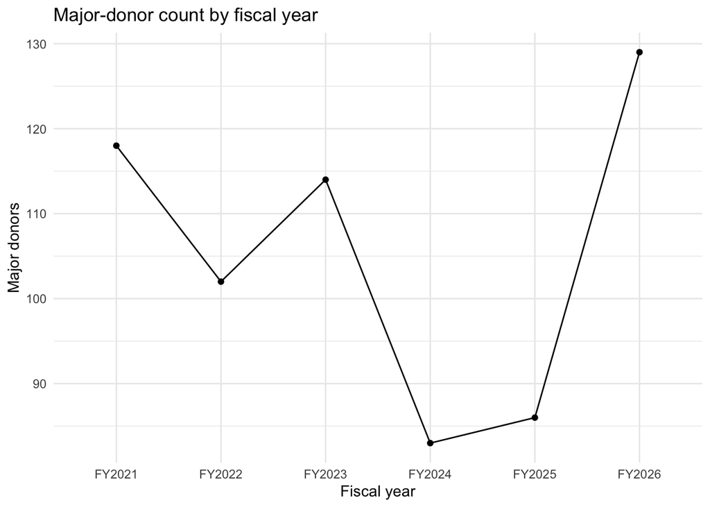

```r
ggplot(donor_fiscal_year_summary,
       aes(x = fiscal_year, y = major_donors, group = 1)) +
  geom_line() +
  geom_point() +
  scale_y_continuous(labels = scales::label_comma()) +
  labs(
    title = "Major-donor count by fiscal year",
    x = "Fiscal year",
    y = "Major donors"
  )
```

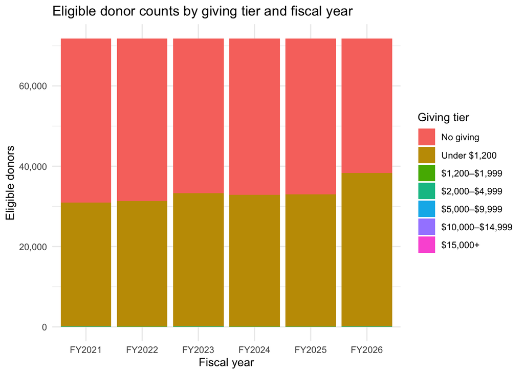

```r
donor_fiscal_year_panel |>
  count(fiscal_year, giving_tier, name = "donors") |>
  ggplot(aes(x = fiscal_year, y = donors, fill = giving_tier)) +
  geom_col() +
  scale_y_continuous(labels = scales::label_comma()) +
  labs(
    title = "Eligible donor counts by giving tier and fiscal year",
    x = "Fiscal year",
    y = "Eligible donors",
    fill = "Giving tier"
  )
```

### Individual versus organization eligibility check

The constituent table may contain both people and organizations. Because this project is intended to rank individual major-donor prospects, entity type must be understood before finalizing the eligible population.

```r
constituent_type_frequency <- bind_rows(
  constituents_analysis |>
    filter(!is.na(primary_constituent_type),
           trimws(primary_constituent_type) != "") |>
    count(primary_constituent_type, name = "constituents") |>
    mutate(type_field = "primary_constituent_type",
           type_value = primary_constituent_type) |>
    select(type_field, type_value, constituents),
  constituents_analysis |>
    filter(!is.na(constituent_type), trimws(constituent_type) != "") |>
    count(constituent_type, name = "constituents") |>
    mutate(type_field = "constituent_type", type_value = constituent_type) |>
    select(type_field, type_value, constituents)
) |>
  arrange(type_field, desc(constituents))

organization_pattern <- regex(
  "organization|foundation|business|corporation|trust|estate",
  ignore_case = TRUE
)

potential_organization_records <- constituents_analysis |>
  mutate(
    primary_constituent_type = as.character(primary_constituent_type),
    constituent_type = as.character(constituent_type)
  ) |>
  filter(
    str_detect(coalesce(primary_constituent_type, ""), organization_pattern) |
      str_detect(coalesce(constituent_type, ""), organization_pattern)
  ) |>
  select(constituent_id, primary_constituent_type, constituent_type)

knitr::kable(
  constituent_type_frequency |>
    mutate(constituents = scales::comma(constituents)),
  format = "pipe"
)
```

| type_field | type_value | constituents |
| --- | --- | --- |
| constituent_type | Friends | 103,460 |
| constituent_type | Donors | 64,514 |
| constituent_type | Alumni (Degree) | 19,073 |
| constituent_type | Alumni (No Degree) | 4,843 |
| constituent_type | Parents | 2,267 |
| constituent_type | Faculty | 721 |
| constituent_type | Staff | 626 |
| constituent_type | Emeritus Faculty | 220 |
| constituent_type | Former Staff | 164 |
| constituent_type | Former Students | 139 |
| constituent_type | Former Faculty | 131 |
| constituent_type | Other | 7 |
| constituent_type | Organization | 2 |
| primary_constituent_type | Friends | 103,460 |
| primary_constituent_type | Donors | 64,514 |
| primary_constituent_type | Alumni (Degree) | 19,073 |
| primary_constituent_type | Alumni (No Degree) | 4,843 |
| primary_constituent_type | Parents | 2,267 |
| primary_constituent_type | Faculty | 721 |
| primary_constituent_type | Staff | 626 |
| primary_constituent_type | Emeritus Faculty | 220 |
| primary_constituent_type | Former Staff | 164 |
| primary_constituent_type | Former Students | 139 |
| primary_constituent_type | Former Faculty | 131 |
| primary_constituent_type | Other | 7 |
| primary_constituent_type | Organization | 2 |

```r
knitr::kable(
  potential_organization_records |>
    summarise(
      potential_organization_records = n(),
      type_combinations = n_distinct(
        interaction(primary_constituent_type, constituent_type, drop = TRUE)
      )
    ) |>
    mutate(across(everything(), scales::comma)),
  format = "pipe",
  caption = "Aggregate potential-organization review summary"
)
```

Aggregate potential-organization review summary

| potential_organization_records | type_combinations |
| --- | --- |
| 2 | 1 |

```r
organization_panel <- potential_organization_records |>
  select(constituent_id) |>
  inner_join(donor_fiscal_year_panel, by = "constituent_id")

potential_organization_fy_summary <- organization_panel |>
  group_by(fiscal_year) |>
  summarise(
    potential_organization_constituents = n_distinct(constituent_id),
    potential_organizations_with_positive_giving = sum(gave_this_year),
    total_annual_giving = sum(annual_giving, na.rm = TRUE),
    major_donors = sum(is_major_donor),
    .groups = "drop"
  ) |>
  arrange(fiscal_year)

donor_fiscal_year_entity_comparison <- donor_fiscal_year_panel |>
  mutate(
    entity_group = if_else(
      constituent_id %in% potential_organization_records$constituent_id,
      "Potential organizations",
      "All other eligible constituents"
    )
  ) |>
  group_by(entity_group) |>
  summarise(
    donor_fiscal_year_records = n(),
    distinct_constituents = n_distinct(constituent_id),
    donor_years_with_positive_giving = sum(gave_this_year),
    total_annual_giving = sum(annual_giving, na.rm = TRUE),
    major_donor_years = sum(is_major_donor),
    .groups = "drop"
  )

knitr::kable(
  potential_organization_fy_summary |>
    mutate(
      across(c(potential_organization_constituents,
               potential_organizations_with_positive_giving, major_donors),
             scales::comma),
      total_annual_giving = scales::dollar(total_annual_giving)
    ),
  format = "pipe"
)
```

| fiscal_year | potential_organization_constituents | potential_organizations_with_positive_giving | total_annual_giving | major_donors |
| --- | --- | --- | --- | --- |

```r
knitr::kable(
  donor_fiscal_year_entity_comparison |>
    mutate(
      across(c(donor_fiscal_year_records, distinct_constituents,
               donor_years_with_positive_giving, major_donor_years),
             scales::comma),
      total_annual_giving = scales::dollar(total_annual_giving)
    ),
  format = "pipe"
)
```

| entity_group | donor_fiscal_year_records | distinct_constituents | donor_years_with_positive_giving | total_annual_giving | major_donor_years |
| --- | --- | --- | --- | --- | --- |
| All other eligible constituents | 430,866 | 71,811 | 199,772 | $19,631,512 | 632 |

```r
organization_constituents <- constituents_analysis |>
  filter(
    primary_constituent_type == "Organization" |
      str_detect(
        coalesce(as.character(constituent_type), ""),
        regex("Organization", ignore_case = TRUE)
      )
  ) |>
  select(constituent_id, primary_constituent_type, constituent_type)

modeling_donor_fiscal_year_panel <- donor_fiscal_year_panel |>
  filter(!constituent_id %in% organization_constituents$constituent_id)

summarise_panel_group <- function(data, group_name) {
  tibble(
    group = group_name,
    distinct_constituents = n_distinct(data$constituent_id),
    donor_fiscal_year_rows = nrow(data),
    donor_years_with_positive_giving = sum(data$gave_this_year),
    total_annual_giving = sum(data$annual_giving, na.rm = TRUE),
    major_donor_years = sum(data$is_major_donor)
  )
}

excluded_organization_panel <- donor_fiscal_year_panel |>
  filter(constituent_id %in% organization_constituents$constituent_id)

organization_exclusion_audit <- bind_rows(
  summarise_panel_group(donor_fiscal_year_panel,
                        "All eligible constituent records"),
  summarise_panel_group(excluded_organization_panel,
                        "Excluded organization records"),
  summarise_panel_group(modeling_donor_fiscal_year_panel,
                        "Remaining individual constituent records")
)

knitr::kable(
  organization_exclusion_audit |>
    mutate(
      across(c(distinct_constituents, donor_fiscal_year_rows,
               donor_years_with_positive_giving, major_donor_years),
             scales::comma),
      total_annual_giving = scales::dollar(total_annual_giving)
    ),
  format = "pipe"
)
```

| group | distinct_constituents | donor_fiscal_year_rows | donor_years_with_positive_giving | total_annual_giving | major_donor_years |
| --- | --- | --- | --- | --- | --- |
| All eligible constituent records | 71,811 | 430,866 | 199,772 | $19,631,512 | 632 |
| Excluded organization records | 0 | 0 | 0 | $0 | 0 |
| Remaining individual constituent records | 71,811 | 430,866 | 199,772 | $19,631,512 | 632 |

All future conversion-target and predictor analyses will use `modeling_donor_fiscal_year_panel`.

### Time-aware eligible donor panel

A donor can enter the historical modeling population only after their first positive, linked PBS Utah gift. Including a person before that first gift would use future information and create data leakage.

```r
first_giving_year <- donor_fiscal_year_giving |>
  filter(annual_giving > 0) |>
  mutate(fiscal_year_number = as.integer(stringr::str_remove(fiscal_year, "FY"))) |>
  group_by(constituent_id) |>
  summarise(first_giving_year = min(fiscal_year_number), .groups = "drop")

modeling_donor_fiscal_year_panel <- donor_fiscal_year_panel |>
  filter(!constituent_id %in% organization_constituents$constituent_id) |>
  mutate(fiscal_year_number = as.integer(stringr::str_remove(fiscal_year, "FY"))) |>
  left_join(first_giving_year, by = "constituent_id") |>
  filter(fiscal_year_number >= first_giving_year) |>
  select(-fiscal_year_number)

time_aware_individual_panel_summary <- modeling_donor_fiscal_year_panel |>
  group_by(fiscal_year) |>
  summarise(
    eligible_donors = n_distinct(constituent_id),
    donors_who_gave = sum(gave_this_year),
    major_donors = sum(is_major_donor),
    major_donor_percentage = major_donors / eligible_donors,
    total_annual_giving = sum(annual_giving, na.rm = TRUE),
    major_donor_annual_giving = sum(annual_giving[is_major_donor], na.rm = TRUE),
    .groups = "drop"
  ) |>
  arrange(fiscal_year)

knitr::kable(
  time_aware_individual_panel_summary |>
    mutate(
      across(c(eligible_donors, donors_who_gave, major_donors), scales::comma),
      major_donor_percentage = scales::percent(major_donor_percentage,
                                                accuracy = 0.1),
      across(c(total_annual_giving, major_donor_annual_giving), scales::dollar)
    ),
  format = "pipe"
)
```

| fiscal_year | eligible_donors | donors_who_gave | major_donors | major_donor_percentage | total_annual_giving | major_donor_annual_giving |
| --- | --- | --- | --- | --- | --- | --- |
| FY2021 | 30,961 | 30,961 | 118 | 0.4% | $2,938,489 | $314,424 |
| FY2022 | 39,010 | 31,300 | 102 | 0.3% | $2,928,205 | $172,901 |
| FY2023 | 47,462 | 33,322 | 114 | 0.2% | $3,185,707 | $244,129 |
| FY2024 | 53,994 | 32,867 | 83 | 0.2% | $3,137,128 | $162,372 |
| FY2025 | 60,600 | 32,972 | 86 | 0.1% | $3,256,715 | $231,345 |
| FY2026 | 71,811 | 38,350 | 129 | 0.2% | $4,185,268 | $395,456 |

This time-aware individual panel will be used to create future conversion labels in Section 7.

### Legacy giving linkage check

Legacy payments are household-level and can link to up to seven constituents. Before using them for historical donor eligibility or features, the analysis must determine how often a gift links to one person versus multiple people.

```r
legacy_id_columns <- paste0("constituent_id_", 1:7)

legacy_link_matrix <- legacy_payments_analysis |>
  select(all_of(legacy_id_columns)) |>
  mutate(across(everything(), as.character)) |>
  as.matrix()

legacy_link_present <- !is.na(legacy_link_matrix) &
  trimws(legacy_link_matrix) != ""
legacy_link_count <- rowSums(legacy_link_present)

legacy_linkage_summary <- tibble(
  linkage_group = case_when(
    legacy_link_count == 0 ~ "Zero linked constituents",
    legacy_link_count == 1 ~ "Exactly one linked constituent",
    legacy_link_count == 2 ~ "Two linked constituents",
    legacy_link_count >= 3 ~ "Three or more linked constituents"
  )
) |>
  count(linkage_group, name = "legacy_rows") |>
  mutate(percentage = legacy_rows / sum(legacy_rows)) |>
  arrange(factor(
    linkage_group,
    levels = c(
      "Zero linked constituents", "Exactly one linked constituent",
      "Two linked constituents", "Three or more linked constituents"
    )
  ))

legacy_position_summary <- tibble(
  linked_id_position = colnames(legacy_link_matrix),
  populated_rows = colSums(legacy_link_present),
  percentage_of_legacy_rows = populated_rows / nrow(legacy_link_matrix)
)

legacy_link_ids <- legacy_link_matrix[legacy_link_present]
constituent_ids <- as.character(constituents_analysis$constituent_id)
legacy_link_match_summary <- tibble(
  nonmissing_legacy_constituent_ids = length(legacy_link_ids),
  unmatched_legacy_constituent_ids = sum(!legacy_link_ids %in% constituent_ids),
  all_nonmissing_ids_match = all(legacy_link_ids %in% constituent_ids)
)

two_person_linkage_patterns <- tibble(
  linked_constituent_count = legacy_link_count,
  linkage_pattern = apply(
    legacy_link_present,
    1,
    function(position_present) {
      paste(colnames(legacy_link_matrix)[position_present], collapse = " + ")
    }
  )
) |>
  filter(linked_constituent_count == 2) |>
  count(linkage_pattern, name = "legacy_rows") |>
  arrange(desc(legacy_rows))

knitr::kable(
  legacy_linkage_summary |>
    mutate(legacy_rows = scales::comma(legacy_rows),
           percentage = scales::percent(percentage, accuracy = 0.1)),
  format = "pipe"
)
```

| linkage_group | legacy_rows | percentage |
| --- | --- | --- |
| Exactly one linked constituent | 977,289 | 99.0% |
| Two linked constituents | 9,440 | 1.0% |

```r
knitr::kable(
  legacy_position_summary |>
    mutate(populated_rows = scales::comma(populated_rows),
           percentage_of_legacy_rows = scales::percent(
             percentage_of_legacy_rows,
             accuracy = 0.1
           )),
  format = "pipe"
)
```

| linked_id_position | populated_rows | percentage_of_legacy_rows |
| --- | --- | --- |
| constituent_id_1 | 986,729 | 100.0% |
| constituent_id_2 | 9,440 | 1.0% |
| constituent_id_3 | 0 | 0.0% |
| constituent_id_4 | 0 | 0.0% |
| constituent_id_5 | 0 | 0.0% |
| constituent_id_6 | 0 | 0.0% |
| constituent_id_7 | 0 | 0.0% |

```r
knitr::kable(legacy_link_match_summary, format = "pipe")
```

| nonmissing_legacy_constituent_ids | unmatched_legacy_constituent_ids | all_nonmissing_ids_match |
| --- | --- | --- |
| 996169 | 0 | TRUE |

```r
knitr::kable(two_person_linkage_patterns, format = "pipe")
```

| linkage_pattern | legacy_rows |
| --- | --- |
| constituent_id_1 + constituent_id_2 | 9440 |

The next step will document an allocation rule for usable legacy history.

### Legacy history allocation rule

The retained legacy rows are household-level. For individual-level historical context, each retained record is assigned only to its primary `constituent_id_1`. When a secondary linked constituent exists, the record is flagged but still assigned only to the primary ID to avoid double counting; this is a documented limitation.

```r
legacy_individual_history <- legacy_payments_analysis |>
  filter(!is.na(constituent_id_1), trimws(as.character(constituent_id_1)) != "") |>
  transmute(
    constituent_id = as.character(constituent_id_1),
    legacy_fiscal_year = paste0("FY", fiscal_year_from_date(gift_date)),
    gift_date,
    payment_amount,
    multiple_linked_constituents = !is.na(constituent_id_2) &
      trimws(as.character(constituent_id_2)) != ""
  )

legacy_no_linked_constituent_rows <- sum(legacy_link_count == 0)

legacy_history_audit <- tibble(
  metric = c(
    "Total legacy rows",
    "Rows excluded because no constituent is linked",
    "Rows assigned to a primary constituent",
    "Rows with multiple linked constituents",
    "Total legacy dollars assigned to primary constituent history"
  ),
  value = c(
    nrow(legacy_payments_analysis),
    legacy_no_linked_constituent_rows,
    nrow(legacy_individual_history),
    sum(legacy_individual_history$multiple_linked_constituents),
    sum(legacy_individual_history$payment_amount, na.rm = TRUE)
  )
)

legacy_donor_summary <- legacy_individual_history |>
  group_by(constituent_id) |>
  summarise(
    first_legacy_gift_date = min(gift_date, na.rm = TRUE),
    last_legacy_gift_date = max(gift_date, na.rm = TRUE),
    lifetime_legacy_giving = sum(payment_amount, na.rm = TRUE),
    legacy_gift_count = n(),
    multiple_linked_constituents = any(multiple_linked_constituents),
    .groups = "drop"
  )

knitr::kable(
  legacy_history_audit |>
    mutate(value = if_else(
      metric == "Total legacy dollars assigned to primary constituent history",
      scales::dollar(value),
      scales::comma(value)
    )),
  format = "pipe"
)
```

| metric | value |
| --- | --- |
| Total legacy rows | 986,729 |
| Rows excluded because no constituent is linked | 0 |
| Rows assigned to a primary constituent | 986,729 |
| Rows with multiple linked constituents | 9,440 |
| Total legacy dollars assigned to primary constituent history | $28,916,024 |

Legacy history will be used as prior context when finalizing the time-aware donor population and later features.

### Final time-aware individual donor panel

Eligibility now uses the earliest linked gift in either legacy history or FY2021–FY2026 giving history. A donor is eligible in a fiscal year only if their first known linked gift occurred on or before that fiscal year’s June 30 end date.

```r
combined_donor_history <- bind_rows(
  legacy_individual_history |>
    transmute(constituent_id, gift_date, history_source = "legacy"),
  constituent_giving_transactions |>
    transmute(
      constituent_id,
      gift_date = gift_credit_date,
      history_source = source
    )
)

first_known_gift <- combined_donor_history |>
  group_by(constituent_id) |>
  summarise(first_known_gift_date = min(gift_date, na.rm = TRUE),
            .groups = "drop")

modeling_fiscal_years <- donor_fiscal_year_giving |>
  distinct(fiscal_year) |>
  mutate(
    fiscal_year_number = as.integer(stringr::str_remove(fiscal_year, "FY")),
    fiscal_year_end_date = as.Date(paste0(fiscal_year_number, "-06-30"))
  ) |>
  arrange(fiscal_year)

modeling_donor_fiscal_year_panel <- tidyr::expand_grid(
  constituent_id = setdiff(
    first_known_gift$constituent_id,
    organization_constituents$constituent_id
  ),
  modeling_fiscal_years
) |>
  left_join(first_known_gift, by = "constituent_id") |>
  filter(first_known_gift_date <= fiscal_year_end_date) |>
  left_join(donor_fiscal_year_giving, by = c("constituent_id", "fiscal_year")) |>
  mutate(
    annual_giving = replace_na(annual_giving, 0),
    direct_payment_dollars = replace_na(direct_payment_dollars, 0),
    soft_credit_dollars = replace_na(soft_credit_dollars, 0),
    direct_payment_count = replace_na(direct_payment_count, 0L),
    soft_credit_count = replace_na(soft_credit_count, 0L),
    largest_gift = replace_na(largest_gift, 0),
    gave_this_year = annual_giving > 0,
    is_major_donor = annual_giving >= 1200,
    giving_tier = case_when(
      annual_giving == 0 ~ "No giving",
      annual_giving < 1200 ~ "Under $1,200",
      annual_giving < 2000 ~ "$1,200–$1,999",
      annual_giving < 5000 ~ "$2,000–$4,999",
      annual_giving < 10000 ~ "$5,000–$9,999",
      annual_giving < 15000 ~ "$10,000–$14,999",
      TRUE ~ "$15,000+"
    ),
    giving_tier = factor(
      giving_tier,
      levels = c(
        "No giving", "Under $1,200", "$1,200–$1,999", "$2,000–$4,999",
        "$5,000–$9,999", "$10,000–$14,999", "$15,000+"
      )
    )
  )

final_time_aware_panel_summary <- modeling_donor_fiscal_year_panel |>
  group_by(fiscal_year) |>
  summarise(
    eligible_donors = n_distinct(constituent_id),
    donors_who_gave = sum(gave_this_year),
    major_donors = sum(is_major_donor),
    major_donor_percentage = major_donors / eligible_donors,
    total_annual_giving = sum(annual_giving, na.rm = TRUE),
    major_donor_annual_giving = sum(annual_giving[is_major_donor], na.rm = TRUE),
    .groups = "drop"
  ) |>
  arrange(fiscal_year)

knitr::kable(
  final_time_aware_panel_summary |>
    mutate(
      across(c(eligible_donors, donors_who_gave, major_donors), scales::comma),
      major_donor_percentage = scales::percent(major_donor_percentage,
                                                accuracy = 0.1),
      across(c(total_annual_giving, major_donor_annual_giving), scales::dollar)
    ),
  format = "pipe"
)
```

| fiscal_year | eligible_donors | donors_who_gave | major_donors | major_donor_percentage | total_annual_giving | major_donor_annual_giving |
| --- | --- | --- | --- | --- | --- | --- |
| FY2021 | 116,028 | 30,961 | 118 | 0.1% | $2,938,489 | $314,424 |
| FY2022 | 121,350 | 31,300 | 102 | 0.1% | $2,928,205 | $172,901 |
| FY2023 | 127,026 | 33,322 | 114 | 0.1% | $3,185,707 | $244,129 |
| FY2024 | 131,339 | 32,867 | 83 | 0.1% | $3,137,128 | $162,372 |
| FY2025 | 135,869 | 32,972 | 86 | 0.1% | $3,256,715 | $231,345 |
| FY2026 | 144,670 | 38,350 | 129 | 0.1% | $4,185,268 | $395,456 |

```r
# Household status uses only reciprocal spouse links between known individual
# constituents. Unsupported links remain one-person households; the source has
# no relationship-effective dates, so supported links are a documented proxy.
individual_constituents <- constituents_analysis |>
  transmute(
    constituent_id = as.character(constituent_id),
    spouse_constituent_id = na_if(trimws(as.character(spouse_constituent_id)), ""),
    is_individual = !(
      primary_constituent_type == "Organization" |
        str_detect(coalesce(as.character(constituent_type), ""),
                   regex("Organization", ignore_case = TRUE))
    )
  ) |>
  filter(is_individual) |>
  select(-is_individual)

spouse_link_check <- individual_constituents |>
  filter(!is.na(spouse_constituent_id)) |>
  left_join(
    individual_constituents |>
      transmute(
        spouse_constituent_id = constituent_id,
        spouse_points_back = spouse_constituent_id
      ),
    by = "spouse_constituent_id"
  ) |>
  mutate(
    supported_reciprocal_link =
      !is.na(spouse_points_back) & spouse_points_back == constituent_id,
    self_link = spouse_constituent_id == constituent_id
  )

household_map <- modeling_donor_fiscal_year_panel |>
  distinct(constituent_id) |>
  mutate(constituent_id = as.character(constituent_id)) |>
  left_join(
    spouse_link_check |>
      select(constituent_id, spouse_constituent_id, supported_reciprocal_link),
    by = "constituent_id"
  ) |>
  mutate(
    supported_reciprocal_link = replace_na(supported_reciprocal_link, FALSE),
    household_id = if_else(
      supported_reciprocal_link,
      pmin(constituent_id, spouse_constituent_id),
      constituent_id
    )
  ) |>
  select(constituent_id, household_id, supported_reciprocal_link)

household_link_audit <- tibble(
  metric = c(
    "Constituents with a populated spouse link",
    "Supported reciprocal spouse-link rows",
    "Unsupported or nonreciprocal spouse-link rows",
    "Self-referential spouse-link rows"
  ),
  value = c(
    nrow(spouse_link_check),
    sum(spouse_link_check$supported_reciprocal_link),
    sum(!spouse_link_check$supported_reciprocal_link),
    sum(spouse_link_check$self_link)
  )
)

household_fiscal_year_giving <- modeling_donor_fiscal_year_panel |>
  mutate(constituent_id = as.character(constituent_id)) |>
  left_join(household_map, by = "constituent_id") |>
  group_by(household_id, fiscal_year) |>
  summarise(household_annual_giving = sum(annual_giving), .groups = "drop")

# Retained legacy records stay allocated to constituent_id_1. They provide
# pre-FY2021 major-history evidence without inferring unsupported households.
legacy_household_major_history <- legacy_individual_history |>
  transmute(
    constituent_id = as.character(constituent_id),
    legacy_fiscal_year,
    payment_amount
  ) |>
  inner_join(household_map, by = "constituent_id") |>
  group_by(household_id, legacy_fiscal_year) |>
  summarise(legacy_household_annual_giving = sum(payment_amount), .groups = "drop") |>
  filter(legacy_household_annual_giving >= 1200) |>
  distinct(household_id) |>
  mutate(has_legacy_major_history = TRUE)

modeling_donor_fiscal_year_panel <- modeling_donor_fiscal_year_panel |>
  mutate(constituent_id = as.character(constituent_id)) |>
  left_join(household_map, by = "constituent_id") |>
  left_join(household_fiscal_year_giving, by = c("household_id", "fiscal_year")) |>
  left_join(legacy_household_major_history, by = "household_id") |>
  mutate(
    household_annual_giving = replace_na(household_annual_giving, 0),
    is_household_major_donor = household_annual_giving >= 1200,
    has_legacy_major_history = replace_na(has_legacy_major_history, FALSE)
  ) |>
  arrange(constituent_id, fiscal_year) |>
  group_by(constituent_id) |>
  mutate(
    prior_current_major_history = lag(cumany(is_household_major_donor),
                                      default = FALSE),
    former_major = has_legacy_major_history | prior_current_major_history,
    gave_in_prior_1y = lag(gave_this_year, 1, default = FALSE),
    gave_in_prior_2y = lag(gave_this_year, 2, default = FALSE),
    cohort_group = case_when(
      gave_this_year & !is_household_major_donor & !former_major ~
        "Primary active never-major",
      gave_this_year & !is_household_major_donor & former_major ~
        "Former-major reactivation",
      !gave_this_year & !is_household_major_donor &
        (gave_in_prior_1y | gave_in_prior_2y) ~ "Lapsed",
      is_household_major_donor ~ "Current household major",
      TRUE ~ "Other inactive"
    )
  ) |>
  ungroup()

cohort_definition_checks <- tibble(
  check = c(
    "Primary/reactivation overlap",
    "Primary/reactivation rows are active non-major donors",
    "Lapsed rows are excluded from model cohorts"
  ),
  value = c(
    0L,
    sum(
      modeling_donor_fiscal_year_panel$cohort_group %in%
        c("Primary active never-major", "Former-major reactivation") &
        (!modeling_donor_fiscal_year_panel$gave_this_year |
          modeling_donor_fiscal_year_panel$is_household_major_donor)
    ),
    0L
  )
)

stopifnot(all(cohort_definition_checks$value == 0))

knitr::kable(
  household_link_audit |>
    mutate(value = scales::comma(value)),
  caption = "Spouse-link support for household major-donor status"
)
```

Spouse-link support for household major-donor status

| metric | value |
| --- | --- |
| Constituents with a populated spouse link | 17,360 |
| Supported reciprocal spouse-link rows | 0 |
| Unsupported or nonreciprocal spouse-link rows | 17,360 |
| Self-referential spouse-link rows | 0 |

```r
legacy_history_donors <- legacy_individual_history |>
  distinct(constituent_id) |>
  mutate(has_legacy_history = TRUE)

current_history_donors <- constituent_giving_transactions |>
  distinct(constituent_id) |>
  mutate(has_current_history = TRUE)

history_source_audit <- full_join(
  legacy_history_donors,
  current_history_donors,
  by = "constituent_id"
) |>
  filter(!constituent_id %in% organization_constituents$constituent_id) |>
  mutate(
    history_group = case_when(
      has_legacy_history & !is.na(has_current_history) ~ "Donors with both histories",
      has_legacy_history ~ "Donors with only legacy history",
      TRUE ~ "Donors with only FY2021–FY2026 history"
    )
  ) |>
  count(history_group, name = "donors")

final_time_aware_panel_audit <- bind_rows(
  history_source_audit |>
    transmute(metric = history_group, value = donors),
  tibble(
    metric = "Final individual donors included in the panel",
    value = n_distinct(modeling_donor_fiscal_year_panel$constituent_id)
  )
)

knitr::kable(
  final_time_aware_panel_audit |>
    mutate(value = scales::comma(value)),
  format = "pipe"
)
```

| metric | value |
| --- | --- |
| Donors with both histories | 35,694 |
| Donors with only FY2021–FY2026 history | 36,117 |
| Donors with only legacy history | 72,859 |
| Final individual donors included in the panel | 144,670 |

## 7. Target-variable EDA

### Twelve-month major-donor conversion

At the end of each fiscal year, the primary model cohort contains active individual donors who are not currently household-major and have no prior major history in the retained legacy or earlier fiscal-year record. Former-major donors are reported separately as a reactivation cohort and are not included in the primary model. Lapsed donors are also reported separately and are not included in modeling.

```r
snapshot_years <- paste0("FY", 2021:2025)

following_year_outcomes <- modeling_donor_fiscal_year_panel |>
  mutate(
    fiscal_year_number = as.integer(stringr::str_remove(fiscal_year, "FY")),
    snapshot_fiscal_year = paste0("FY", fiscal_year_number - 1)
  ) |>
  transmute(
    constituent_id,
    snapshot_fiscal_year,
    following_year_annual_giving = annual_giving,
    following_year_is_major_donor = is_household_major_donor
  )

primary_conversion_12m_panel <- modeling_donor_fiscal_year_panel |>
  filter(
    fiscal_year %in% snapshot_years,
    cohort_group == "Primary active never-major"
  ) |>
  transmute(
    constituent_id,
    snapshot_fiscal_year = fiscal_year,
    snapshot_annual_giving = annual_giving
  ) |>
  left_join(
    following_year_outcomes,
    by = c("constituent_id", "snapshot_fiscal_year")
  ) |>
  mutate(
    converts_to_major_next_fy = following_year_is_major_donor
  )

reactivation_conversion_12m_panel <- modeling_donor_fiscal_year_panel |>
  filter(
    fiscal_year %in% snapshot_years,
    cohort_group == "Former-major reactivation"
  ) |>
  transmute(
    constituent_id,
    snapshot_fiscal_year = fiscal_year,
    snapshot_annual_giving = annual_giving
  ) |>
  left_join(following_year_outcomes,
            by = c("constituent_id", "snapshot_fiscal_year")) |>
  mutate(converts_to_major_next_fy = following_year_is_major_donor)

lapsed_12m_panel <- modeling_donor_fiscal_year_panel |>
  filter(fiscal_year %in% snapshot_years, cohort_group == "Lapsed") |>
  transmute(
    constituent_id,
    snapshot_fiscal_year = fiscal_year,
    snapshot_annual_giving = annual_giving
  ) |>
  left_join(following_year_outcomes,
            by = c("constituent_id", "snapshot_fiscal_year")) |>
  mutate(converts_to_major_next_fy = following_year_is_major_donor)

# Keep the established name for downstream feature EDA; it now contains only
# the primary active never-major cohort.
conversion_12m_panel <- primary_conversion_12m_panel

conversion_12m_summary <- primary_conversion_12m_panel |>
  group_by(snapshot_fiscal_year) |>
  summarise(
    primary_never_major_donors = n(),
    twelve_month_converters = sum(converts_to_major_next_fy, na.rm = TRUE),
    conversion_rate = mean(converts_to_major_next_fy, na.rm = TRUE),
    majority_class_baseline_accuracy = 1 - conversion_rate,
    .groups = "drop"
  ) |>
  arrange(snapshot_fiscal_year)

conversion_12m_overall_summary <- conversion_12m_panel |>
  summarise(
    primary_never_major_donors = n(),
    twelve_month_converters = sum(converts_to_major_next_fy, na.rm = TRUE),
    conversion_rate = mean(converts_to_major_next_fy, na.rm = TRUE),
    majority_class_baseline_accuracy = 1 - conversion_rate
  )

reactivation_12m_summary <- reactivation_conversion_12m_panel |>
  group_by(snapshot_fiscal_year) |>
  summarise(
    former_major_donors = n(),
    twelve_month_converters = sum(converts_to_major_next_fy, na.rm = TRUE),
    conversion_rate = mean(converts_to_major_next_fy, na.rm = TRUE),
    .groups = "drop"
  ) |>
  arrange(snapshot_fiscal_year)

lapsed_12m_summary <- lapsed_12m_panel |>
  group_by(snapshot_fiscal_year) |>
  summarise(
    lapsed_donors = n(),
    twelve_month_converters = sum(converts_to_major_next_fy, na.rm = TRUE),
    conversion_rate = mean(converts_to_major_next_fy, na.rm = TRUE),
    .groups = "drop"
  ) |>
  arrange(snapshot_fiscal_year)

knitr::kable(
  conversion_12m_summary |>
    mutate(
      across(c(primary_never_major_donors, twelve_month_converters),
             scales::comma),
      across(c(conversion_rate, majority_class_baseline_accuracy),
             scales::percent, accuracy = 0.001)
    ),
  format = "pipe"
)
```

| snapshot_fiscal_year | primary_never_major_donors | twelve_month_converters | conversion_rate | majority_class_baseline_accuracy |
| --- | --- | --- | --- | --- |
| FY2021 | 30,678 | 29 | 0.095% | 99.905% |
| FY2022 | 31,017 | 22 | 0.071% | 99.929% |
| FY2023 | 33,021 | 21 | 0.064% | 99.936% |
| FY2024 | 32,571 | 16 | 0.049% | 99.951% |
| FY2025 | 32,681 | 43 | 0.132% | 99.868% |

```r
knitr::kable(
  conversion_12m_overall_summary |>
    mutate(
      across(c(primary_never_major_donors, twelve_month_converters),
             scales::comma),
      across(c(conversion_rate, majority_class_baseline_accuracy),
             scales::percent, accuracy = 0.001)
  ),
  format = "pipe"
)
```

| primary_never_major_donors | twelve_month_converters | conversion_rate | majority_class_baseline_accuracy |
| --- | --- | --- | --- |
| 159,968 | 131 | 0.082% | 99.918% |

```r
knitr::kable(
  reactivation_12m_summary |>
    mutate(
      across(c(former_major_donors, twelve_month_converters), scales::comma),
      conversion_rate = scales::percent(conversion_rate, accuracy = 0.001)
    ),
  caption = "Former-major reactivation cohort: 12-month household-major conversion"
)
```

Former-major reactivation cohort: 12-month household-major conversion

| snapshot_fiscal_year | former_major_donors | twelve_month_converters | conversion_rate |
| --- | --- | --- | --- |
| FY2021 | 165 | 26 | 15.758% |
| FY2022 | 181 | 31 | 17.127% |
| FY2023 | 187 | 16 | 8.556% |
| FY2024 | 213 | 28 | 13.146% |
| FY2025 | 205 | 37 | 18.049% |

```r
knitr::kable(
  lapsed_12m_summary |>
    mutate(
      across(c(lapsed_donors, twelve_month_converters), scales::comma),
      conversion_rate = scales::percent(conversion_rate, accuracy = 0.001)
    ),
  caption = "Lapsed donors: reporting-only 12-month household-major base rate"
)
```

Lapsed donors: reporting-only 12-month household-major base rate

| snapshot_fiscal_year | lapsed_donors | twelve_month_converters | conversion_rate |
| --- | --- | --- | --- |
| FY2022 | 7,710 | 2 | 0.026% |
| FY2023 | 14,140 | 0 | 0.000% |
| FY2024 | 13,857 | 1 | 0.007% |
| FY2025 | 14,253 | 5 | 0.035% |

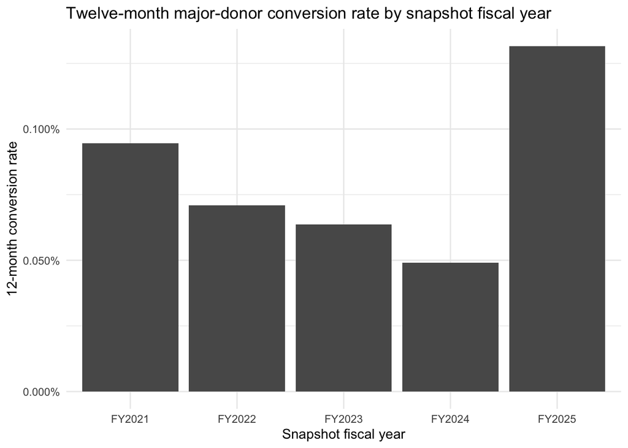

```r
ggplot(conversion_12m_summary,
       aes(x = snapshot_fiscal_year, y = conversion_rate)) +
  geom_col() +
  scale_y_continuous(labels = scales::label_percent(accuracy = 0.001)) +
  labs(
    title = "Twelve-month major-donor conversion rate by snapshot fiscal year",
    x = "Snapshot fiscal year",
    y = "12-month conversion rate"
  )
```

Twelve-month conversion is a rare outcome, so majority-class accuracy is not a useful measure of prospect-ranking quality.

### Three- and five-year major-donor conversion

A donor is a longer-term converter if they are not a major donor at the snapshot date but reach at least $1,200 in annual giving in any future fiscal year within the stated horizon. Complete 3-year follow-up is available for FY2021–FY2023, while complete 5-year follow-up is available only for FY2021. Therefore, the 3-year target can be explored across multiple years, but the 5-year result is descriptive rather than a robust model-validation sample.

```r
modeling_panel_with_year_number <- modeling_donor_fiscal_year_panel |>
  mutate(fiscal_year_number = as.integer(stringr::str_remove(fiscal_year, "FY")))

conversion_3y_panel <- modeling_panel_with_year_number |>
  filter(fiscal_year_number %in% 2021:2023, !is_major_donor) |>
  transmute(
    constituent_id,
    snapshot_fiscal_year = fiscal_year,
    snapshot_year_number = fiscal_year_number
  ) |>
  left_join(
    modeling_panel_with_year_number |>
      transmute(
        constituent_id,
        future_year_number = fiscal_year_number,
        future_annual_giving = annual_giving
      ),
    by = "constituent_id",
    relationship = "many-to-many"
  ) |>
  filter(
    future_year_number > snapshot_year_number,
    future_year_number <= snapshot_year_number + 3
  ) |>
  group_by(constituent_id, snapshot_fiscal_year, snapshot_year_number) |>
  summarise(
    converts_to_major_within_3y = any(future_annual_giving >= 1200),
    .groups = "drop"
  )

conversion_3y_summary <- conversion_3y_panel |>
  group_by(snapshot_fiscal_year) |>
  summarise(
    eligible_non_major_donors = n(),
    three_year_converters = sum(converts_to_major_within_3y),
    conversion_rate = mean(converts_to_major_within_3y),
    majority_class_baseline_accuracy = 1 - conversion_rate,
    .groups = "drop"
  ) |>
  arrange(snapshot_fiscal_year)

conversion_3y_overall_summary <- conversion_3y_panel |>
  summarise(
    eligible_non_major_donors = n(),
    three_year_converters = sum(converts_to_major_within_3y),
    conversion_rate = mean(converts_to_major_within_3y),
    majority_class_baseline_accuracy = 1 - conversion_rate
  )

conversion_5y_fy2021_summary <- modeling_panel_with_year_number |>
  filter(fiscal_year_number == 2021, !is_major_donor) |>
  transmute(constituent_id) |>
  left_join(
    modeling_panel_with_year_number |>
      filter(fiscal_year_number %in% 2022:2026) |>
      group_by(constituent_id) |>
      summarise(
        becomes_major_within_5y = any(annual_giving >= 1200),
        .groups = "drop"
      ),
    by = "constituent_id"
  ) |>
  summarise(
    eligible_non_major_donors_fy2021 = n(),
    five_year_converters = sum(becomes_major_within_5y, na.rm = TRUE),
    five_year_conversion_rate = five_year_converters /
      eligible_non_major_donors_fy2021
  )

knitr::kable(
  conversion_3y_summary |>
    mutate(
      across(c(eligible_non_major_donors, three_year_converters), scales::comma),
      across(c(conversion_rate, majority_class_baseline_accuracy),
             scales::percent, accuracy = 0.001)
    ),
  format = "pipe"
)
```

| snapshot_fiscal_year | eligible_non_major_donors | three_year_converters | conversion_rate | majority_class_baseline_accuracy |
| --- | --- | --- | --- | --- |
| FY2021 | 115,910 | 126 | 0.109% | 99.891% |
| FY2022 | 121,248 | 126 | 0.104% | 99.896% |
| FY2023 | 126,912 | 139 | 0.110% | 99.890% |

```r
knitr::kable(
  conversion_3y_overall_summary |>
    mutate(
      across(c(eligible_non_major_donors, three_year_converters), scales::comma),
      across(c(conversion_rate, majority_class_baseline_accuracy),
             scales::percent, accuracy = 0.001)
    ),
  format = "pipe"
)
```

| eligible_non_major_donors | three_year_converters | conversion_rate | majority_class_baseline_accuracy |
| --- | --- | --- | --- |
| 364,070 | 391 | 0.107% | 99.893% |

```r
knitr::kable(
  conversion_5y_fy2021_summary |>
    mutate(
      across(c(eligible_non_major_donors_fy2021, five_year_converters),
             scales::comma),
      five_year_conversion_rate = scales::percent(
        five_year_conversion_rate,
        accuracy = 0.001
      )
    ),
  format = "pipe"
)
```

| eligible_non_major_donors_fy2021 | five_year_converters | five_year_conversion_rate |
| --- | --- | --- |
| 115,910 | 202 | 0.174% |

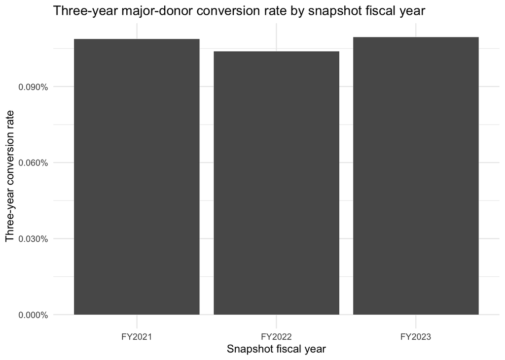

```r
ggplot(conversion_3y_summary,
       aes(x = snapshot_fiscal_year, y = conversion_rate)) +
  geom_col() +
  scale_y_continuous(labels = scales::label_percent(accuracy = 0.001)) +
  labs(
    title = "Three-year major-donor conversion rate by snapshot fiscal year",
    x = "Snapshot fiscal year",
    y = "Three-year conversion rate"
  )
```

## 8. Predictor EDA

```r
# End-of-data constituent snapshot fields are retained in the raw table for
# descriptive audit only; they are never eligible to enter predictor features.
predictor_blocklist <- c(
  "major_donor_class_pbs_utah",
  "annual_giving_group",
  "sustainer_pbs_utah",
  "lifetime_uof_u_fundraising",
  "previous_fy_uof_u_cash",
  "prospect_committed_giving_amount_uof_u"
)

stopifnot(all(predictor_blocklist %in% names(constituents_analysis)))
```

## Giving-history features

Every predictor must use information available on or before the snapshot fiscal-year end date. Future giving must never be used to predict conversion. These features use only individual-level legacy and current giving transactions dated by each donor-year snapshot.

```r
# Build RFM features efficiently from donor × fiscal-year summaries.
# All snapshots occur at the end of a PBS Utah fiscal year (June 30).

candidate_base <- conversion_12m_panel |>
  mutate(
    snapshot_year_number = as.integer(str_remove(snapshot_fiscal_year, "FY")),
    snapshot_end_date = as.Date(paste0(snapshot_year_number, "-06-30"))
  )

candidate_ids <- candidate_base |>
  distinct(constituent_id)

giving_history_transactions <- bind_rows(
  legacy_individual_history |>
    transmute(
      constituent_id,
      gift_date,
      amount = payment_amount,
      gift_fiscal_year = legacy_fiscal_year,
      source = "legacy"
    ),
  constituent_giving_transactions |>
    transmute(
      constituent_id,
      gift_date = gift_credit_date,
      amount,
      gift_fiscal_year = fiscal_year,
      source
    )
)

# Aggregate raw gift history once, rather than once for every donor-year row.
history_by_fiscal_year <- giving_history_transactions |>
  semi_join(candidate_ids, by = "constituent_id") |>
  filter(!is.na(gift_date), !is.na(amount)) |>
  mutate(
    gift_fiscal_year_number = as.integer(
      str_remove(gift_fiscal_year, "FY")
    )
  ) |>
  group_by(constituent_id, gift_fiscal_year_number) |>
  summarise(
    fiscal_year_giving = sum(amount, na.rm = TRUE),
    fiscal_year_gift_count = n(),
    fiscal_year_largest_gift = max(amount, na.rm = TRUE),
    first_gift_date_in_fy = min(gift_date),
    last_gift_date_in_fy = max(gift_date),
    legacy_giving_in_fy = any(source == "legacy"),
    .groups = "drop"
  )

# Build one feature table per snapshot year, then combine them.
rfm_runtime <- system.time({

  rfm_predictor_eda <- map_dfr(
    sort(unique(candidate_base$snapshot_year_number)),
    function(snapshot_year_number) {

      snapshot_candidates <- candidate_base |>
        filter(snapshot_year_number == .env$snapshot_year_number)

      # This table is already aggregated to donor × fiscal year.
      # It is much smaller than raw transaction history.
      history_to_snapshot <- history_by_fiscal_year |>
        filter(gift_fiscal_year_number <= .env$snapshot_year_number) |>
        group_by(constituent_id) |>
        summarise(
          giving_last_12m = sum(
            fiscal_year_giving[
              gift_fiscal_year_number == .env$snapshot_year_number
            ],
            na.rm = TRUE
          ),
          giving_last_36m = sum(
            fiscal_year_giving[
              gift_fiscal_year_number >= .env$snapshot_year_number - 2
            ],
            na.rm = TRUE
          ),
          giving_previous_two_years = sum(
            fiscal_year_giving[
              gift_fiscal_year_number >= .env$snapshot_year_number - 2 &
                gift_fiscal_year_number <= .env$snapshot_year_number - 1
            ],
            na.rm = TRUE
          ),
          years_given_last_5 = n_distinct(
            gift_fiscal_year_number[
              gift_fiscal_year_number >= .env$snapshot_year_number - 4 &
                gift_fiscal_year_number <= .env$snapshot_year_number
            ]
          ),
          giving_previous_12m = sum(
            fiscal_year_giving[
              gift_fiscal_year_number == .env$snapshot_year_number - 1
            ],
            na.rm = TRUE
          ),
          gift_count_last_12m = sum(
            fiscal_year_gift_count[
              gift_fiscal_year_number == .env$snapshot_year_number
            ],
            na.rm = TRUE
          ),
          lifetime_giving_to_date = sum(fiscal_year_giving, na.rm = TRUE),
          lifetime_gift_count = sum(fiscal_year_gift_count, na.rm = TRUE),
          largest_prior_gift = max(fiscal_year_largest_gift, na.rm = TRUE),
          first_known_gift_date = min(first_gift_date_in_fy),
          last_known_gift_date = max(last_gift_date_in_fy),
          had_legacy_giving_history = any(legacy_giving_in_fy),
          gave_in_snapshot_year = any(
            gift_fiscal_year_number == .env$snapshot_year_number
          ),
          .groups = "drop"
        )

      snapshot_candidates |>
        left_join(history_to_snapshot, by = "constituent_id") |>
        mutate(
          giving_last_12m = replace_na(giving_last_12m, 0),
          giving_last_36m = replace_na(giving_last_36m, 0),
          giving_previous_two_years = replace_na(giving_previous_two_years, 0),
          years_given_last_5 = replace_na(years_given_last_5, 0L),
          giving_previous_12m = replace_na(giving_previous_12m, 0),
          gift_count_last_12m = replace_na(gift_count_last_12m, 0L),
          lifetime_giving_to_date = replace_na(lifetime_giving_to_date, 0),
          lifetime_gift_count = replace_na(lifetime_gift_count, 0L),
          largest_prior_gift = replace_na(largest_prior_gift, 0),
          gave_in_snapshot_year = replace_na(gave_in_snapshot_year, FALSE),
          had_legacy_giving_history = replace_na(
            had_legacy_giving_history, FALSE
          ),
          months_since_last_gift = if_else(
            !is.na(last_known_gift_date),
            interval(last_known_gift_date, snapshot_end_date) %/% months(1),
            NA_integer_
          ),
          days_since_last_gift = if_else(
            !is.na(last_known_gift_date),
            as.integer(snapshot_end_date - last_known_gift_date),
            NA_integer_
          ),
          donor_tenure_years = if_else(
            !is.na(first_known_gift_date),
            time_length(
              interval(first_known_gift_date, snapshot_end_date),
              "years"
            ),
            NA_real_
          )
        ) |>
        select(-first_known_gift_date, -last_known_gift_date) |>
        mutate(giving_change_from_last_year =
          giving_last_12m - giving_previous_12m)
    }
  )
})

rfm_runtime
```

```
   user  system elapsed
 27.660   0.800  29.257
```

```r
# Validation: these must match the target panel exactly.
stopifnot(nrow(rfm_predictor_eda) == nrow(conversion_12m_panel))

rfm_duplicate_keys <- rfm_predictor_eda |>
  count(constituent_id, snapshot_fiscal_year) |>
  filter(n > 1)

stopifnot(nrow(rfm_duplicate_keys) == 0)
```

### Prior-year-giving ranking benchmark

Before fitting a model, prior-year giving is used as a transparent ranking benchmark. Each fiscal-year test cohort is ranked independently by `giving_last_12m`; the pooled row combines the three fiscal-year top-1,000 lists, preserving the same contact capacity within each cohort.

```r
rank_giving_benchmark <- function(data, cohort_label) {
  ranked <- data |>
    arrange(desc(giving_last_12m), constituent_id) |>
    mutate(rank_by_prior_year_giving = row_number())

  selected <- ranked |>
    filter(rank_by_prior_year_giving <= min(1000L, nrow(ranked)))

  tibble(
    test_cohort = cohort_label,
    donor_years = nrow(ranked),
    converters = sum(ranked$converts_to_major_next_fy),
    contact_capacity = nrow(selected),
    recall_at_1000 = if_else(
      sum(ranked$converts_to_major_next_fy) > 0,
      sum(selected$converts_to_major_next_fy) /
        sum(ranked$converts_to_major_next_fy),
      NA_real_
    ),
    precision_at_1000 = mean(selected$converts_to_major_next_fy),
    lift_at_1000 = precision_at_1000 /
      mean(ranked$converts_to_major_next_fy)
  )
}

benchmark_test_cohorts <- rfm_predictor_eda |>
  filter(snapshot_fiscal_year %in% paste0("FY", 2022:2024))

prior_year_giving_benchmark_by_cohort <- benchmark_test_cohorts |>
  group_by(snapshot_fiscal_year) |>
  group_modify(~ rank_giving_benchmark(.x, .y$snapshot_fiscal_year)) |>
  ungroup()

prior_year_giving_benchmark_pooled <- benchmark_test_cohorts |>
  group_by(snapshot_fiscal_year) |>
  group_modify(~ {
    ranked <- .x |>
      arrange(desc(giving_last_12m), constituent_id) |>
      mutate(rank_by_prior_year_giving = row_number())
    filter(ranked, rank_by_prior_year_giving <= min(1000L, nrow(ranked)))
  }) |>
  ungroup() |>
  summarise(
    test_cohort = "Pooled (top 1,000 per FY)",
    donor_years = nrow(benchmark_test_cohorts),
    converters = sum(benchmark_test_cohorts$converts_to_major_next_fy),
    contact_capacity = n(),
    recall_at_1000 = sum(converts_to_major_next_fy) /
      sum(benchmark_test_cohorts$converts_to_major_next_fy),
    precision_at_1000 = mean(converts_to_major_next_fy),
    lift_at_1000 = precision_at_1000 /
      mean(benchmark_test_cohorts$converts_to_major_next_fy)
  )

prior_year_giving_benchmark <- bind_rows(
  prior_year_giving_benchmark_by_cohort,
  prior_year_giving_benchmark_pooled
)

knitr::kable(
  prior_year_giving_benchmark |>
    mutate(
      across(c(donor_years, converters, contact_capacity), scales::comma),
      across(c(recall_at_1000, precision_at_1000),
             scales::percent, accuracy = 0.001),
      lift_at_1000 = round(lift_at_1000, 2)
    ),
  caption = "Primary-cohort prior-year-giving ranking benchmark"
)
```

Primary-cohort prior-year-giving ranking benchmark

| snapshot_fiscal_year | test_cohort | donor_years | converters | contact_capacity | recall_at_1000 | precision_at_1000 | lift_at_1000 |
| --- | --- | --- | --- | --- | --- | --- | --- |
| FY2022 | FY2022 | 31,017 | 22 | 1,000 | 50.000% | 1.100% | 15.51 |
| FY2023 | FY2023 | 33,021 | 21 | 1,000 | 57.143% | 1.200% | 18.87 |
| FY2024 | FY2024 | 32,571 | 16 | 1,000 | 68.750% | 1.100% | 22.39 |
| NA | Pooled (top 1,000 per FY) | 96,609 | 59 | 3,000 | 57.627% | 1.133% | 18.56 |

### Rolling ridge logistic-regression benchmark

The ridge model is evaluated only in the primary active never-major cohort. It uses pre-specified giving-history features, with all imputation, transformation parameters, scaling, and penalty tuning learned separately in each training window. No resampling, campaign, Passport, cultivation, officer, cohort-status, or constituent-snapshot fields are included.

```r
ridge_feature_names <- c(
  "giving_last_12m",
  "giving_previous_two_years",
  "years_given_last_5",
  "years_since_first_gift",
  "giving_change_from_last_year",
  "largest_prior_gift",
  "days_since_last_gift",
  "had_legacy_giving_history"
)

ridge_model_data <- rfm_predictor_eda |>
  transmute(
    constituent_id,
    snapshot_fiscal_year,
    converts_to_major_next_fy,
    giving_last_12m,
    giving_previous_two_years,
    years_given_last_5,
    years_since_first_gift = donor_tenure_years,
    giving_change_from_last_year,
    largest_prior_gift,
    days_since_last_gift,
    had_legacy_giving_history = as.numeric(had_legacy_giving_history)
  )

impute_and_transform_ridge_features <- function(data, training_medians) {
  features <- data |>
    select(all_of(ridge_feature_names)) |>
    mutate(across(everything(), as.numeric))

  for (feature_name in ridge_feature_names) {
    features[[feature_name]][is.na(features[[feature_name]])] <-
      training_medians[[feature_name]]
  }

  features |>
    mutate(
      giving_last_12m = log1p(giving_last_12m),
      giving_previous_two_years = log1p(giving_previous_two_years),
      years_since_first_gift = log1p(years_since_first_gift),
      giving_change_from_last_year = sign(giving_change_from_last_year) *
        log1p(abs(giving_change_from_last_year)),
      largest_prior_gift = log1p(largest_prior_gift),
      days_since_last_gift = log1p(days_since_last_gift)
    ) |>
    as.matrix()
}

fit_ridge_preprocessor <- function(training_data) {
  raw_features <- training_data |>
    select(all_of(ridge_feature_names)) |>
    mutate(across(everything(), as.numeric))

  training_medians <- vapply(
    raw_features,
    function(value) {
      median_value <- median(value, na.rm = TRUE)
      if_else(is.na(median_value), 0, median_value)
    },
    numeric(1)
  )

  transformed_training <- impute_and_transform_ridge_features(
    training_data,
    training_medians
  )
  training_means <- colMeans(transformed_training)
  training_sds <- apply(transformed_training, 2, sd)
  training_sds[is.na(training_sds) | training_sds == 0] <- 1

  list(
    medians = training_medians,
    means = training_means,
    sds = training_sds
  )
}

apply_ridge_preprocessor <- function(data, preprocessor) {
  transformed <- impute_and_transform_ridge_features(data, preprocessor$medians)
  sweep(
    sweep(transformed, 2, preprocessor$means, "-"),
    2,
    preprocessor$sds,
    "/"
  )
}

# Model C replaces continuous prior-year giving with fixed, interpretable
# bands. The $60-or-less band is the reference level. A $600 indicator is
# included only when that amount occurs in the corresponding training window.
make_threshold_feature_matrix <- function(
  data,
  training_medians,
  include_common_600
) {
  transformed <- impute_and_transform_ridge_features(data, training_medians)
  prior_year_giving <- as.numeric(data$giving_last_12m)
  prior_year_giving[is.na(prior_year_giving)] <-
    training_medians[["giving_last_12m"]]

  threshold_features <- cbind(
    transformed[, setdiff(colnames(transformed), "giving_last_12m"), drop = FALSE],
    giving_band_61_120 = as.numeric(
      prior_year_giving >= 61 & prior_year_giving <= 120
    ),
    giving_band_121_240 = as.numeric(
      prior_year_giving >= 121 & prior_year_giving <= 240
    ),
    giving_band_241_500 = as.numeric(
      prior_year_giving >= 241 & prior_year_giving <= 500
    ),
    giving_band_over_500 = as.numeric(prior_year_giving > 500)
  )

  if (include_common_600) {
    threshold_features <- cbind(
      threshold_features,
      giving_is_exactly_600 = as.numeric(dplyr::near(prior_year_giving, 600))
    )
  }

  threshold_features
}

fit_threshold_preprocessor <- function(training_data) {
  ridge_preprocessor <- fit_ridge_preprocessor(training_data)
  include_common_600 <- any(
    dplyr::near(training_data$giving_last_12m, 600),
    na.rm = TRUE
  )
  threshold_training <- make_threshold_feature_matrix(
    training_data,
    ridge_preprocessor$medians,
    include_common_600
  )
  threshold_means <- colMeans(threshold_training)
  threshold_sds <- apply(threshold_training, 2, sd)
  threshold_sds[is.na(threshold_sds) | threshold_sds == 0] <- 1

  list(
    medians = ridge_preprocessor$medians,
    include_common_600 = include_common_600,
    means = threshold_means,
    sds = threshold_sds
  )
}

apply_threshold_preprocessor <- function(data, preprocessor) {
  threshold_features <- make_threshold_feature_matrix(
    data,
    preprocessor$medians,
    preprocessor$include_common_600
  )
  sweep(
    sweep(threshold_features, 2, preprocessor$means, "-"),
    2,
    preprocessor$sds,
    "/"
  )
}

fit_tree_preprocessor <- function(training_data) {
  raw_features <- training_data |>
    select(all_of(ridge_feature_names)) |>
    mutate(across(everything(), as.numeric))

  vapply(
    raw_features,
    function(value) {
      median_value <- median(value, na.rm = TRUE)
      if_else(is.na(median_value), 0, median_value)
    },
    numeric(1)
  )
}

apply_tree_preprocessor <- function(data, training_medians) {
  features <- data |>
    select(all_of(ridge_feature_names)) |>
    mutate(across(everything(), as.numeric))

  for (feature_name in ridge_feature_names) {
    features[[feature_name]][is.na(features[[feature_name]])] <-
      training_medians[[feature_name]]
  }

  features
}

average_precision <- function(outcome, score) {
  ranked <- tibble(outcome = as.integer(outcome), score = score) |>
    arrange(desc(score)) |>
    mutate(
      rank = row_number(),
      precision_at_rank = cumsum(outcome) / rank
    )

  if (sum(ranked$outcome) == 0) {
    return(NA_real_)
  }

  mean(ranked$precision_at_rank[ranked$outcome == 1])
}

rolling_windows <- tibble(
  test_fiscal_year = paste0("FY", 2022:2024),
  training_fiscal_years = list(
    "FY2021",
    paste0("FY", 2021:2022),
    paste0("FY", 2021:2023)
  )
)

ridge_fit_results <- map(
  seq_len(nrow(rolling_windows)),
  function(window_index) {
    test_year <- rolling_windows$test_fiscal_year[[window_index]]
    train_years <- rolling_windows$training_fiscal_years[[window_index]]
```

```r
    training_data <- ridge_model_data |>
      filter(snapshot_fiscal_year %in% train_years)
    test_data <- ridge_model_data |>
      filter(snapshot_fiscal_year == test_year)

    preprocessor <- fit_ridge_preprocessor(training_data)
    x_train <- apply_ridge_preprocessor(training_data, preprocessor)
    x_test <- apply_ridge_preprocessor(test_data, preprocessor)

    set.seed(20261021 + window_index)
    ridge_cv <- glmnet::cv.glmnet(
      x = x_train,
      y = as.integer(training_data$converts_to_major_next_fy),
      family = "binomial",
      alpha = 0,
      nfolds = 5,
      type.measure = "deviance",
      standardize = FALSE
    )

    threshold_preprocessor <- fit_threshold_preprocessor(training_data)
    x_threshold_train <- apply_threshold_preprocessor(
      training_data,
      threshold_preprocessor
    )
    x_threshold_test <- apply_threshold_preprocessor(
      test_data,
      threshold_preprocessor
    )

    set.seed(20261121 + window_index)
    threshold_ridge_cv <- glmnet::cv.glmnet(
      x = x_threshold_train,
      y = as.integer(training_data$converts_to_major_next_fy),
      family = "binomial",
      alpha = 0,
      nfolds = 5,
      type.measure = "deviance",
      standardize = FALSE
    )

    tree_medians <- fit_tree_preprocessor(training_data)
    tree_training_data <- apply_tree_preprocessor(training_data, tree_medians) |>
      mutate(
        converts_to_major_next_fy = factor(
          training_data$converts_to_major_next_fy,
          levels = c(FALSE, TRUE)
        )
      )
    tree_test_data <- apply_tree_preprocessor(test_data, tree_medians)

    shallow_tree <- rpart::rpart(
      converts_to_major_next_fy ~ .,
      data = tree_training_data,
      method = "class",
      control = rpart::rpart.control(
        maxdepth = 2,
        minbucket = 200,
        minsplit = 400,
        cp = 0,
        xval = 0
      )
    )

    firth_training_data <- as.data.frame(x_train) |>
      mutate(
        converts_to_major_next_fy = as.integer(
          training_data$converts_to_major_next_fy
        )
      )
    firth_test_data <- as.data.frame(x_test)
    firth_fit <- logistf::logistf(
      converts_to_major_next_fy ~ .,
      data = firth_training_data,
      pl = FALSE
    )

    list(
      scored = test_data |>
        transmute(
          constituent_id,
          snapshot_fiscal_year,
          converts_to_major_next_fy,
          benchmark_score = giving_last_12m,
          ridge_probability = as.numeric(predict(
            ridge_cv,
            newx = x_test,
            s = "lambda.min",
            type = "response"
          )),
          threshold_ridge_probability = as.numeric(predict(
            threshold_ridge_cv,
            newx = x_threshold_test,
            s = "lambda.min",
            type = "response"
          )),
          shallow_tree_probability = predict(
            shallow_tree,
            newdata = tree_test_data,
            type = "prob"
          )[, "TRUE"],
          firth_probability = as.numeric(predict(
            firth_fit,
            newdata = firth_test_data,
            type = "response"
          ))
        ),
      training_audit = tibble(
        test_fiscal_year = test_year,
        training_fiscal_years = paste(train_years, collapse = ", "),
        training_donor_years = nrow(training_data),
        training_events = sum(training_data$converts_to_major_next_fy),
        continuous_ridge_lambda = ridge_cv$lambda.min,
        threshold_ridge_lambda = threshold_ridge_cv$lambda.min,
        common_600_indicator_included = threshold_preprocessor$include_common_600,
        shallow_tree_terminal_nodes = sum(shallow_tree$frame$var == "<leaf>")
      ),
      ridge_cv = ridge_cv,
      threshold_ridge_cv = threshold_ridge_cv,
      shallow_tree = shallow_tree,
      firth_fit = firth_fit
    )
  }
)

ridge_scored_tests <- bind_rows(map(ridge_fit_results, "scored"))
ridge_training_audit <- bind_rows(map(ridge_fit_results, "training_audit"))

ranking_metrics <- function(scored_data, score_column, model_name) {
  ranked <- scored_data |>
    arrange(snapshot_fiscal_year, desc(.data[[score_column]]), constituent_id) |>
    group_by(snapshot_fiscal_year) |>
    mutate(rank_within_test = row_number()) |>
    ungroup()

  by_cohort <- ranked |>
    group_by(snapshot_fiscal_year) |>
    summarise(
      model = model_name,
      donor_years = n(),
      converters = sum(converts_to_major_next_fy),
      contact_capacity = sum(rank_within_test <= 1000),
      recall_at_1000 = sum(
        converts_to_major_next_fy[rank_within_test <= 1000]
      ) / converters,
      precision_at_1000 = mean(
        converts_to_major_next_fy[rank_within_test <= 1000]
      ),
      lift_at_1000 = precision_at_1000 /
        mean(converts_to_major_next_fy),
      average_precision = average_precision(
        converts_to_major_next_fy,
        .data[[score_column]]
      ),
      .groups = "drop"
    ) |>
    mutate(test_cohort = snapshot_fiscal_year)

  pooled_selected <- ranked |>
    filter(rank_within_test <= 1000)

  pooled <- tibble(
    snapshot_fiscal_year = NA_character_,
    model = model_name,
    donor_years = nrow(ranked),
    converters = sum(ranked$converts_to_major_next_fy),
    contact_capacity = nrow(pooled_selected),
    recall_at_1000 = sum(pooled_selected$converts_to_major_next_fy) /
      sum(ranked$converts_to_major_next_fy),
    precision_at_1000 = mean(pooled_selected$converts_to_major_next_fy),
    lift_at_1000 = precision_at_1000 /
      mean(ranked$converts_to_major_next_fy),
    average_precision = average_precision(
      ranked$converts_to_major_next_fy,
      ranked[[score_column]]
    ),
    test_cohort = "Pooled (top 1,000 per FY)"
  )

  bind_rows(by_cohort, pooled) |>
    select(test_cohort, model, donor_years, converters, contact_capacity,
           recall_at_1000, precision_at_1000, lift_at_1000, average_precision)
}

ridge_model_comparison <- bind_rows(
  ranking_metrics(
    ridge_scored_tests,
    "benchmark_score",
    "Prior-year giving benchmark"
  ),
  ranking_metrics(ridge_scored_tests, "ridge_probability", "Continuous ridge"),
  ranking_metrics(
    ridge_scored_tests,
    "threshold_ridge_probability",
    "Threshold-aware ridge"
  ),
  ranking_metrics(
    ridge_scored_tests,
    "shallow_tree_probability",
    "Shallow tree"
  ),
  ranking_metrics(
    ridge_scored_tests,
    "firth_probability",
    "Firth logistic"
  )
)
```

```r
ridge_calibration_check <- ridge_scored_tests |>
  group_by(snapshot_fiscal_year) |>
  summarise(
    mean_predicted_probability = mean(ridge_probability),
    observed_conversion_rate = mean(converts_to_major_next_fy),
    calibration_in_the_large = mean_predicted_probability -
      observed_conversion_rate,
    brier_score = mean(
      (ridge_probability - as.numeric(converts_to_major_next_fy))^2
    ),
    .groups = "drop"
  ) |>
  bind_rows(
    ridge_scored_tests |>
      summarise(
        snapshot_fiscal_year = "Pooled",
        mean_predicted_probability = mean(ridge_probability),
        observed_conversion_rate = mean(converts_to_major_next_fy),
        calibration_in_the_large = mean_predicted_probability -
          observed_conversion_rate,
        brier_score = mean(
          (ridge_probability - as.numeric(converts_to_major_next_fy))^2
        )
      )
  )

firth_calibration_check <- ridge_scored_tests |>
  group_by(snapshot_fiscal_year) |>
  summarise(
    mean_predicted_probability = mean(firth_probability),
    observed_conversion_rate = mean(converts_to_major_next_fy),
    calibration_in_the_large = mean_predicted_probability -
      observed_conversion_rate,
    brier_score = mean(
      (firth_probability - as.numeric(converts_to_major_next_fy))^2
    ),
    .groups = "drop"
  ) |>
  bind_rows(
    ridge_scored_tests |>
      summarise(
        snapshot_fiscal_year = "Pooled",
        mean_predicted_probability = mean(firth_probability),
        observed_conversion_rate = mean(converts_to_major_next_fy),
        calibration_in_the_large = mean_predicted_probability -
          observed_conversion_rate,
        brier_score = mean(
          (firth_probability - as.numeric(converts_to_major_next_fy))^2
        )
      )
  )

knitr::kable(
  ridge_training_audit |>
    mutate(
      training_donor_years = scales::comma(training_donor_years),
      training_events = scales::comma(training_events),
      across(c(continuous_ridge_lambda, threshold_ridge_lambda), signif, 3)
    ),
  caption = "Ridge rolling-window training audit"
)
```

Ridge rolling-window training audit

| test_fiscal_year | training_fiscal_years | training_donor_years | training_events | continuous_ridge_lambda | threshold_ridge_lambda | common_600_indicator_included | shallow_tree_terminal_nodes |
| --- | --- | --- | --- | --- | --- | --- | --- |
| FY2022 | FY2021 | 30,678 | 29 | 0.000145 | 0.001510 | TRUE | 1 |
| FY2023 | FY2021, FY2022 | 61,695 | 51 | 0.000111 | 0.000480 | TRUE | 1 |
| FY2024 | FY2021, FY2022, FY2023 | 94,716 | 72 | 0.000105 | 0.000426 | TRUE | 1 |

```r
knitr::kable(
  ridge_model_comparison |>
    mutate(
      across(c(donor_years, converters, contact_capacity), scales::comma),
      across(c(recall_at_1000, precision_at_1000, average_precision),
             scales::percent, accuracy = 0.001),
      lift_at_1000 = round(lift_at_1000, 2)
    ),
  caption = "Primary-cohort benchmark versus ridge logistic regression"
)
```

Primary-cohort benchmark versus ridge logistic regression

| test_cohort | model | donor_years | converters | contact_capacity | recall_at_1000 | precision_at_1000 | lift_at_1000 | average_precision |
| --- | --- | --- | --- | --- | --- | --- | --- | --- |
| FY2022 | Prior-year giving benchmark | 31,017 | 22 | 1,000 | 50.000% | 1.100% | 15.51 | 2.209% |
| FY2023 | Prior-year giving benchmark | 33,021 | 21 | 1,000 | 57.143% | 1.200% | 18.87 | 2.565% |
| FY2024 | Prior-year giving benchmark | 32,571 | 16 | 1,000 | 68.750% | 1.100% | 22.39 | 4.970% |
| Pooled (top 1,000 per FY) | Prior-year giving benchmark | 96,609 | 59 | 3,000 | 57.627% | 1.133% | 18.56 | 2.547% |
| FY2022 | Continuous ridge | 31,017 | 22 | 1,000 | 54.545% | 1.200% | 16.92 | 2.723% |
| FY2023 | Continuous ridge | 33,021 | 21 | 1,000 | 61.905% | 1.300% | 20.44 | 5.167% |
| FY2024 | Continuous ridge | 32,571 | 16 | 1,000 | 68.750% | 1.100% | 22.39 | 3.357% |
| Pooled (top 1,000 per FY) | Continuous ridge | 96,609 | 59 | 3,000 | 61.017% | 1.200% | 19.65 | 2.733% |
| FY2022 | Threshold-aware ridge | 31,017 | 22 | 1,000 | 50.000% | 1.100% | 15.51 | 2.215% |
| FY2023 | Threshold-aware ridge | 33,021 | 21 | 1,000 | 66.667% | 1.400% | 22.01 | 2.724% |
| FY2024 | Threshold-aware ridge | 32,571 | 16 | 1,000 | 68.750% | 1.100% | 22.39 | 4.953% |
| Pooled (top 1,000 per FY) | Threshold-aware ridge | 96,609 | 59 | 3,000 | 61.017% | 1.200% | 19.65 | 2.620% |
| FY2022 | Shallow tree | 31,017 | 22 | 1,000 | 4.545% | 0.100% | 1.41 | 0.097% |
| FY2023 | Shallow tree | 33,021 | 21 | 1,000 | 0.000% | 0.000% | 0.00 | 0.078% |
| FY2024 | Shallow tree | 32,571 | 16 | 1,000 | 0.000% | 0.000% | 0.00 | 0.090% |
| Pooled (top 1,000 per FY) | Shallow tree | 96,609 | 59 | 3,000 | 1.695% | 0.033% | 0.55 | 0.081% |
| FY2022 | Firth logistic | 31,017 | 22 | 1,000 | 54.545% | 1.200% | 16.92 | 2.415% |
| FY2023 | Firth logistic | 33,021 | 21 | 1,000 | 61.905% | 1.300% | 20.44 | 4.358% |
| FY2024 | Firth logistic | 32,571 | 16 | 1,000 | 68.750% | 1.100% | 22.39 | 3.241% |
| Pooled (top 1,000 per FY) | Firth logistic | 96,609 | 59 | 3,000 | 61.017% | 1.200% | 19.65 | 2.407% |

```r
knitr::kable(
  ridge_calibration_check |>
    mutate(
      across(c(mean_predicted_probability, observed_conversion_rate,
               calibration_in_the_large), scales::percent, accuracy = 0.001),
      brier_score = signif(brier_score, 3)
    ),
  caption = "Ridge probability calibration check"
)
```

Ridge probability calibration check

| snapshot_fiscal_year | mean_predicted_probability | observed_conversion_rate | calibration_in_the_large | brier_score |
| --- | --- | --- | --- | --- |
| FY2022 | 0.092% | 0.071% | 0.021% | 0.000699 |
| FY2023 | 0.077% | 0.064% | 0.013% | 0.000628 |
| FY2024 | 0.071% | 0.049% | 0.022% | 0.000484 |
| Pooled | 0.079% | 0.061% | 0.018% | 0.000602 |

```r
knitr::kable(
  firth_calibration_check |>
    mutate(
      across(c(mean_predicted_probability, observed_conversion_rate,
               calibration_in_the_large), scales::percent, accuracy = 0.001),
      brier_score = signif(brier_score, 3)
    ),
  caption = "Firth logistic probability calibration check"
)
```

Firth logistic probability calibration check

| snapshot_fiscal_year | mean_predicted_probability | observed_conversion_rate | calibration_in_the_large | brier_score |
| --- | --- | --- | --- | --- |
| FY2022 | 0.115% | 0.071% | 0.044% | 0.000714 |
| FY2023 | 0.085% | 0.064% | 0.021% | 0.000629 |
| FY2024 | 0.074% | 0.049% | 0.024% | 0.000483 |
| Pooled | 0.091% | 0.061% | 0.030% | 0.000607 |

### Paired bootstrap uncertainty: ridge versus prior-year giving

Uncertainty is estimated from the existing FY2022–FY2024 held-out predictions. Bootstrap resampling is clustered across all test years so that repeated donor appearances remain together. If reciprocal spouse pairs were present, the existing household ID would be the cluster; this release has no supported reciprocal pairs, so the analysis uses donor-level clusters.

```r
bootstrap_scored_tests <- ridge_scored_tests |>
  left_join(
    household_map |>
      select(constituent_id, household_id, supported_reciprocal_link),
    by = "constituent_id"
  ) |>
  mutate(
    bootstrap_cluster_id = coalesce(household_id, constituent_id),
    bootstrap_cluster_type = if_else(
      any(supported_reciprocal_link),
      "Household clusters for supported reciprocal spouse pairs",
      "Donor clusters; no supported reciprocal spouse pairs"
    )
  )

bootstrap_cluster_ids <- bootstrap_scored_tests |>
  distinct(bootstrap_cluster_id) |>
  arrange(bootstrap_cluster_id) |>
  pull(bootstrap_cluster_id)

bootstrap_scored_tests <- bootstrap_scored_tests |>
  mutate(
    bootstrap_cluster_index = match(
      bootstrap_cluster_id,
      bootstrap_cluster_ids
    )
  )

bootstrap_records_by_year <- split(
  bootstrap_scored_tests,
  bootstrap_scored_tests$snapshot_fiscal_year
)

top_k_selection <- function(data, cluster_weights, score_column, top_k = 1000L) {
  record_weights <- cluster_weights[data$bootstrap_cluster_index]
  ranked_order <- order(-data[[score_column]], data$constituent_id)
  ranked_weights <- record_weights[ranked_order]
  ranked_outcomes <- as.integer(
    data$converts_to_major_next_fy[ranked_order]
  )
  contact_capacity <- min(top_k, sum(ranked_weights))
  selected_copies <- pmax(
    pmin(
      ranked_weights,
      contact_capacity - c(0, head(cumsum(ranked_weights), -1))
    ),
    0
  )

  c(
    donor_years = sum(ranked_weights),
    converters = sum(ranked_weights * ranked_outcomes),
    contact_capacity = contact_capacity,
    selected_converters = sum(selected_copies * ranked_outcomes)
  )
}

paired_bootstrap_draw <- function() {
  cluster_weights <- tabulate(
    sample.int(
      length(bootstrap_cluster_ids),
      size = length(bootstrap_cluster_ids),
      replace = TRUE
    ),
    nbins = length(bootstrap_cluster_ids)
  )

  benchmark_counts <- Reduce(
    `+`,
    lapply(
      bootstrap_records_by_year,
      top_k_selection,
      cluster_weights = cluster_weights,
      score_column = "benchmark_score"
    )
  )
  ridge_counts <- Reduce(
    `+`,
    lapply(
      bootstrap_records_by_year,
      top_k_selection,
      cluster_weights = cluster_weights,
      score_column = "ridge_probability"
    )
  )
  threshold_ridge_counts <- Reduce(
    `+`,
    lapply(
      bootstrap_records_by_year,
      top_k_selection,
      cluster_weights = cluster_weights,
      score_column = "threshold_ridge_probability"
    )
  )
  shallow_tree_counts <- Reduce(
    `+`,
    lapply(
      bootstrap_records_by_year,
      top_k_selection,
      cluster_weights = cluster_weights,
      score_column = "shallow_tree_probability"
    )
  )
  firth_counts <- Reduce(
    `+`,
    lapply(
      bootstrap_records_by_year,
      top_k_selection,
      cluster_weights = cluster_weights,
      score_column = "firth_probability"
    )
  )

  base_rate <- benchmark_counts[["converters"]] /
    benchmark_counts[["donor_years"]]
  benchmark_recall <- benchmark_counts[["selected_converters"]] /
    benchmark_counts[["converters"]]
  benchmark_precision <- benchmark_counts[["selected_converters"]] /
    benchmark_counts[["contact_capacity"]]

  model_differences <- function(model_counts, model_name) {
    model_recall <- model_counts[["selected_converters"]] /
      model_counts[["converters"]]
    model_precision <- model_counts[["selected_converters"]] /
      model_counts[["contact_capacity"]]

    c(
      setNames(
        model_recall - benchmark_recall,
        paste0(model_name, "__recall_at_1000_difference")
      ),
      setNames(
        model_precision - benchmark_precision,
        paste0(model_name, "__precision_at_1000_difference")
      ),
      setNames(
        model_precision / base_rate - benchmark_precision / base_rate,
        paste0(model_name, "__lift_at_1000_difference")
      )
    )
  }

  c(
    model_differences(ridge_counts, "Continuous ridge"),
    model_differences(threshold_ridge_counts, "Threshold-aware ridge"),
    model_differences(shallow_tree_counts, "Shallow tree"),
    model_differences(firth_counts, "Firth logistic")
  )
}

set.seed(20261022)
paired_bootstrap_differences <- t(replicate(2000, paired_bootstrap_draw())) |>
  as_tibble()

paired_bootstrap_summary <- paired_bootstrap_differences |>
  pivot_longer(
    everything(),
    names_to = c("model", "metric"),
    names_sep = "__",
    values_to = "ridge_minus_benchmark"
  ) |>
  group_by(model, metric) |>
  summarise(
    paired_difference = mean(ridge_minus_benchmark),
    interval_low = quantile(ridge_minus_benchmark, 0.025),
    interval_high = quantile(ridge_minus_benchmark, 0.975),
    proportion_ridge_better = mean(ridge_minus_benchmark > 0),
    .groups = "drop"
  ) |>
  mutate(
    metric = recode(
      metric,
      recall_at_1000_difference = "Recall@1,000",
      precision_at_1000_difference = "Precision@1,000",
      lift_at_1000_difference = "Lift@1,000"
    )
  )

# Coefficients are from the largest pre-FY2024 rolling training window. Inputs
# were standardized using that window's training data, so signs are comparable;
# magnitudes remain descriptive because predictors are correlated.
ridge_coefficient_matrix <- as.matrix(coef(
  ridge_fit_results[[3]]$ridge_cv,
  s = "lambda.min"
))

ridge_feature_directions <- tibble(
  feature = rownames(ridge_coefficient_matrix),
  standardized_coefficient = as.numeric(ridge_coefficient_matrix[, 1])
) |>
  filter(feature != "(Intercept)") |>
  mutate(
    direction = if_else(
      standardized_coefficient > 0,
      "Higher predicted conversion",
      "Lower predicted conversion"
    )
  ) |>
  arrange(desc(abs(standardized_coefficient)))

firth_feature_directions <- tibble(
  feature = names(ridge_fit_results[[3]]$firth_fit$coefficients),
  standardized_coefficient = as.numeric(
    ridge_fit_results[[3]]$firth_fit$coefficients
  )
) |>
  filter(feature != "(Intercept)") |>
  mutate(
    direction = if_else(
      standardized_coefficient > 0,
      "Higher predicted conversion",
      "Lower predicted conversion"
    )
  ) |>
  arrange(desc(abs(standardized_coefficient)))

largest_window_tree <- ridge_fit_results[[3]]$shallow_tree
shallow_tree_split_rules <- if (is.null(largest_window_tree$splits)) {
  tibble(rule = "No split selected")
} else {
  tibble(
    feature = rownames(largest_window_tree$splits),
    split_point = largest_window_tree$splits[, "index"]
  ) |>
    mutate(
      rule = paste0(feature, " < ", scales::comma(split_point, accuracy = 0.01))
    ) |>
    select(rule)
}

knitr::kable(
  tibble(
    clustering = unique(bootstrap_scored_tests$bootstrap_cluster_type),
    bootstrap_draws = 2000,
    held_out_fiscal_years = "FY2022–FY2024",
    annual_contact_capacity = "1,000 per fiscal year"
  ),
  caption = "Paired bootstrap design"
)
```

Paired bootstrap design

| clustering | bootstrap_draws | held_out_fiscal_years | annual_contact_capacity |
| --- | --- | --- | --- |
| Donor clusters; no supported reciprocal spouse pairs | 2000 | FY2022–FY2024 | 1,000 per fiscal year |

```r
knitr::kable(
  paired_bootstrap_summary |>
    mutate(
      paired_difference = if_else(
        metric == "Lift@1,000",
        paste0(round(paired_difference, 2), "×"),
        scales::percent(paired_difference, accuracy = 0.001)
      ),
      interval_low = if_else(
        metric == "Lift@1,000",
        paste0(round(interval_low, 2), "×"),
        scales::percent(interval_low, accuracy = 0.001)
      ),
      interval_high = if_else(
        metric == "Lift@1,000",
        paste0(round(interval_high, 2), "×"),
        scales::percent(interval_high, accuracy = 0.001)
      ),
      proportion_ridge_better = scales::percent(
        proportion_ridge_better,
        accuracy = 0.001
      )
    ),
  caption = "Paired bootstrap: each regularized model minus prior-year-giving benchmark"
)
```

Paired bootstrap: each regularized model minus prior-year-giving benchmark

| model | metric | paired_difference | interval_low | interval_high | proportion_ridge_better |
| --- | --- | --- | --- | --- | --- |
| Continuous ridge | Lift@1,000 | 1.04× | -1.98× | 4.29× | 66.750% |
| Continuous ridge | Precision@1,000 | 0.063% | -0.133% | 0.267% | 66.750% |
| Continuous ridge | Recall@1,000 | 3.230% | -6.154% | 13.333% | 66.750% |
| Firth logistic | Lift@1,000 | 0.87× | -2.11× | 4.12× | 62.850% |
| Firth logistic | Precision@1,000 | 0.053% | -0.133% | 0.267% | 62.850% |
| Firth logistic | Recall@1,000 | 2.694% | -6.560% | 12.766% | 62.850% |
| Shallow tree | Lift@1,000 | -18.36× | -22.5× | -14.11× | 0.000% |
| Shallow tree | Precision@1,000 | -1.117% | -1.533% | -0.767% | 0.000% |
| Shallow tree | Recall@1,000 | -57.010% | -69.812% | -43.750% | 0.000% |
| Threshold-aware ridge | Lift@1,000 | 0.71× | -2.04× | 3.58× | 61.450% |
| Threshold-aware ridge | Precision@1,000 | 0.043% | -0.133% | 0.200% | 61.450% |
| Threshold-aware ridge | Recall@1,000 | 2.192% | -6.349% | 11.111% | 61.450% |

```r
knitr::kable(
  ridge_feature_directions |>
    mutate(standardized_coefficient = round(standardized_coefficient, 3)),
  caption = "Ridge coefficient directions (largest rolling training window)"
)
```

Ridge coefficient directions (largest rolling training window)

| feature | standardized_coefficient | direction |
| --- | --- | --- |
| largest_prior_gift | 1.105 | Higher predicted conversion |
| giving_last_12m | 0.731 | Higher predicted conversion |
| giving_change_from_last_year | 0.560 | Higher predicted conversion |
| giving_previous_two_years | 0.309 | Higher predicted conversion |
| years_given_last_5 | 0.156 | Higher predicted conversion |
| days_since_last_gift | -0.139 | Lower predicted conversion |
| years_since_first_gift | -0.125 | Lower predicted conversion |
| had_legacy_giving_history | 0.007 | Higher predicted conversion |

```r
knitr::kable(
  firth_feature_directions |>
    mutate(standardized_coefficient = round(standardized_coefficient, 3)),
  caption = "Firth coefficient directions (associative, not causal)"
)
```

Firth coefficient directions (associative, not causal)

| feature | standardized_coefficient | direction |
| --- | --- | --- |
| largest_prior_gift | 1.469 | Higher predicted conversion |
| giving_last_12m | 0.694 | Higher predicted conversion |
| giving_change_from_last_year | 0.566 | Higher predicted conversion |
| giving_previous_two_years | 0.332 | Higher predicted conversion |
| years_since_first_gift | -0.219 | Lower predicted conversion |
| years_given_last_5 | 0.151 | Higher predicted conversion |
| days_since_last_gift | -0.138 | Lower predicted conversion |
| had_legacy_giving_history | 0.001 | Higher predicted conversion |

```r
knitr::kable(
  shallow_tree_split_rules,
  caption = "Shallow-tree split rules (FY2021–FY2023 training window)"
)
```

Shallow-tree split rules (FY2021–FY2023 training window)

| rule |
| --- |
| No split selected |

```r
# Compare distributions by outcome; these are associations, not causal effects.
predictor_comparison <- rfm_predictor_eda |>
  group_by(converts_to_major_next_fy) |>
  summarise(across(c(giving_last_12m, giving_last_36m, lifetime_giving_to_date, largest_prior_gift, months_since_last_gift, donor_tenure_years),
    list(median = ~median(.x, na.rm = TRUE), iqr = ~IQR(.x, na.rm = TRUE)), .names = "{.col}__{.fn}"), .groups = "drop") |>
  pivot_longer(-converts_to_major_next_fy, names_to = c("feature", "statistic"), names_sep = "__") |>
  pivot_wider(names_from = statistic, values_from = value) |>
  mutate(converts_to_major_next_fy = if_else(converts_to_major_next_fy, "Future converter", "Did not convert"))
knitr::kable(predictor_comparison, digits = 2, caption = "Giving-history features by 12-month conversion status")
```

Giving-history features by 12-month conversion status

| converts_to_major_next_fy | feature | median | iqr |
| --- | --- | --- | --- |
| Did not convert | giving_last_12m | 60.00 | 98.00 |
| Did not convert | giving_last_36m | 180.00 | 228.00 |
| Did not convert | lifetime_giving_to_date | 250.00 | 456.00 |
| Did not convert | largest_prior_gift | 45.00 | 80.00 |
| Did not convert | months_since_last_gift | 1.00 | 2.00 |
| Did not convert | donor_tenure_years | 4.94 | 13.74 |
| Future converter | giving_last_12m | 250.00 | 355.00 |
| Future converter | giving_last_36m | 673.00 | 796.00 |
| Future converter | lifetime_giving_to_date | 1060.00 | 1187.50 |
| Future converter | largest_prior_gift | 250.00 | 372.50 |
| Future converter | months_since_last_gift | 1.00 | 4.00 |
| Future converter | donor_tenure_years | 11.24 | 15.33 |

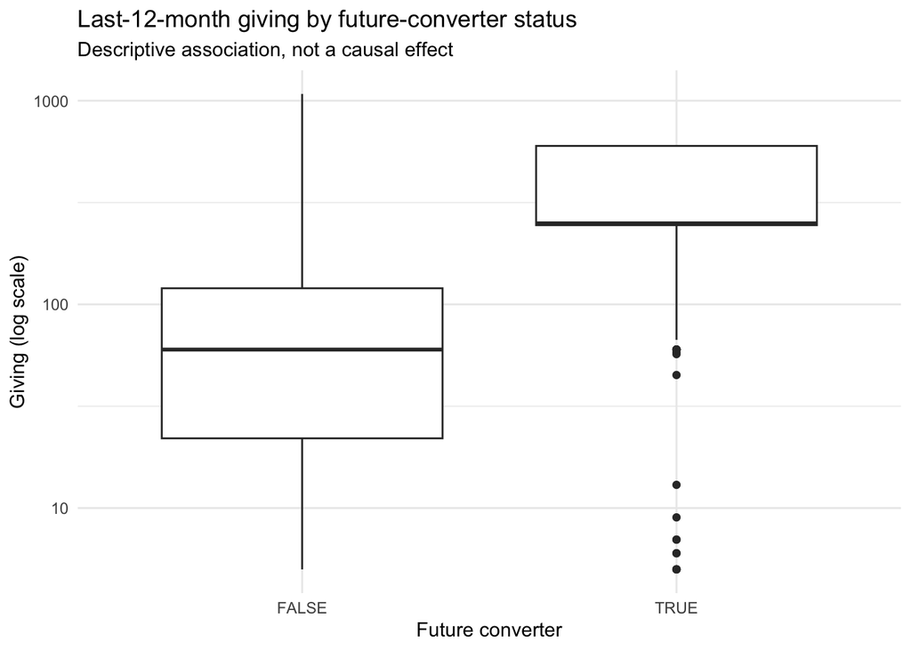

```r
# Visual comparisons are descriptive associations, not causal effects.
ggplot(filter(rfm_predictor_eda, giving_last_12m > 0), aes(factor(converts_to_major_next_fy), giving_last_12m)) +
  geom_boxplot() + scale_y_log10() + labs(title = "Last-12-month giving by future-converter status", subtitle = "Descriptive association, not a causal effect", x = "Future converter", y = "Giving (log scale)")
```

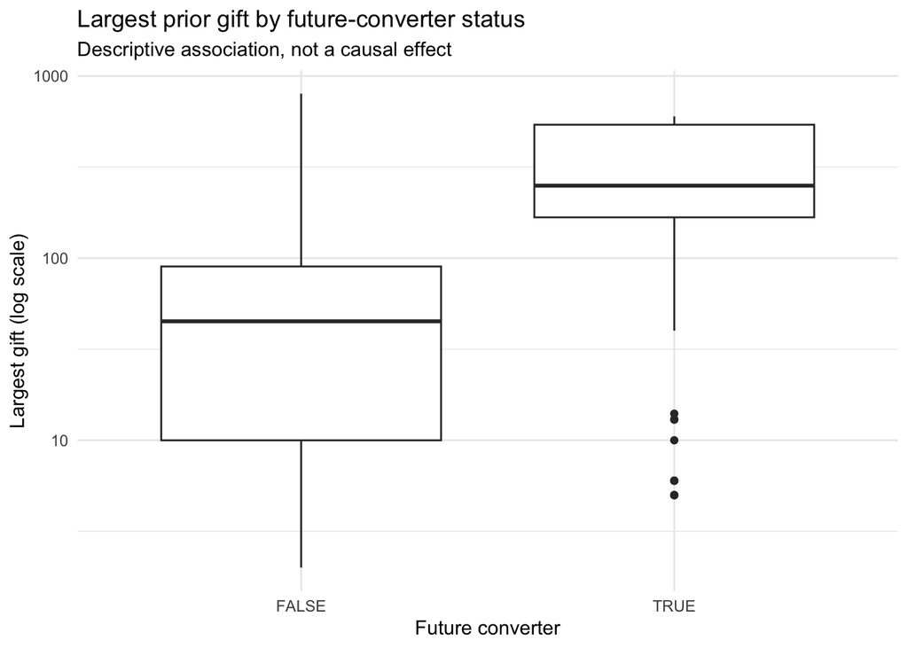

```r
ggplot(filter(rfm_predictor_eda, largest_prior_gift > 0), aes(factor(converts_to_major_next_fy), largest_prior_gift)) +
  geom_boxplot() + scale_y_log10() + labs(title = "Largest prior gift by future-converter status", subtitle = "Descriptive association, not a causal effect", x = "Future converter", y = "Largest gift (log scale)")
```

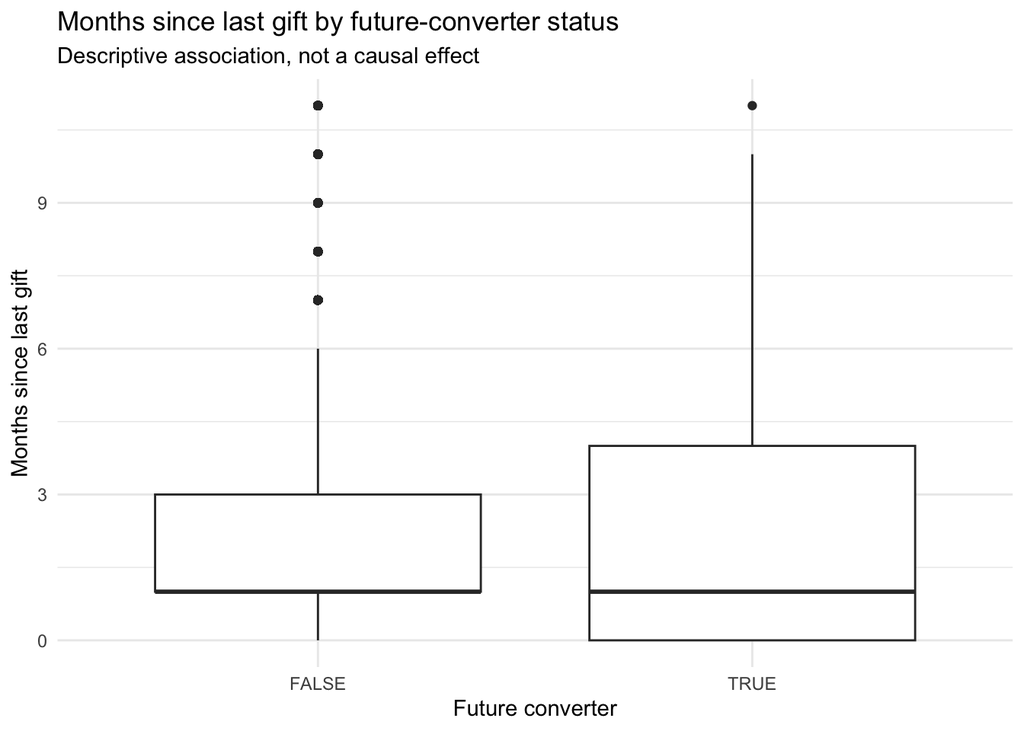

```r
ggplot(rfm_predictor_eda, aes(factor(converts_to_major_next_fy), months_since_last_gift)) +
  geom_boxplot(na.rm = TRUE) + labs(title = "Months since last gift by future-converter status", subtitle = "Descriptive association, not a causal effect", x = "Future converter", y = "Months since last gift")
```

## Campaign-history features

Campaign history may reflect both donor engagement and staff targeting. The summaries below are therefore descriptive associations, not evidence that a campaign caused a future major gift.

```r
# Build campaign features efficiently from constituent × fiscal-year summaries.
# Do not join raw campaign records to the donor-year target panel.

candidate_base <- conversion_12m_panel |>
  mutate(
    snapshot_year_number = as.integer(str_remove(snapshot_fiscal_year, "FY")),
    snapshot_end_date = as.Date(paste0(snapshot_year_number, "-06-30"))
  )

candidate_ids <- candidate_base |>
  distinct(constituent_id)

# Keep only columns needed for campaign features and only relevant constituents.
campaign_history_small <- campaign_members_analysis |>
  select(constituent_id, marketing_code, campaign_start_date, responded_date) |>
  semi_join(candidate_ids, by = "constituent_id") |>
  left_join(
    campaign_codes_analysis |>
      select(marketing_code, communication_method),
    by = "marketing_code"
  ) |>
  mutate(
    campaign_start_date = as.Date(campaign_start_date),
    responded_date = as.Date(responded_date),
    campaign_fy_number = fiscal_year_from_date(campaign_start_date),
    response_fy_number = fiscal_year_from_date(responded_date)
  )

# Aggregate solicitations once by constituent and fiscal year.
campaign_by_fiscal_year <- campaign_history_small |>
  filter(!is.na(campaign_start_date)) |>
  arrange(constituent_id, campaign_start_date, marketing_code) |>
  group_by(constituent_id, campaign_fy_number) |>
  summarise(
    fiscal_year_solicitations = n(),
    communication_method_in_fy = last(
      communication_method[!is.na(communication_method)],
      default = NA_character_
    ),
    .groups = "drop"
  )

# Aggregate responses once by response fiscal year.
# Response timing, not campaign-start timing, determines whether it was known.
responses_by_fiscal_year <- campaign_history_small |>
  filter(!is.na(responded_date)) |>
  group_by(constituent_id, response_fy_number) |>
  summarise(
    fiscal_year_responses = n(),
    .groups = "drop"
  )

campaign_runtime <- system.time({

  campaign_features <- map_dfr(
    sort(unique(candidate_base$snapshot_year_number)),
    function(snapshot_year_number) {

      candidates <- candidate_base |>
        filter(snapshot_year_number == .env$snapshot_year_number)

      solicitation_summary <- campaign_by_fiscal_year |>
        filter(campaign_fy_number <= .env$snapshot_year_number) |>
        group_by(constituent_id) |>
        summarise(
          solicitations_last_12m = sum(
            fiscal_year_solicitations[
              campaign_fy_number == .env$snapshot_year_number
            ],
            na.rm = TRUE
          ),
          solicitations_last_36m = sum(
            fiscal_year_solicitations[
              campaign_fy_number >= .env$snapshot_year_number - 2
            ],
            na.rm = TRUE
          ),
          lifetime_solicitations = sum(fiscal_year_solicitations, na.rm = TRUE),
          most_recent_communication_method = last(
            communication_method_in_fy[
              !is.na(communication_method_in_fy)
            ],
            default = NA_character_
          ),
          .groups = "drop"
        )

      response_summary <- responses_by_fiscal_year |>
        filter(response_fy_number <= .env$snapshot_year_number) |>
        group_by(constituent_id) |>
        summarise(
          campaign_responses_last_12m = sum(
            fiscal_year_responses[
              response_fy_number == .env$snapshot_year_number
            ],
            na.rm = TRUE
          ),
          lifetime_campaign_responses = sum(
            fiscal_year_responses,
            na.rm = TRUE
          ),
          .groups = "drop"
        )

      candidates |>
        left_join(solicitation_summary, by = "constituent_id") |>
        left_join(response_summary, by = "constituent_id") |>
        mutate(
          solicitations_last_12m = replace_na(
            solicitations_last_12m, 0L
          ),
          solicitations_last_36m = replace_na(
            solicitations_last_36m, 0L
          ),
          lifetime_solicitations = replace_na(
            lifetime_solicitations, 0L
          ),
          campaign_responses_last_12m = replace_na(
            campaign_responses_last_12m, 0L
          ),
          lifetime_campaign_responses = replace_na(
            lifetime_campaign_responses, 0L
          ),
          lifetime_campaign_response_rate = if_else(
            lifetime_solicitations > 0,
            lifetime_campaign_responses / lifetime_solicitations,
            NA_real_
          ),
          responded_to_any_campaign_last_12m =
            campaign_responses_last_12m > 0
        )
    }
  )
})

campaign_runtime
```

```
   user  system elapsed
  8.361   0.142   8.541
```

```r
# Validation checks
stopifnot(nrow(campaign_features) == nrow(conversion_12m_panel))

campaign_duplicate_keys <- campaign_features |>
  count(constituent_id, snapshot_fiscal_year) |>
  filter(n > 1)

stopifnot(nrow(campaign_duplicate_keys) == 0)
```

```r
# Compare campaign-history features by future conversion status.
campaign_comparison <- campaign_features |>
  group_by(converts_to_major_next_fy) |>
  summarise(
    median_solicitations_last_12m = median(solicitations_last_12m, na.rm = TRUE),
    pct_responding_last_12m = mean(responded_to_any_campaign_last_12m, na.rm = TRUE),
    median_campaign_responses_to_date = median(lifetime_campaign_responses, na.rm = TRUE),
    median_lifetime_response_rate = median(lifetime_campaign_response_rate, na.rm = TRUE),
    .groups = "drop"
  ) |>
  mutate(across(c(pct_responding_last_12m, median_lifetime_response_rate), ~scales::percent(.x, accuracy = 0.1)),
         converts_to_major_next_fy = if_else(converts_to_major_next_fy, "Future converter", "Did not convert"))
knitr::kable(campaign_comparison, caption = "Campaign history by 12-month conversion status")
```

Campaign history by 12-month conversion status

| converts_to_major_next_fy | median_solicitations_last_12m | pct_responding_last_12m | median_campaign_responses_to_date | median_lifetime_response_rate |
| --- | --- | --- | --- | --- |
| Did not convert | 6 | 30.3% | 1 | 1.5% |
| Future converter | 8 | 45.0% | 1 | 2.9% |

```r
# Pool uncommon or missing recent communication methods into Other/Unknown.
method_counts <- campaign_features |>
  count(most_recent_communication_method, name = "donor_years")
common_methods <- method_counts |>
  filter(donor_years >= 50) |>
  pull(most_recent_communication_method)

campaign_features <- campaign_features |>
  mutate(recent_method_group = if_else(!is.na(most_recent_communication_method) &
    most_recent_communication_method %in% common_methods,
    most_recent_communication_method, "Other/Unknown"))

method_conversion_raw <- campaign_features |>
  group_by(recent_method_group) |>
  summarise(donor_years = n(), converters = sum(converts_to_major_next_fy),
            conversion_rate = mean(converts_to_major_next_fy), .groups = "drop") |>
  arrange(desc(conversion_rate))
method_conversion <- method_conversion_raw |>
  mutate(conversion_rate = scales::percent(conversion_rate, accuracy = 0.1))
knitr::kable(method_conversion, caption = "Conversion by most-recent solicitation method")
```

Conversion by most-recent solicitation method

| recent_method_group | donor_years | converters | conversion_rate |
| --- | --- | --- | --- |
| Email | 963 | 2 | 0.2% |
| Legacy | 77729 | 78 | 0.1% |
| Digital | 16970 | 15 | 0.1% |
| Other/Unknown | 9539 | 6 | 0.1% |
| Miscellaneous | 50512 | 29 | 0.1% |
| Mail | 3539 | 1 | 0.0% |
| In-Person | 109 | 0 | 0.0% |
| Phone | 100 | 0 | 0.0% |
| Third Party | 507 | 0 | 0.0% |

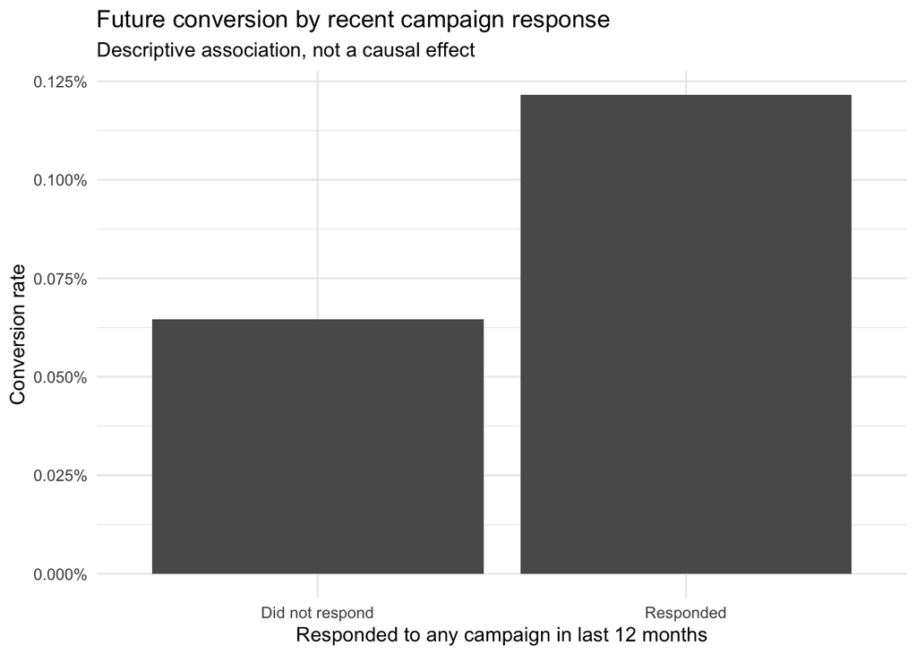

```r
response_conversion <- campaign_features |>
  group_by(responded_to_any_campaign_last_12m) |>
  summarise(
    conversion_rate = mean(as.numeric(converts_to_major_next_fy)),
    donor_years = n(),
    .groups = "drop"
  )

ggplot(
  response_conversion,
  aes(
    x = factor(
      responded_to_any_campaign_last_12m,
      labels = c("Did not respond", "Responded")
    ),
    y = conversion_rate
  )
) +
  geom_col() +
  scale_y_continuous(labels = scales::percent) +
  labs(
    title = "Future conversion by recent campaign response",
    subtitle = "Descriptive association, not a causal effect",
    x = "Responded to any campaign in last 12 months",
    y = "Conversion rate"
  )
```

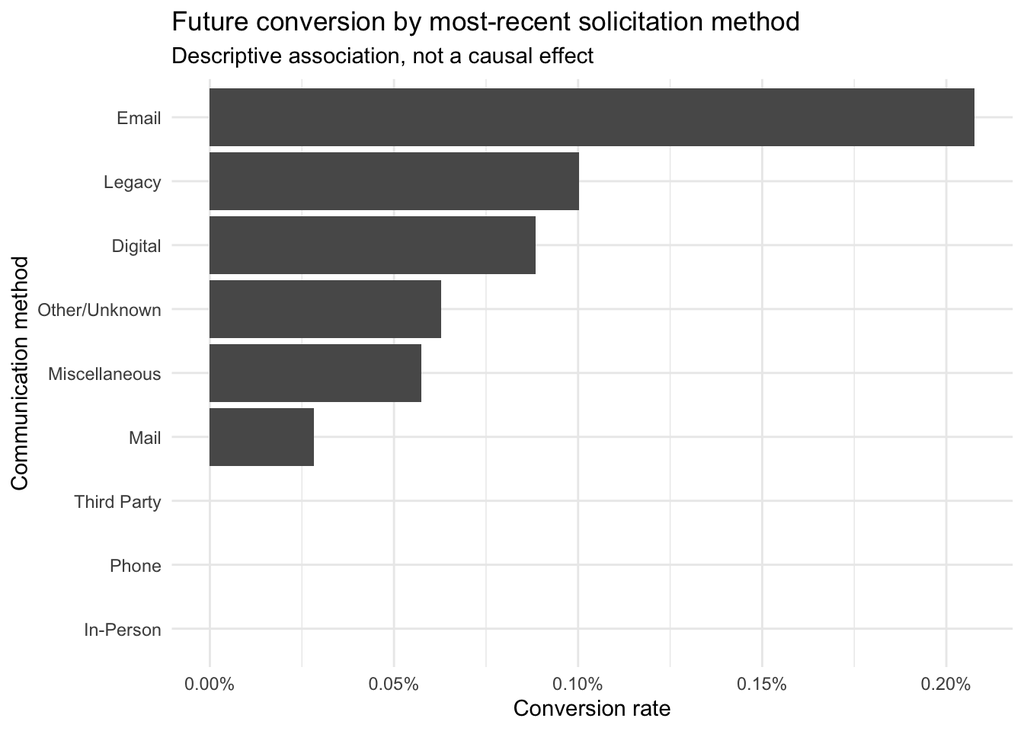

```r
ggplot(method_conversion_raw, aes(reorder(recent_method_group, conversion_rate), conversion_rate)) +
  geom_col() + coord_flip() + scale_y_continuous(labels = scales::percent) +
  labs(title = "Future conversion by most-recent solicitation method",
       subtitle = "Descriptive association, not a causal effect",
       x = "Communication method", y = "Conversion rate")
```

## Passport viewing features

Passport data is available only for linked or consenting viewing records. A missing Passport record does not mean that a donor did not engage with PBS Utah, so coverage is reported separately from viewing behavior. These results assess incremental association rather than complete audience engagement.

```r
# Build Passport features efficiently from constituent × fiscal-year summaries.
# Missing Passport data remains missing; it is not converted to zero viewing.

candidate_base <- conversion_12m_panel |>
  mutate(
    snapshot_year_number = as.integer(str_remove(snapshot_fiscal_year, "FY"))
  )

candidate_ids <- candidate_base |>
  distinct(constituent_id)

passport_by_fiscal_year <- passport_viewing_analysis |>
  semi_join(candidate_ids, by = "constituent_id") |>
  mutate(
    passport_fiscal_year_number = as.integer(
      str_remove(as.character(fiscal_year), "FY")
    )
  ) |>
  group_by(constituent_id, passport_fiscal_year_number) |>
  summarise(
    fiscal_year_titles_viewed = sum(titles_viewed, na.rm = TRUE),
    fiscal_year_distinct_genres = n_distinct(genre),
    fiscal_year_mean_percent_watched = mean(
      mean_percent_watched,
      na.rm = TRUE
    ),
    .groups = "drop"
  )

passport_runtime <- system.time({

  passport_features <- map_dfr(
    sort(unique(candidate_base$snapshot_year_number)),
    function(snapshot_year_number) {

      candidates <- candidate_base |>
        filter(snapshot_year_number == .env$snapshot_year_number)

      passport_summary <- passport_by_fiscal_year |>
        filter(passport_fiscal_year_number <= .env$snapshot_year_number) |>
        group_by(constituent_id) |>
        summarise(
          passport_record_available = TRUE,
          titles_viewed_last_12m = if_else(
            any(passport_fiscal_year_number == .env$snapshot_year_number),
            sum(
              fiscal_year_titles_viewed[
                passport_fiscal_year_number == .env$snapshot_year_number
              ],
              na.rm = TRUE
            ),
            NA_real_
          ),
          titles_viewed_last_36m = if_else(
            any(
              passport_fiscal_year_number >=
                .env$snapshot_year_number - 2
            ),
            sum(
              fiscal_year_titles_viewed[
                passport_fiscal_year_number >=
                  .env$snapshot_year_number - 2
              ],
              na.rm = TRUE
            ),
            NA_real_
          ),
          distinct_genres_last_12m = if_else(
            any(passport_fiscal_year_number == .env$snapshot_year_number),
            sum(
              fiscal_year_distinct_genres[
                passport_fiscal_year_number == .env$snapshot_year_number
              ],
              na.rm = TRUE
            ),
            NA_integer_
          ),
          mean_percent_watched_last_12m = if_else(
            any(passport_fiscal_year_number == .env$snapshot_year_number),
            mean(
              fiscal_year_mean_percent_watched[
                passport_fiscal_year_number == .env$snapshot_year_number
              ],
              na.rm = TRUE
            ),
            NA_real_
          ),
          passport_viewing_recency_years = .env$snapshot_year_number -
            max(passport_fiscal_year_number),
          .groups = "drop"
        )

      candidates |>
        left_join(passport_summary, by = "constituent_id") |>
        mutate(
          passport_record_available = replace_na(
            passport_record_available,
            FALSE
          )
        )
    }
  )
})

passport_runtime
```

```
   user  system elapsed
 48.156   0.639  49.402
```

```r
# Validation checks
stopifnot(nrow(passport_features) == nrow(conversion_12m_panel))

passport_duplicate_keys <- passport_features |>
  count(constituent_id, snapshot_fiscal_year) |>
  filter(n > 1)

stopifnot(nrow(passport_duplicate_keys) == 0)
```

```r
passport_coverage <- passport_features |>
  group_by(converts_to_major_next_fy) |>
  summarise(donor_year_records = n(), records_with_passport = sum(passport_record_available),
            passport_coverage = records_with_passport / donor_year_records,
            conversion_rate = mean(converts_to_major_next_fy), .groups = "drop") |>
  mutate(across(c(passport_coverage, conversion_rate), ~scales::percent(.x, accuracy = 0.1)))
knitr::kable(passport_coverage, caption = "Passport coverage and conversion status")
```

Passport coverage and conversion status

| converts_to_major_next_fy | donor_year_records | records_with_passport | passport_coverage | conversion_rate |
| --- | --- | --- | --- | --- |
| FALSE | 159837 | 115904 | 72.5% | 0.0% |
| TRUE | 131 | 97 | 74.0% | 100.0% |

```r
passport_behavior <- passport_features |>
  filter(passport_record_available) |>
  group_by(converts_to_major_next_fy) |>
  summarise(
    median_titles_viewed_last_12m = median(titles_viewed_last_12m, na.rm = TRUE),
    median_distinct_genres_last_12m = median(distinct_genres_last_12m, na.rm = TRUE),
    median_mean_percent_watched = median(mean_percent_watched_last_12m, na.rm = TRUE),
    median_viewing_recency_years = median(passport_viewing_recency_years, na.rm = TRUE),
    .groups = "drop"
  ) |>
  mutate(converts_to_major_next_fy = if_else(converts_to_major_next_fy, "Future converter", "Did not convert"))
knitr::kable(passport_behavior, digits = 2, caption = "Passport behavior among records with viewing data")
```

Passport behavior among records with viewing data

| converts_to_major_next_fy | median_titles_viewed_last_12m | median_distinct_genres_last_12m | median_mean_percent_watched | median_viewing_recency_years |
| --- | --- | --- | --- | --- |
| Did not convert | 27 | 4 | 0.71 | 0 |
| Future converter | 41 | 4 | 0.72 | 0 |

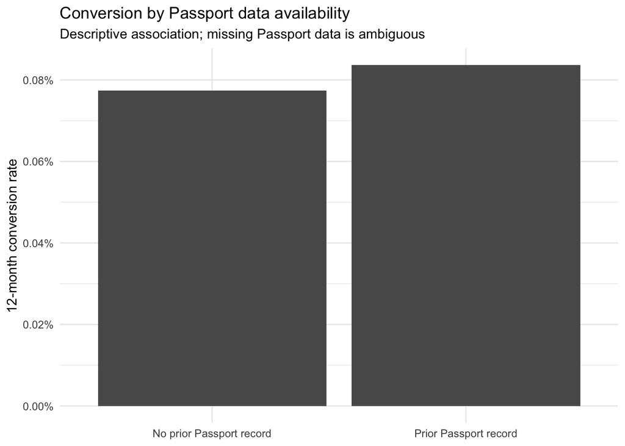

```r
passport_conversion <- passport_features |>
  group_by(passport_record_available) |>
  summarise(
    conversion_rate = mean(as.numeric(converts_to_major_next_fy)),
    donor_years = n(),
    converters = sum(converts_to_major_next_fy),
    .groups = "drop"
  )

ggplot(
  passport_conversion,
  aes(
    x = factor(
      passport_record_available,
      labels = c("No prior Passport record", "Prior Passport record")
    ),
    y = conversion_rate
  )
) +
  geom_col() +
  scale_y_continuous(labels = scales::percent) +
  labs(
    title = "Conversion by Passport data availability",
    subtitle = "Descriptive association; missing Passport data is ambiguous",
    x = NULL,
    y = "12-month conversion rate"
  )
```

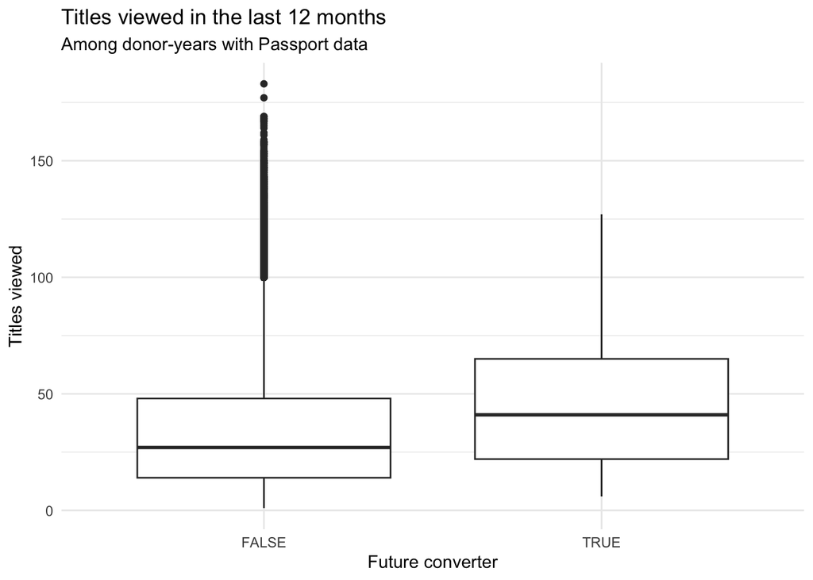

```r
ggplot(filter(passport_features, passport_record_available),
       aes(x = factor(converts_to_major_next_fy), y = titles_viewed_last_12m)) +
  geom_boxplot(na.rm = TRUE) + scale_y_continuous(labels = scales::comma) +
  labs(title = "Titles viewed in the last 12 months", subtitle = "Among donor-years with Passport data", x = "Future converter", y = "Titles viewed")
```

## Joined donor-year feature table

All transactional sources were first aggregated to the same donor-year grain before joining. This prevents raw payment, campaign, or Passport rows from creating duplicate model records.

```r
# Join only donor-year summaries to the conversion outcome table.
base_rows <- nrow(conversion_12m_panel)
eda_feature_table <- conversion_12m_panel |>
  left_join(rfm_predictor_eda |>
    select(constituent_id, snapshot_fiscal_year, giving_last_12m,
           giving_last_36m, gift_count_last_12m, lifetime_giving_to_date,
           lifetime_gift_count, largest_prior_gift, months_since_last_gift,
           donor_tenure_years, gave_in_snapshot_year, had_legacy_giving_history),
    by = c("constituent_id", "snapshot_fiscal_year")) |>
  left_join(campaign_features |>
    select(constituent_id, snapshot_fiscal_year, solicitations_last_12m,
           solicitations_last_36m, campaign_responses_last_12m,
           lifetime_campaign_responses, lifetime_campaign_response_rate,
           responded_to_any_campaign_last_12m),
    by = c("constituent_id", "snapshot_fiscal_year")) |>
  left_join(passport_features |>
    select(constituent_id, snapshot_fiscal_year, passport_record_available,
           titles_viewed_last_12m, titles_viewed_last_36m,
           distinct_genres_last_12m, mean_percent_watched_last_12m,
           passport_viewing_recency_years),
    by = c("constituent_id", "snapshot_fiscal_year"))

stopifnot(!any(predictor_blocklist %in% names(eda_feature_table)))

join_checks <- tibble(
  check = c("Rows before joins", "Rows after joins", "Unique donor-year keys", "Outcome fields retained"),
  value = c(base_rows, nrow(eda_feature_table),
            nrow(distinct(eda_feature_table, constituent_id, snapshot_fiscal_year)),
            sum(names(eda_feature_table) == "converts_to_major_next_fy"))
)
knitr::kable(join_checks, caption = "Joined feature-table checks")
```

Joined feature-table checks

| check | value |
| --- | --- |
| Rows before joins | 159968 |
| Rows after joins | 159968 |
| Unique donor-year keys | 159968 |
| Outcome fields retained | 1 |

```r
rfm_cols <- c("giving_last_12m", "giving_last_36m", "lifetime_giving_to_date", "largest_prior_gift")
campaign_cols <- c("solicitations_last_12m", "campaign_responses_last_12m", "lifetime_campaign_responses")
passport_cols <- c("titles_viewed_last_12m", "distinct_genres_last_12m", "mean_percent_watched_last_12m")

feature_coverage <- tibble(
  feature_group = c("RFM", "Campaign", "Passport"),
  usable_records = c(sum(rowSums(!is.na(eda_feature_table[rfm_cols])) > 0),
                     sum(rowSums(!is.na(eda_feature_table[campaign_cols])) > 0),
                     sum(rowSums(!is.na(eda_feature_table[passport_cols])) > 0)),
  coverage = usable_records / nrow(eda_feature_table),
  missingness_treatment = c("Zeros represent no observed giving; recency fields may be missing.",
                            "No recorded campaign activity remains missing.",
                            "Missing coverage is distinct from zero viewing; do not recode as zero.")
) |>
  mutate(coverage = scales::percent(coverage, accuracy = 0.1))
knitr::kable(feature_coverage, caption = "Candidate predictor coverage")
```

Candidate predictor coverage

| feature_group | usable_records | coverage | missingness_treatment |
| --- | --- | --- | --- |
| RFM | 159968 | 100.0% | Zeros represent no observed giving; recency fields may be missing. |
| Campaign | 159968 | 100.0% | No recorded campaign activity remains missing. |
| Passport | 80645 | 50.4% | Missing coverage is distinct from zero viewing; do not recode as zero. |

```r
candidate_cols <- c(rfm_cols, "gift_count_last_12m", "months_since_last_gift", "donor_tenure_years",
                    campaign_cols, "lifetime_campaign_response_rate", "responded_to_any_campaign_last_12m",
                    passport_cols, "titles_viewed_last_36m", "passport_viewing_recency_years")
missingness_table <- eda_feature_table |>
  summarise(across(all_of(candidate_cols), ~sum(is.na(.x)))) |>
  pivot_longer(everything(), names_to = "feature", values_to = "missing_records") |>
  mutate(pct_missing = missing_records / nrow(eda_feature_table)) |>
  arrange(desc(pct_missing)) |>
  mutate(pct_missing = scales::percent(pct_missing, accuracy = 0.1))
knitr::kable(missingness_table, caption = "Missingness in candidate predictors")
```

Missingness in candidate predictors

| feature | missing_records | pct_missing |
| --- | --- | --- |
| titles_viewed_last_12m | 79323 | 49.6% |
| distinct_genres_last_12m | 79323 | 49.6% |
| mean_percent_watched_last_12m | 79323 | 49.6% |
| titles_viewed_last_36m | 46793 | 29.3% |
| passport_viewing_recency_years | 43967 | 27.5% |
| lifetime_campaign_response_rate | 9539 | 6.0% |
| giving_last_12m | 0 | 0.0% |
| giving_last_36m | 0 | 0.0% |
| lifetime_giving_to_date | 0 | 0.0% |
| largest_prior_gift | 0 | 0.0% |
| gift_count_last_12m | 0 | 0.0% |
| months_since_last_gift | 0 | 0.0% |
| donor_tenure_years | 0 | 0.0% |
| solicitations_last_12m | 0 | 0.0% |
| campaign_responses_last_12m | 0 | 0.0% |
| lifetime_campaign_responses | 0 | 0.0% |
| responded_to_any_campaign_last_12m | 0 | 0.0% |

## Predictor EDA findings

The table below consolidates evidence from the donor-year feature summaries. Coverage and conversion-rate differences are computed from the available data; they are preliminary associations and should not be interpreted as causal effects.

```r
# Create a compact evidence summary from the completed Section 8 results.
# The outcome is always converts_to_major_next_fy.
# Campaign response and Passport availability are the comparison groups.

# ----- RFM: compare continuous feature medians by outcome -----

rfm_medians <- rfm_predictor_eda |>
  group_by(converts_to_major_next_fy) |>
  summarise(
    median_giving_last_12m = median(giving_last_12m, na.rm = TRUE),
    median_months_since_last_gift = median(
      months_since_last_gift,
      na.rm = TRUE
    ),
    .groups = "drop"
  )

rfm_non_converter <- rfm_medians |>
  filter(!converts_to_major_next_fy)

rfm_converter <- rfm_medians |>
  filter(converts_to_major_next_fy)

rfm_comparison_text <- paste0(
  "Median last-12-month giving: ",
  scales::dollar(rfm_converter$median_giving_last_12m),
  " vs ",
  scales::dollar(rfm_non_converter$median_giving_last_12m),
  "; median recency: ",
  round(rfm_converter$median_months_since_last_gift, 0),
  " vs ",
  round(rfm_non_converter$median_months_since_last_gift, 0),
  " months"
)

# ----- Campaign: compare conversion rate for responders vs non-responders -----

campaign_rates <- campaign_features |>
  group_by(responded_to_any_campaign_last_12m) |>
  summarise(
    donor_years = n(),
    converters = sum(converts_to_major_next_fy),
    conversion_rate = mean(as.numeric(converts_to_major_next_fy)),
    median_solicitations_last_12m = median(
      solicitations_last_12m,
      na.rm = TRUE
    ),
    .groups = "drop"
  )

campaign_no_response <- campaign_rates |>
  filter(!responded_to_any_campaign_last_12m)

campaign_response <- campaign_rates |>
  filter(responded_to_any_campaign_last_12m)

campaign_difference_pp <- 100 * (
  campaign_response$conversion_rate -
    campaign_no_response$conversion_rate
)

campaign_comparison_text <- paste0(
  "Responded: ",
  scales::percent(campaign_response$conversion_rate, accuracy = 0.001),
  " conversion vs ",
  scales::percent(campaign_no_response$conversion_rate, accuracy = 0.001),
  " without a response"
)

# ----- Passport: compare conversion rate with vs without a prior record -----

passport_rates <- passport_features |>
  group_by(passport_record_available) |>
  summarise(
    donor_years = n(),
    converters = sum(converts_to_major_next_fy),
    conversion_rate = mean(as.numeric(converts_to_major_next_fy)),
    .groups = "drop"
  )

passport_no_record <- passport_rates |>
  filter(!passport_record_available)

passport_record <- passport_rates |>
  filter(passport_record_available)

passport_difference_pp <- 100 * (
  passport_record$conversion_rate -
    passport_no_record$conversion_rate
)

passport_behavior <- passport_features |>
  filter(!is.na(titles_viewed_last_12m)) |>
  group_by(converts_to_major_next_fy) |>
  summarise(
    median_titles_viewed = median(titles_viewed_last_12m, na.rm = TRUE),
    .groups = "drop"
  )

passport_non_converter <- passport_behavior |>
  filter(!converts_to_major_next_fy)

passport_converter <- passport_behavior |>
  filter(converts_to_major_next_fy)

passport_coverage <- mean(
  passport_features$passport_record_available,
  na.rm = TRUE
)

passport_comparison_text <- paste0(
  "Prior Passport record: ",
  scales::percent(passport_record$conversion_rate, accuracy = 0.001),
  " conversion vs ",
  scales::percent(passport_no_record$conversion_rate, accuracy = 0.001),
  "; among current viewers, median titles: ",
  round(passport_converter$median_titles_viewed, 0),
  " vs ",
  round(passport_non_converter$median_titles_viewed, 0)
)

# ----- Final evidence table -----

evidence_table <- tibble(
  feature_group = c(
    "Giving-history / RFM",
    "Campaign history",
    "Passport viewing"
  ),
  coverage = c(
    "100.0%",
    "100.0% feature availability",
    scales::percent(passport_coverage, accuracy = 0.1)
  ),
  converter_comparison = c(
    rfm_comparison_text,
    campaign_comparison_text,
    passport_comparison_text
  ),
  conversion_rate_difference = c(
    "—",
    paste0(round(campaign_difference_pp, 3), " percentage points"),
    paste0(round(passport_difference_pp, 3), " percentage points")
  ),
  preliminary_assessment = c(
    "Strongest preliminary signals; test in time-based models.",
    "Promising, but staff-targeting bias is possible.",
    "Potentially useful, but coverage is limited and missingness is ambiguous."
  )
)

knitr::kable(
  evidence_table,
  caption = "Evidence summary for candidate feature groups"
)
```

Evidence summary for candidate feature groups

| feature_group | coverage | converter_comparison | conversion_rate_difference | preliminary_assessment |
| --- | --- | --- | --- | --- |
| Giving-history / RFM | 100.0% | Median last-12-month giving: $250 vs $60; median recency: 1 vs 1 months | — | Strongest preliminary signals; test in time-based models. |
| Campaign history | 100.0% feature availability | Responded: 0.122% conversion vs 0.065% without a response | 0.057 percentage points | Promising, but staff-targeting bias is possible. |
| Passport viewing | 72.5% | Prior Passport record: 0.084% conversion vs 0.077%; among current viewers, median titles: 41 vs 27 | 0.006 percentage points | Potentially useful, but coverage is limited and missingness is ambiguous. |

## Controlled Ridge feature-set comparison

This comparison retains the existing giving-history-only Continuous Ridge unchanged and evaluates three expanded specifications on the same primary active never-major donor-year rows and FY2022–FY2024 rolling tests. To make availability unambiguous, campaign and Passport features below use only fiscal years *strictly before* the snapshot fiscal year. Thus, snapshot-year campaign solicitations/responses and Passport behavior are excluded, even when an aggregate source table contains them. This conservative choice avoids using a record whose exact within-year availability is uncertain.

```r
# Strictly pre-snapshot campaign history. Counts of no prior activity are real
# zeros, because the campaign-member source has complete constituent links.
strict_campaign_features <- map_dfr(
  sort(unique(ridge_model_data$snapshot_fiscal_year)),
  function(snapshot_fiscal_year) {
    snapshot_year_number <- as.integer(str_remove(snapshot_fiscal_year, "FY"))

    ridge_model_data |>
      filter(.data$snapshot_fiscal_year == .env$snapshot_fiscal_year) |>
      select(constituent_id, snapshot_fiscal_year) |>
      left_join(
        campaign_by_fiscal_year |>
          filter(campaign_fy_number < .env$snapshot_year_number) |>
          group_by(constituent_id) |>
          summarise(
            campaign_solicitations_prior_36m = sum(
              fiscal_year_solicitations[
                campaign_fy_number >= .env$snapshot_year_number - 3
              ],
              na.rm = TRUE
            ),
            campaign_responses_prior_36m = sum(
              fiscal_year_solicitations[
                campaign_fy_number >= .env$snapshot_year_number - 3
              ] * 0,
              na.rm = TRUE
            ),
            lifetime_campaign_solicitations_prior = sum(
              fiscal_year_solicitations,
              na.rm = TRUE
            ),
            .groups = "drop"
          ),
        by = "constituent_id"
      ) |>
      left_join(
        responses_by_fiscal_year |>
          filter(response_fy_number < .env$snapshot_year_number) |>
          group_by(constituent_id) |>
          summarise(
            campaign_responses_prior_36m = sum(
              fiscal_year_responses[
                response_fy_number >= .env$snapshot_year_number - 3
              ],
              na.rm = TRUE
            ),
            lifetime_campaign_responses_prior = sum(
              fiscal_year_responses,
              na.rm = TRUE
            ),
            .groups = "drop"
          ),
        by = "constituent_id",
        suffix = c("_placeholder", "")
      ) |>
      select(-campaign_responses_prior_36m_placeholder) |>
      mutate(
        across(
          c(campaign_solicitations_prior_36m,
            campaign_responses_prior_36m,
            lifetime_campaign_solicitations_prior,
            lifetime_campaign_responses_prior),
          ~replace_na(.x, 0)
        ),
        campaign_response_rate_prior = if_else(
          lifetime_campaign_solicitations_prior > 0,
          lifetime_campaign_responses_prior /
            lifetime_campaign_solicitations_prior,
          0
        )
      )
  }
)

# Strictly pre-snapshot Passport history. Missing numeric behavior is encoded
# only as a structural model-matrix placeholder (zero) together with explicit
# availability indicators below; it never means zero viewing.
strict_passport_features <- map_dfr(
  sort(unique(ridge_model_data$snapshot_fiscal_year)),
  function(snapshot_fiscal_year) {
    snapshot_year_number <- as.integer(str_remove(snapshot_fiscal_year, "FY"))

    ridge_model_data |>
      filter(.data$snapshot_fiscal_year == .env$snapshot_fiscal_year) |>
      select(constituent_id, snapshot_fiscal_year) |>
      left_join(
        passport_by_fiscal_year |>
          filter(passport_fiscal_year_number < .env$snapshot_year_number) |>
          group_by(constituent_id) |>
          summarise(
            passport_record_available = TRUE,
            passport_recent_metrics_available = any(
              passport_fiscal_year_number >= .env$snapshot_year_number - 3
            ),
            passport_titles_prior_36m = if_else(
              passport_recent_metrics_available,
              sum(fiscal_year_titles_viewed[
                passport_fiscal_year_number >= .env$snapshot_year_number - 3
              ], na.rm = TRUE),
              NA_real_
            ),
            passport_distinct_genres_prior_36m = if_else(
              passport_recent_metrics_available,
              sum(fiscal_year_distinct_genres[
                passport_fiscal_year_number >= .env$snapshot_year_number - 3
              ], na.rm = TRUE),
              NA_real_
            ),
            passport_mean_percent_watched_prior_36m = if_else(
              passport_recent_metrics_available,
              mean(fiscal_year_mean_percent_watched[
                passport_fiscal_year_number >= .env$snapshot_year_number - 3
              ], na.rm = TRUE),
              NA_real_
            ),
            passport_viewing_recency_years = .env$snapshot_year_number -
              max(passport_fiscal_year_number),
            .groups = "drop"
          ),
        by = "constituent_id"
      ) |>
      mutate(
        passport_record_available = replace_na(passport_record_available, FALSE),
        passport_recent_metrics_available = replace_na(
          passport_recent_metrics_available,
          FALSE
        )
      )
  }
)

controlled_ridge_data <- ridge_model_data |>
  left_join(
    strict_campaign_features,
    by = c("constituent_id", "snapshot_fiscal_year")
  ) |>
  left_join(
    strict_passport_features,
    by = c("constituent_id", "snapshot_fiscal_year")
  )

stopifnot(nrow(controlled_ridge_data) == nrow(ridge_model_data))
stopifnot(!anyDuplicated(controlled_ridge_data[c(
  "constituent_id", "snapshot_fiscal_year"
)]))

campaign_ridge_features <- c(
  "campaign_solicitations_prior_36m",
  "campaign_responses_prior_36m",
  "lifetime_campaign_solicitations_prior",
  "lifetime_campaign_responses_prior",
  "campaign_response_rate_prior"
)
passport_ridge_features <- c(
  "passport_record_available",
  "passport_recent_metrics_available",
  "passport_titles_prior_36m",
  "passport_distinct_genres_prior_36m",
  "passport_mean_percent_watched_prior_36m",
  "passport_viewing_recency_years"
)

feature_set_availability <- tibble(
  specification = c(
    "Giving-history only",
    "Giving-history + campaign history",
    "Giving-history + Passport",
    "Giving-history + campaign history + Passport"
  ),
  included_features = c(
    paste(ridge_feature_names, collapse = ", "),
    paste(c(ridge_feature_names, campaign_ridge_features), collapse = ", "),
    paste(c(ridge_feature_names, passport_ridge_features), collapse = ", "),
    paste(c(ridge_feature_names, campaign_ridge_features,
            passport_ridge_features), collapse = ", ")
  ),
  availability_rule = c(
    "Giving history observed by the donor-year snapshot.",
    "Campaign starts and responses from fiscal years before the snapshot only.",
    "Passport fiscal-year behavior before the snapshot only; availability indicators retained.",
    "Both strict pre-snapshot history rules apply."
  )
)

knitr::kable(
  feature_set_availability,
  caption = "Controlled Ridge feature availability and no-leakage rules"
)
```

Controlled Ridge feature availability and no-leakage rules

| specification | included_features | availability_rule |
| --- | --- | --- |
| Giving-history only | giving_last_12m, giving_previous_two_years, years_given_last_5, years_since_first_gift, giving_change_from_last_year, largest_prior_gift, days_since_last_gift, had_legacy_giving_history | Giving history observed by the donor-year snapshot. |
| Giving-history + campaign history | giving_last_12m, giving_previous_two_years, years_given_last_5, years_since_first_gift, giving_change_from_last_year, largest_prior_gift, days_since_last_gift, had_legacy_giving_history, campaign_soli… | Campaign starts and responses from fiscal years before the snapshot only. |
| Giving-history + Passport | giving_last_12m, giving_previous_two_years, years_given_last_5, years_since_first_gift, giving_change_from_last_year, largest_prior_gift, days_since_last_gift, had_legacy_giving_history, passport_reco… | Passport fiscal-year behavior before the snapshot only; availability indicators retained. |
| Giving-history + campaign history + Passport | giving_last_12m, giving_previous_two_years, years_given_last_5, years_since_first_gift, giving_change_from_last_year, largest_prior_gift, days_since_last_gift, had_legacy_giving_history, campaign_soli… | Both strict pre-snapshot history rules apply. |

```r
controlled_feature_sets <- list(
  "Giving-history only" = ridge_feature_names,
  "Giving-history + campaign history" = c(
    ridge_feature_names, campaign_ridge_features
  ),
  "Giving-history + Passport" = c(ridge_feature_names, passport_ridge_features),
  "Giving-history + campaign history + Passport" = c(
    ridge_feature_names, campaign_ridge_features, passport_ridge_features
  )
)

structural_passport_features <- setdiff(
  passport_ridge_features,
  c("passport_record_available", "passport_recent_metrics_available")
)

transform_controlled_ridge_features <- function(
  data, feature_names, training_medians, structural_features = character()
) {
  features <- data |>
    select(all_of(feature_names)) |>
    mutate(across(everything(), as.numeric))

  # This zero is a structural placeholder for an unavailable Passport value,
  # never a claim of zero viewing. The accompanying indicators remain in every
  # Passport specification.
  for (feature_name in intersect(structural_features, feature_names)) {
    features[[feature_name]][is.na(features[[feature_name]])] <- 0
  }
  for (feature_name in feature_names) {
    features[[feature_name]][is.na(features[[feature_name]])] <-
      training_medians[[feature_name]]
  }

  log_features <- intersect(
    c(
      "giving_last_12m", "giving_previous_two_years",
      "years_since_first_gift", "largest_prior_gift", "days_since_last_gift",
      "campaign_solicitations_prior_36m", "campaign_responses_prior_36m",
      "lifetime_campaign_solicitations_prior",
      "lifetime_campaign_responses_prior", "passport_titles_prior_36m",
      "passport_distinct_genres_prior_36m", "passport_viewing_recency_years"
    ),
    feature_names
  )
  for (feature_name in log_features) {
    features[[feature_name]] <- log1p(features[[feature_name]])
  }
  if ("giving_change_from_last_year" %in% feature_names) {
    features$giving_change_from_last_year <-
      sign(features$giving_change_from_last_year) *
      log1p(abs(features$giving_change_from_last_year))
  }
  as.matrix(features)
}

fit_controlled_ridge_preprocessor <- function(
  training_data, feature_names, structural_features = character()
) {
  raw_features <- training_data |>
    select(all_of(feature_names)) |>
    mutate(across(everything(), as.numeric))
  for (feature_name in intersect(structural_features, feature_names)) {
    raw_features[[feature_name]][is.na(raw_features[[feature_name]])] <- 0
  }
  training_medians <- vapply(
    raw_features,
    function(value) {
      median_value <- median(value, na.rm = TRUE)
      if_else(is.na(median_value), 0, median_value)
    },
    numeric(1)
  )
  transformed <- transform_controlled_ridge_features(
    training_data, feature_names, training_medians, structural_features
  )
  training_sds <- apply(transformed, 2, sd)
  training_sds[is.na(training_sds) | training_sds == 0] <- 1
  list(
    feature_names = feature_names,
    medians = training_medians,
    means = colMeans(transformed),
    sds = training_sds,
    structural_features = structural_features
  )
}

apply_controlled_ridge_preprocessor <- function(data, preprocessor) {
  transformed <- transform_controlled_ridge_features(
    data,
    preprocessor$feature_names,
    preprocessor$medians,
    preprocessor$structural_features
  )
  sweep(sweep(transformed, 2, preprocessor$means, "-"), 2,
        preprocessor$sds, "/")
}

# The giving-only score comes directly from the unchanged existing model.
controlled_ridge_scored <- ridge_scored_tests |>
  select(constituent_id, snapshot_fiscal_year, converts_to_major_next_fy,
         giving_history_only_probability = ridge_probability)

expanded_feature_sets <- controlled_feature_sets[-1]
for (specification in names(expanded_feature_sets)) {
  feature_names <- expanded_feature_sets[[specification]]
  score_name <- paste0("score_", str_replace_all(
    str_to_lower(specification), "[^a-z0-9]+", "_"
  ))

  expanded_scores <- map_dfr(seq_len(nrow(rolling_windows)), function(window_index) {
    test_year <- rolling_windows$test_fiscal_year[[window_index]]
    train_years <- rolling_windows$training_fiscal_years[[window_index]]
    training_data <- controlled_ridge_data |>
      filter(snapshot_fiscal_year %in% train_years)
    test_data <- controlled_ridge_data |>
      filter(snapshot_fiscal_year == test_year)

    preprocessor <- fit_controlled_ridge_preprocessor(
      training_data, feature_names, structural_passport_features
    )
    x_train <- apply_controlled_ridge_preprocessor(training_data, preprocessor)
    x_test <- apply_controlled_ridge_preprocessor(test_data, preprocessor)

    set.seed(20261200 + window_index + nchar(specification))
    fit <- glmnet::cv.glmnet(
      x = x_train,
      y = as.integer(training_data$converts_to_major_next_fy),
      family = "binomial",
      alpha = 0,
      nfolds = 5,
      type.measure = "deviance",
      standardize = FALSE
    )

    test_data |>
      transmute(
        constituent_id,
        snapshot_fiscal_year,
        converts_to_major_next_fy,
        score = as.numeric(predict(fit, newx = x_test, s = "lambda.min",
                                   type = "response"))
      ) |>
      mutate(specification = .env$specification)
  })

  controlled_ridge_scored <- controlled_ridge_scored |>
    left_join(
      expanded_scores |>
        select(constituent_id, snapshot_fiscal_year, score) |>
        rename(!!score_name := score),
      by = c("constituent_id", "snapshot_fiscal_year")
    )
}

stopifnot(!anyNA(controlled_ridge_scored))

controlled_score_columns <- c(
  "Giving-history only" = "giving_history_only_probability",
  "Giving-history + campaign history" =
    "score_giving_history_campaign_history",
  "Giving-history + Passport" = "score_giving_history_passport",
  "Giving-history + campaign history + Passport" =
    "score_giving_history_campaign_history_passport"
)

controlled_ridge_comparison <- imap_dfr(
  controlled_score_columns,
  ~ranking_metrics(controlled_ridge_scored, .x, .y)
)

controlled_ridge_calibration <- imap_dfr(
  controlled_score_columns,
  function(score_column, specification) {
    by_year <- controlled_ridge_scored |>
      group_by(snapshot_fiscal_year) |>
      summarise(
        specification = specification,
        mean_predicted_probability = mean(.data[[score_column]]),
        observed_conversion_rate = mean(converts_to_major_next_fy),
        calibration_in_the_large = mean_predicted_probability -
          observed_conversion_rate,
        brier_score = mean((.data[[score_column]] -
          as.numeric(converts_to_major_next_fy))^2),
        .groups = "drop"
      )
    bind_rows(
      by_year,
      controlled_ridge_scored |>
        summarise(
          snapshot_fiscal_year = "Pooled",
          specification = specification,
          mean_predicted_probability = mean(.data[[score_column]]),
          observed_conversion_rate = mean(converts_to_major_next_fy),
          calibration_in_the_large = mean_predicted_probability -
            observed_conversion_rate,
          brier_score = mean((.data[[score_column]] -
            as.numeric(converts_to_major_next_fy))^2)
        )
    )
  }
)

knitr::kable(
  controlled_ridge_comparison |>
    mutate(
      across(c(donor_years, converters, contact_capacity), scales::comma),
      across(c(recall_at_1000, precision_at_1000, average_precision),
             scales::percent, accuracy = 0.001),
      lift_at_1000 = round(lift_at_1000, 2)
    ),
  caption = "Controlled primary-cohort Ridge feature-set comparison"
)
```

Controlled primary-cohort Ridge feature-set comparison

| test_cohort | model | donor_years | converters | contact_capacity | recall_at_1000 | precision_at_1000 | lift_at_1000 | average_precision |
| --- | --- | --- | --- | --- | --- | --- | --- | --- |
| FY2022 | Giving-history only | 31,017 | 22 | 1,000 | 54.545% | 1.200% | 16.92 | 2.723% |
| FY2023 | Giving-history only | 33,021 | 21 | 1,000 | 61.905% | 1.300% | 20.44 | 5.167% |
| FY2024 | Giving-history only | 32,571 | 16 | 1,000 | 68.750% | 1.100% | 22.39 | 3.357% |
| Pooled (top 1,000 per FY) | Giving-history only | 96,609 | 59 | 3,000 | 61.017% | 1.200% | 19.65 | 2.733% |
| FY2022 | Giving-history + campaign history | 31,017 | 22 | 1,000 | 54.545% | 1.200% | 16.92 | 2.723% |
| FY2023 | Giving-history + campaign history | 33,021 | 21 | 1,000 | 61.905% | 1.300% | 20.44 | 3.612% |
| FY2024 | Giving-history + campaign history | 32,571 | 16 | 1,000 | 68.750% | 1.100% | 22.39 | 3.680% |
| Pooled (top 1,000 per FY) | Giving-history + campaign history | 96,609 | 59 | 3,000 | 61.017% | 1.200% | 19.65 | 2.495% |
| FY2022 | Giving-history + Passport | 31,017 | 22 | 1,000 | 54.545% | 1.200% | 16.92 | 2.723% |
| FY2023 | Giving-history + Passport | 33,021 | 21 | 1,000 | 66.667% | 1.400% | 22.01 | 2.969% |
| FY2024 | Giving-history + Passport | 32,571 | 16 | 1,000 | 68.750% | 1.100% | 22.39 | 2.787% |
| Pooled (top 1,000 per FY) | Giving-history + Passport | 96,609 | 59 | 3,000 | 62.712% | 1.233% | 20.20 | 2.572% |
| FY2022 | Giving-history + campaign history + Passport | 31,017 | 22 | 1,000 | 54.545% | 1.200% | 16.92 | 2.723% |
| FY2023 | Giving-history + campaign history + Passport | 33,021 | 21 | 1,000 | 66.667% | 1.400% | 22.01 | 2.875% |
| FY2024 | Giving-history + campaign history + Passport | 32,571 | 16 | 1,000 | 68.750% | 1.100% | 22.39 | 3.199% |
| Pooled (top 1,000 per FY) | Giving-history + campaign history + Passport | 96,609 | 59 | 3,000 | 62.712% | 1.233% | 20.20 | 2.457% |

```r
knitr::kable(
  controlled_ridge_calibration |>
    mutate(
      across(c(mean_predicted_probability, observed_conversion_rate,
               calibration_in_the_large), scales::percent, accuracy = 0.001),
      brier_score = signif(brier_score, 3)
    ),
  caption = "Controlled Ridge calibration by feature set"
)
```

Controlled Ridge calibration by feature set

| snapshot_fiscal_year | specification | mean_predicted_probability | observed_conversion_rate | calibration_in_the_large | brier_score |
| --- | --- | --- | --- | --- | --- |
| FY2022 | Giving-history only | 0.092% | 0.071% | 0.021% | 0.000699 |
| FY2023 | Giving-history only | 0.077% | 0.064% | 0.013% | 0.000628 |
| FY2024 | Giving-history only | 0.071% | 0.049% | 0.022% | 0.000484 |
| Pooled | Giving-history only | 0.079% | 0.061% | 0.018% | 0.000602 |
| FY2022 | Giving-history + campaign history | 0.092% | 0.071% | 0.021% | 0.000699 |
| FY2023 | Giving-history + campaign history | 0.059% | 0.064% | -0.005% | 0.000629 |
| FY2024 | Giving-history + campaign history | 0.057% | 0.049% | 0.008% | 0.000484 |
| Pooled | Giving-history + campaign history | 0.069% | 0.061% | 0.008% | 0.000603 |
| FY2022 | Giving-history + Passport | 0.092% | 0.071% | 0.021% | 0.000699 |
| FY2023 | Giving-history + Passport | 0.075% | 0.064% | 0.012% | 0.000628 |
| FY2024 | Giving-history + Passport | 0.069% | 0.049% | 0.020% | 0.000485 |
| Pooled | Giving-history + Passport | 0.078% | 0.061% | 0.017% | 0.000602 |
| FY2022 | Giving-history + campaign history + Passport | 0.092% | 0.071% | 0.021% | 0.000699 |
| FY2023 | Giving-history + campaign history + Passport | 0.061% | 0.064% | -0.003% | 0.000629 |
| FY2024 | Giving-history + campaign history + Passport | 0.059% | 0.049% | 0.010% | 0.000484 |
| Pooled | Giving-history + campaign history + Passport | 0.070% | 0.061% | 0.009% | 0.000603 |

```r
controlled_bootstrap_scored <- controlled_ridge_scored |>
  left_join(
    household_map |>
      select(constituent_id, household_id, supported_reciprocal_link),
    by = "constituent_id"
  ) |>
  mutate(bootstrap_cluster_id = coalesce(household_id, constituent_id))

controlled_cluster_ids <- controlled_bootstrap_scored |>
  distinct(bootstrap_cluster_id) |>
  arrange(bootstrap_cluster_id) |>
  pull(bootstrap_cluster_id)
controlled_bootstrap_scored <- controlled_bootstrap_scored |>
  mutate(bootstrap_cluster_index = match(
    bootstrap_cluster_id, controlled_cluster_ids
  ))
controlled_records_by_year <- split(
  controlled_bootstrap_scored,
  controlled_bootstrap_scored$snapshot_fiscal_year
)

controlled_bootstrap_draw <- function() {
  cluster_weights <- tabulate(
    sample.int(length(controlled_cluster_ids), length(controlled_cluster_ids),
               replace = TRUE),
    nbins = length(controlled_cluster_ids)
  )
  score_counts <- lapply(controlled_score_columns, function(score_column) {
    Reduce(`+`, lapply(
      controlled_records_by_year,
      top_k_selection,
      cluster_weights = cluster_weights,
      score_column = score_column
    ))
  })
  baseline <- score_counts[["Giving-history only"]]
  base_rate <- baseline[["converters"]] / baseline[["donor_years"]]
  baseline_recall <- baseline[["selected_converters"]] / baseline[["converters"]]
  baseline_precision <- baseline[["selected_converters"]] /
    baseline[["contact_capacity"]]

  unlist(imap(score_counts[-1], function(counts, specification) {
    recall <- counts[["selected_converters"]] / counts[["converters"]]
    precision <- counts[["selected_converters"]] / counts[["contact_capacity"]]
    c(
      setNames(recall - baseline_recall,
               paste0(specification, "__Recall@1,000")),
      setNames(precision - baseline_precision,
               paste0(specification, "__Precision@1,000")),
      setNames(precision / base_rate - baseline_precision / base_rate,
               paste0(specification, "__Lift@1,000"))
    )
  }))
}

set.seed(20261231)
controlled_bootstrap_results <- t(replicate(2000, controlled_bootstrap_draw())) |>
  as_tibble() |>
  pivot_longer(
    everything(), names_to = c("specification", "metric"), names_sep = "__",
    values_to = "difference_from_giving_only"
  ) |>
  group_by(specification, metric) |>
  summarise(
    mean_difference = mean(difference_from_giving_only),
    interval_low = quantile(difference_from_giving_only, 0.025),
    interval_high = quantile(difference_from_giving_only, 0.975),
    proportion_better = mean(difference_from_giving_only > 0),
    .groups = "drop"
  )

knitr::kable(
  controlled_bootstrap_results |>
    mutate(
      across(c(mean_difference, interval_low, interval_high),
             ~if_else(metric == "Lift@1,000", paste0(round(.x, 2), "×"),
                      scales::percent(.x, accuracy = 0.001))),
      proportion_better = scales::percent(proportion_better, accuracy = 0.001)
    ),
  caption = "Paired donor-cluster bootstrap: expanded Ridge minus giving-history-only Ridge"
)
```

Paired donor-cluster bootstrap: expanded Ridge minus giving-history-only Ridge

| specification | metric | mean_difference | interval_low | interval_high | proportion_better |
| --- | --- | --- | --- | --- | --- |
| Giving-history + Passport.Giving-history + Passport | Lift@1,000 | 0.23× | -1.04× | 1.61× | 36.050% |
| Giving-history + Passport.Giving-history + Passport | Precision@1,000 | 0.014% | -0.067% | 0.100% | 36.050% |
| Giving-history + Passport.Giving-history + Passport | Recall@1,000 | 0.717% | -3.226% | 5.000% | 36.050% |
| Giving-history + campaign history + Passport.Giving-history + campaign history + Passport | Lift@1,000 | 0.21× | -1.34× | 1.64× | 45.050% |
| Giving-history + campaign history + Passport.Giving-history + campaign history + Passport | Precision@1,000 | 0.013% | -0.067% | 0.100% | 45.050% |
| Giving-history + campaign history + Passport.Giving-history + campaign history + Passport | Recall@1,000 | 0.650% | -4.167% | 5.085% | 45.050% |
| Giving-history + campaign history.Giving-history + campaign history | Lift@1,000 | -0.35× | -2.3× | 1.32× | 22.700% |
| Giving-history + campaign history.Giving-history + campaign history | Precision@1,000 | -0.021% | -0.133% | 0.067% | 22.700% |
| Giving-history + campaign history.Giving-history + campaign history | Recall@1,000 | -1.073% | -7.143% | 4.111% | 22.700% |

Campaign variables may improve ranking because they summarize prior staff targeting as well as donor engagement; a predictive improvement therefore does not establish a donor-propensity effect. Passport numeric placeholders are solely an implementation device paired with record/metric availability flags, not a claim that unavailable records represent zero viewing.

## 9. Current-major retention risk and former-major reactivation

The following two workstreams are separate from the completed active never-major model. Their outcomes are joined only from the following fiscal year, and are therefore unavailable at the snapshot. Both use the established household-aware major-donor rule and giving-history features available by the snapshot fiscal-year cutoff; no campaign, Passport, cultivation, officer, or snapshot-only constituent fields are used.

```r
workstream_snapshot_years <- paste0("FY", 2021:2025)

retention_12m_panel <- modeling_donor_fiscal_year_panel |>
  filter(fiscal_year %in% workstream_snapshot_years,
         is_household_major_donor) |>
  transmute(
    constituent_id,
    snapshot_fiscal_year = fiscal_year,
    snapshot_annual_giving = annual_giving,
    snapshot_household_giving = household_annual_giving
  ) |>
  left_join(following_year_outcomes,
            by = c("constituent_id", "snapshot_fiscal_year")) |>
  mutate(
    retention_risk = !following_year_is_major_donor,
    next_year_retention_status = case_when(
      following_year_is_major_donor ~ "Retained as major",
      coalesce(following_year_annual_giving, 0) > 0 ~
        "Still giving, below major threshold",
      TRUE ~ "No giving in next year"
    )
  )

reactivation_workstream_panel <- reactivation_conversion_12m_panel |>
  filter(snapshot_fiscal_year %in% workstream_snapshot_years) |>
  transmute(
    constituent_id,
    snapshot_fiscal_year,
    snapshot_annual_giving,
    reactivates_to_major_next_fy = converts_to_major_next_fy
  )

retention_target_summary <- retention_12m_panel |>
  group_by(snapshot_fiscal_year) |>
  summarise(
    current_major_donors = n(),
    retained_donors = sum(!retention_risk),
    at_risk_donors = sum(retention_risk),
    risk_rate = mean(retention_risk),
    .groups = "drop"
  )
retention_outcome_mix <- retention_12m_panel |>
  count(snapshot_fiscal_year, next_year_retention_status, name = "donors") |>
  group_by(snapshot_fiscal_year) |>
  mutate(share = donors / sum(donors)) |>
  ungroup()
reactivation_target_summary <- reactivation_workstream_panel |>
  group_by(snapshot_fiscal_year) |>
  summarise(
    former_major_donors = n(),
    reactivated_donors = sum(reactivates_to_major_next_fy),
    reactivation_rate = mean(reactivates_to_major_next_fy),
    .groups = "drop"
  )

stopifnot(nrow(inner_join(
  retention_12m_panel |> select(constituent_id, snapshot_fiscal_year),
  primary_conversion_12m_panel |> select(constituent_id, snapshot_fiscal_year),
  by = c("constituent_id", "snapshot_fiscal_year")
)) == 0)
stopifnot(nrow(inner_join(
  reactivation_workstream_panel |> select(constituent_id, snapshot_fiscal_year),
  primary_conversion_12m_panel |> select(constituent_id, snapshot_fiscal_year),
  by = c("constituent_id", "snapshot_fiscal_year")
)) == 0)

knitr::kable(retention_target_summary |>
  mutate(across(ends_with("donors"), scales::comma),
         risk_rate = scales::percent(risk_rate, accuracy = 0.01)),
  caption = "Current-major 12-month retention-risk target")
```

Current-major 12-month retention-risk target

| snapshot_fiscal_year | current_major_donors | retained_donors | at_risk_donors | risk_rate |
| --- | --- | --- | --- | --- |
| FY2021 | 118 | 45 | 73 | 61.86% |
| FY2022 | 102 | 52 | 50 | 49.02% |
| FY2023 | 114 | 41 | 73 | 64.04% |
| FY2024 | 83 | 37 | 46 | 55.42% |
| FY2025 | 86 | 41 | 45 | 52.33% |

```r
knitr::kable(retention_outcome_mix |>
  mutate(donors = scales::comma(donors),
         share = scales::percent(share, accuracy = 0.01)),
  caption = "Current-major next-year giving outcomes")
```

Current-major next-year giving outcomes

| snapshot_fiscal_year | next_year_retention_status | donors | share |
| --- | --- | --- | --- |
| FY2021 | No giving in next year | 23 | 19.49% |
| FY2021 | Retained as major | 45 | 38.14% |
| FY2021 | Still giving, below major threshold | 50 | 42.37% |
| FY2022 | No giving in next year | 9 | 8.82% |
| FY2022 | Retained as major | 52 | 50.98% |
| FY2022 | Still giving, below major threshold | 41 | 40.20% |
| FY2023 | No giving in next year | 22 | 19.30% |
| FY2023 | Retained as major | 41 | 35.96% |
| FY2023 | Still giving, below major threshold | 51 | 44.74% |
| FY2024 | No giving in next year | 8 | 9.64% |
| FY2024 | Retained as major | 37 | 44.58% |
| FY2024 | Still giving, below major threshold | 38 | 45.78% |
| FY2025 | No giving in next year | 6 | 6.98% |
| FY2025 | Retained as major | 41 | 47.67% |
| FY2025 | Still giving, below major threshold | 39 | 45.35% |

```r
knitr::kable(reactivation_target_summary |>
  mutate(across(ends_with("donors"), scales::comma),
         reactivation_rate = scales::percent(reactivation_rate, accuracy = 0.01)),
  caption = "Former-major 12-month reactivation target")
```

Former-major 12-month reactivation target

| snapshot_fiscal_year | former_major_donors | reactivated_donors | reactivation_rate |
| --- | --- | --- | --- |
| FY2021 | 165 | 26 | 15.76% |
| FY2022 | 181 | 31 | 17.13% |
| FY2023 | 187 | 16 | 8.56% |
| FY2024 | 213 | 28 | 13.15% |
| FY2025 | 205 | 37 | 18.05% |

```r
# This separate aggregate retains all donor IDs needed by the two new cohorts;
# it does not modify the completed primary-model history table.
workstream_history_by_fiscal_year <- giving_history_transactions |>
  filter(!is.na(gift_date), !is.na(amount)) |>
  mutate(gift_fiscal_year_number = as.integer(str_remove(gift_fiscal_year, "FY"))) |>
  group_by(constituent_id, gift_fiscal_year_number) |>
  summarise(
    fiscal_year_giving = sum(amount),
    fiscal_year_gift_count = n(),
    fiscal_year_largest_gift = max(amount),
    first_gift_date_in_fy = min(gift_date),
    last_gift_date_in_fy = max(gift_date),
    legacy_giving_in_fy = any(source == "legacy"),
    .groups = "drop"
  )

make_workstream_rfm <- function(target_panel, outcome_name) {
  target_panel |>
    mutate(snapshot_year_number = as.integer(str_remove(snapshot_fiscal_year, "FY")),
           snapshot_end_date = as.Date(paste0(snapshot_year_number, "-06-30"))) |>
    group_split(snapshot_year_number) |>
    map_dfr(function(rows) {
      snapshot_year_number <- rows$snapshot_year_number[[1]]
      history <- workstream_history_by_fiscal_year |>
        semi_join(rows |> select(constituent_id), by = "constituent_id") |>
        filter(gift_fiscal_year_number <= snapshot_year_number) |>
        group_by(constituent_id) |>
        summarise(
          giving_last_12m = sum(fiscal_year_giving[gift_fiscal_year_number == snapshot_year_number]),
          giving_previous_two_years = sum(fiscal_year_giving[gift_fiscal_year_number >= snapshot_year_number - 2 & gift_fiscal_year_number <= snapshot_year_number - 1]),
          years_given_last_5 = n_distinct(gift_fiscal_year_number[gift_fiscal_year_number >= snapshot_year_number - 4]),
          giving_previous_12m = sum(fiscal_year_giving[gift_fiscal_year_number == snapshot_year_number - 1]),
          largest_prior_gift = max(fiscal_year_largest_gift),
          first_known_gift_date = min(first_gift_date_in_fy),
          last_known_gift_date = max(last_gift_date_in_fy),
          had_legacy_giving_history = any(legacy_giving_in_fy), .groups = "drop"
        )
      rows |>
        left_join(history, by = "constituent_id") |>
        mutate(
          across(c(giving_last_12m, giving_previous_two_years,
                   years_given_last_5, giving_previous_12m,
                   largest_prior_gift), ~replace_na(.x, 0)),
          years_since_first_gift = as.numeric(snapshot_end_date - first_known_gift_date) / 365.25,
          days_since_last_gift = as.numeric(snapshot_end_date - last_known_gift_date),
          had_legacy_giving_history = as.numeric(replace_na(had_legacy_giving_history, FALSE)),
          giving_change_from_last_year = giving_last_12m - giving_previous_12m,
          outcome = as.integer(.data[[outcome_name]]),
          giving_decline_share = pmax(giving_previous_12m - giving_last_12m, 0) /
            pmax(giving_previous_12m, 1)
        ) |>
        select(-snapshot_year_number, -snapshot_end_date,
               -first_known_gift_date, -last_known_gift_date)
    })
}

retention_rfm <- make_workstream_rfm(retention_12m_panel, "retention_risk")
reactivation_rfm <- make_workstream_rfm(
  reactivation_workstream_panel, "reactivates_to_major_next_fy"
)

retention_giving_eda <- retention_rfm |>
  group_by(outcome) |>
  summarise(median_prior_year_giving = median(giving_last_12m),
            median_days_since_last_gift = median(days_since_last_gift, na.rm = TRUE),
            median_decline_share = median(giving_decline_share), .groups = "drop")
reactivation_giving_eda <- reactivation_rfm |>
  group_by(outcome) |>
  summarise(median_prior_year_giving = median(giving_last_12m),
            median_days_since_last_gift = median(days_since_last_gift, na.rm = TRUE),
            median_years_given_last_5 = median(years_given_last_5), .groups = "drop")
knitr::kable(retention_giving_eda, caption = "Retention-risk giving-history EDA")
```

Retention-risk giving-history EDA

| outcome | median_prior_year_giving | median_days_since_last_gift | median_decline_share |
| --- | --- | --- | --- |
| 0 | 2000 | 44.5 | 0 |
| 1 | 1200 | 56.0 | 0 |

```r
knitr::kable(reactivation_giving_eda, caption = "Former-major reactivation giving-history EDA")
```

Former-major reactivation giving-history EDA

| outcome | median_prior_year_giving | median_days_since_last_gift | median_years_given_last_5 |
| --- | --- | --- | --- |
| 0 | 250 | 57.0 | 5 |
| 1 | 600 | 36.5 | 5 |

```r
workstream_windows <- rolling_windows
workstream_features <- ridge_feature_names

make_workstream_scores <- function(data, benchmark_type, workstream_name) {
  map_dfr(seq_len(nrow(workstream_windows)), function(i) {
    test_year <- workstream_windows$test_fiscal_year[[i]]
    train_years <- workstream_windows$training_fiscal_years[[i]]
    train <- data |> filter(snapshot_fiscal_year %in% train_years)
    test <- data |> filter(snapshot_fiscal_year == test_year)
    benchmark_score <- if (benchmark_type == "risk") {
      test$giving_decline_share + coalesce(test$days_since_last_gift, 0) / 365
    } else test$giving_last_12m
    can_fit <- sum(train$outcome) >= 10 && sum(!train$outcome) >= 10
    ridge_probability <- rep(NA_real_, nrow(test))
    if (can_fit) {
      prep <- fit_ridge_preprocessor(train |> rename(converts_to_major_next_fy = outcome))
      x_train <- apply_ridge_preprocessor(train, prep)
      x_test <- apply_ridge_preprocessor(test, prep)
      set.seed(20261102 + i)
      fit <- glmnet::cv.glmnet(x_train, train$outcome, family = "binomial",
                               alpha = 0, nfolds = 5, type.measure = "deviance",
                               standardize = FALSE)
      ridge_probability <- as.numeric(predict(fit, newx = x_test, s = "lambda.min",
                                              type = "response"))
    }
    test |> transmute(constituent_id, snapshot_fiscal_year, outcome,
      giving_last_12m, benchmark_score, ridge_probability,
      workstream = workstream_name, ridge_fitted = can_fit,
      training_events = sum(train$outcome))
  })
}

retention_scores <- make_workstream_scores(retention_rfm, "risk", "Retention risk")
reactivation_scores <- make_workstream_scores(reactivation_rfm, "giving", "Reactivation")

workstream_capacity_metrics <- function(scored, score_column, model_name, label) {
  map_dfr(c(25L, 50L, 100L), function(capacity) {
    scored |> filter(!is.na(.data[[score_column]])) |>
      group_by(snapshot_fiscal_year) |>
      arrange(desc(.data[[score_column]]), constituent_id, .by_group = TRUE) |>
      mutate(rank = row_number()) |>
      summarise(model = model_name, capacity = min(capacity, n()),
        recall = sum(outcome[rank <= capacity]) / sum(outcome),
        precision = mean(outcome[rank <= capacity]),
        lift = precision / mean(outcome),
        dollars_exposed_to_risk = sum(giving_last_12m[rank <= capacity]),
        .groups = "drop") |>
      mutate(workstream = label)
  })
}

workstream_results <- bind_rows(
  workstream_capacity_metrics(retention_scores, "benchmark_score", "Decline/recency benchmark", "Retention risk"),
  workstream_capacity_metrics(retention_scores, "ridge_probability", "Giving-history Ridge", "Retention risk"),
  workstream_capacity_metrics(reactivation_scores, "benchmark_score", "Prior-year-giving benchmark", "Reactivation"),
  workstream_capacity_metrics(reactivation_scores, "ridge_probability", "Giving-history Ridge", "Reactivation")
)
workstream_fit_audit <- bind_rows(retention_scores, reactivation_scores) |>
  distinct(workstream, snapshot_fiscal_year, ridge_fitted, training_events)
knitr::kable(workstream_fit_audit, caption = "Workstream rolling Ridge event audit")
```

Workstream rolling Ridge event audit

| workstream | snapshot_fiscal_year | ridge_fitted | training_events |
| --- | --- | --- | --- |
| Retention risk | FY2022 | TRUE | 73 |
| Retention risk | FY2023 | TRUE | 123 |
| Retention risk | FY2024 | TRUE | 196 |
| Reactivation | FY2022 | TRUE | 26 |
| Reactivation | FY2023 | TRUE | 57 |
| Reactivation | FY2024 | TRUE | 73 |

```r
knitr::kable(workstream_results |>
  mutate(across(c(recall, precision), scales::percent, accuracy = 0.01),
         lift = round(lift, 2),
         dollars_exposed_to_risk = scales::dollar(dollars_exposed_to_risk)),
  caption = "Rolling workstream ranking metrics; dollars exposed to risk are not recoverable revenue")
```

Rolling workstream ranking metrics; dollars exposed to risk are not recoverable revenue

| snapshot_fiscal_year | model | capacity | recall | precision | lift | dollars_exposed_to_risk | workstream |
| --- | --- | --- | --- | --- | --- | --- | --- |
| FY2022 | Decline/recency benchmark | 25 | 22.00% | 44.00% | 0.90 | $42,329 | Retention risk |
| FY2023 | Decline/recency benchmark | 25 | 21.92% | 64.00% | 1.00 | $46,341 | Retention risk |
| FY2024 | Decline/recency benchmark | 25 | 26.09% | 48.00% | 0.87 | $66,416 | Retention risk |
| FY2022 | Decline/recency benchmark | 50 | 44.00% | 44.00% | 0.90 | $82,068 | Retention risk |
| FY2023 | Decline/recency benchmark | 50 | 43.84% | 64.00% | 1.00 | $101,952 | Retention risk |
| FY2024 | Decline/recency benchmark | 50 | 56.52% | 52.00% | 0.94 | $104,009 | Retention risk |
| FY2022 | Decline/recency benchmark | 100 | 100.00% | 50.00% | 1.02 | $168,901 | Retention risk |
| FY2023 | Decline/recency benchmark | 100 | 86.30% | 63.00% | 0.98 | $217,695 | Retention risk |
| FY2024 | Decline/recency benchmark | 83 | 100.00% | 55.42% | 1.00 | $162,372 | Retention risk |
| FY2022 | Giving-history Ridge | 25 | 30.00% | 60.00% | 1.22 | $33,200 | Retention risk |
| FY2023 | Giving-history Ridge | 25 | 30.14% | 88.00% | 1.37 | $39,400 | Retention risk |
| FY2024 | Giving-history Ridge | 25 | 39.13% | 72.00% | 1.30 | $34,087 | Retention risk |
| FY2022 | Giving-history Ridge | 50 | 54.00% | 54.00% | 1.10 | $68,000 | Retention risk |
| FY2023 | Giving-history Ridge | 50 | 52.05% | 76.00% | 1.19 | $79,200 | Retention risk |
| FY2024 | Giving-history Ridge | 50 | 78.26% | 72.00% | 1.30 | $68,087 | Retention risk |
| FY2022 | Giving-history Ridge | 100 | 100.00% | 50.00% | 1.02 | $162,633 | Retention risk |
| FY2023 | Giving-history Ridge | 100 | 94.52% | 69.00% | 1.08 | $186,071 | Retention risk |
| FY2024 | Giving-history Ridge | 83 | 100.00% | 55.42% | 1.00 | $162,372 | Retention risk |
| FY2022 | Prior-year-giving benchmark | 25 | 19.35% | 24.00% | 1.40 | $15,000 | Reactivation |
| FY2023 | Prior-year-giving benchmark | 25 | 31.25% | 20.00% | 2.34 | $15,000 | Reactivation |
| FY2024 | Prior-year-giving benchmark | 25 | 42.86% | 48.00% | 3.65 | $15,000 | Reactivation |
| FY2022 | Prior-year-giving benchmark | 50 | 54.84% | 34.00% | 1.99 | $30,000 | Reactivation |
| FY2023 | Prior-year-giving benchmark | 50 | 81.25% | 26.00% | 3.04 | $30,000 | Reactivation |
| FY2024 | Prior-year-giving benchmark | 50 | 78.57% | 44.00% | 3.35 | $30,000 | Reactivation |
| FY2022 | Prior-year-giving benchmark | 100 | 83.87% | 26.00% | 1.52 | $50,036 | Reactivation |
| FY2023 | Prior-year-giving benchmark | 100 | 100.00% | 16.00% | 1.87 | $46,635 | Reactivation |
| FY2024 | Prior-year-giving benchmark | 100 | 100.00% | 28.00% | 2.13 | $47,400 | Reactivation |
| FY2022 | Giving-history Ridge | 25 | 22.58% | 28.00% | 1.63 | $12,686 | Reactivation |
| FY2023 | Giving-history Ridge | 25 | 37.50% | 24.00% | 2.81 | $13,575 | Reactivation |
| FY2024 | Giving-history Ridge | 25 | 46.43% | 52.00% | 3.96 | $15,000 | Reactivation |
| FY2022 | Giving-history Ridge | 50 | 45.16% | 28.00% | 1.63 | $24,886 | Reactivation |
| FY2023 | Giving-history Ridge | 50 | 56.25% | 18.00% | 2.10 | $23,514 | Reactivation |
| FY2024 | Giving-history Ridge | 50 | 64.29% | 36.00% | 2.74 | $27,279 | Reactivation |
| FY2022 | Giving-history Ridge | 100 | 90.32% | 28.00% | 1.63 | $45,202 | Reactivation |
| FY2023 | Giving-history Ridge | 100 | 87.50% | 14.00% | 1.64 | $43,218 | Reactivation |
| FY2024 | Giving-history Ridge | 100 | 92.86% | 26.00% | 1.98 | $45,492 | Reactivation |

```r
# Cluster by the established supported household where available; otherwise a
# donor is its own cluster. Each draw uses the same resampled records for both
# rankings and preserves each fiscal year's stated contact capacity.
paired_workstream_bootstrap <- function(scored, benchmark_name, workstream_name) {
  eligible <- scored |> filter(ridge_fitted, !is.na(ridge_probability)) |>
    left_join(household_map |> select(constituent_id, household_id),
              by = "constituent_id") |>
    mutate(cluster_id = coalesce(household_id, constituent_id))
  if (nrow(eligible) == 0) return(tibble())
  cluster_ids <- eligible |> distinct(cluster_id) |> pull(cluster_id)
  eligible <- eligible |> mutate(cluster_index = match(cluster_id, cluster_ids))
  by_year <- split(eligible, eligible$snapshot_fiscal_year)

  draw <- function() {
    weights <- tabulate(sample.int(length(cluster_ids), length(cluster_ids),
                                   replace = TRUE), nbins = length(cluster_ids))
    one_capacity <- function(score_column, capacity) {
      totals <- Reduce(`+`, lapply(by_year, function(year_data) {
        record_weights <- weights[year_data$cluster_index]
        ord <- order(-year_data[[score_column]], year_data$constituent_id)
        ranked_weights <- record_weights[ord]
        ranked_outcomes <- year_data$outcome[ord]
        contact_capacity <- min(capacity, sum(ranked_weights))
        selected_copies <- pmax(
          pmin(
            ranked_weights,
            contact_capacity - c(0, head(cumsum(ranked_weights), -1))
          ),
          0
        )
        c(n = sum(record_weights), events = sum(record_weights * year_data$outcome),
          selected_events = sum(selected_copies * ranked_outcomes),
          contacts = contact_capacity)
      }))
      c(recall = totals[["selected_events"]] / totals[["events"]],
        precision = totals[["selected_events"]] / totals[["contacts"]],
        lift = (totals[["selected_events"]] / totals[["contacts"]]) /
          (totals[["events"]] / totals[["n"]]))
    }
    unlist(lapply(c(25L, 50L, 100L), function(capacity) {
      benchmark <- one_capacity("benchmark_score", capacity)
      ridge <- one_capacity("ridge_probability", capacity)
      setNames(ridge - benchmark,
               paste0("capacity_", capacity, "__", names(ridge)))
    }))
  }
  set.seed(if_else(workstream_name == "Retention risk", 20261103L, 20261104L))
  t(replicate(2000, draw())) |> as_tibble() |>
    pivot_longer(everything(), names_to = c("capacity", "metric"),
                 names_sep = "__", values_to = "ridge_minus_benchmark") |>
    group_by(capacity, metric) |>
    summarise(workstream = workstream_name,
      benchmark = benchmark_name,
      mean_difference = mean(ridge_minus_benchmark),
      interval_low = quantile(ridge_minus_benchmark, .025),
      interval_high = quantile(ridge_minus_benchmark, .975),
      proportion_ridge_better = mean(ridge_minus_benchmark > 0),
      .groups = "drop")
}

workstream_bootstrap <- bind_rows(
  paired_workstream_bootstrap(retention_scores, "Decline/recency benchmark", "Retention risk"),
  paired_workstream_bootstrap(reactivation_scores, "Prior-year-giving benchmark", "Reactivation")
)
if (nrow(workstream_bootstrap) > 0) {
  knitr::kable(workstream_bootstrap |>
    mutate(across(c(mean_difference, interval_low, interval_high),
      ~if_else(metric == "lift", paste0(round(.x, 2), "×"),
               scales::percent(.x, accuracy = .01))),
      proportion_ridge_better = scales::percent(proportion_ridge_better, accuracy = .01)),
    caption = "Paired donor-cluster bootstrap: Ridge minus benchmark")
}
```

Paired donor-cluster bootstrap: Ridge minus benchmark

| capacity | metric | workstream | benchmark | mean_difference | interval_low | interval_high | proportion_ridge_better |
| --- | --- | --- | --- | --- | --- | --- | --- |
| capacity_100 | lift | Retention risk | Decline/recency benchmark | 0.04× | 0× | 0.09× | 97.25% |
| capacity_100 | precision | Retention risk | Decline/recency benchmark | 2.35% | 0.00% | 4.86% | 97.25% |
| capacity_100 | recall | Retention risk | Decline/recency benchmark | 3.92% | 0.00% | 8.24% | 97.25% |
| capacity_25 | lift | Retention risk | Decline/recency benchmark | 0.36× | 0.13× | 0.61× | 99.80% |
| capacity_25 | precision | Retention risk | Decline/recency benchmark | 20.48% | 8.00% | 33.33% | 99.80% |
| capacity_25 | recall | Retention risk | Decline/recency benchmark | 9.12% | 3.41% | 15.06% | 99.80% |
| capacity_50 | lift | Retention risk | Decline/recency benchmark | 0.22× | 0.08× | 0.37× | 99.95% |
| capacity_50 | precision | Retention risk | Decline/recency benchmark | 12.16% | 4.67% | 20.00% | 99.95% |
| capacity_50 | recall | Retention risk | Decline/recency benchmark | 10.84% | 3.98% | 18.12% | 99.95% |
| capacity_100 | lift | Reactivation | Prior-year-giving benchmark | -0.04× | -0.21× | 0.11× | 25.05% |
| capacity_100 | precision | Reactivation | Prior-year-giving benchmark | -0.53% | -2.67% | 1.67% | 25.05% |
| capacity_100 | recall | Reactivation | Prior-year-giving benchmark | -2.17% | -10.45% | 5.88% | 25.05% |
| capacity_25 | lift | Reactivation | Prior-year-giving benchmark | 0.2× | -0.94× | 1.35× | 59.60% |
| capacity_25 | precision | Reactivation | Prior-year-giving benchmark | 2.64% | -12.00% | 17.33% | 59.60% |
| capacity_25 | recall | Reactivation | Prior-year-giving benchmark | 2.56% | -12.31% | 17.33% | 59.60% |
| capacity_50 | lift | Reactivation | Prior-year-giving benchmark | -0.47× | -1.02× | 0.11× | 4.50% |
| capacity_50 | precision | Reactivation | Prior-year-giving benchmark | -6.10% | -13.33% | 1.33% | 4.50% |
| capacity_50 | recall | Reactivation | Prior-year-giving benchmark | -12.23% | -26.39% | 2.82% | 4.50% |

### Standard logistic regression versus retention Ridge

```r
# Standard logistic uses the exact transformed and standardized RFM matrix used
# by retention Ridge. Every transform, median, mean, and scale is learned from
# the corresponding rolling training window only.
retention_standard_logistic_results <- map(
  seq_len(nrow(workstream_windows)),
  function(i) {
    test_year <- workstream_windows$test_fiscal_year[[i]]
    train_years <- workstream_windows$training_fiscal_years[[i]]
    train <- retention_rfm |> filter(snapshot_fiscal_year %in% train_years)
    test <- retention_rfm |> filter(snapshot_fiscal_year == test_year)
    can_fit <- sum(train$outcome) >= 10 && sum(!train$outcome) >= 10
    probability <- rep(NA_real_, nrow(test))
    fit <- NULL
    converged <- FALSE
    finite_coefficients <- FALSE
    unstable_fitted_probabilities <- NA
    issue <- "Insufficient training events or non-events"

    if (can_fit) {
      preprocessor <- fit_ridge_preprocessor(
        train |> rename(converts_to_major_next_fy = outcome)
      )
      x_train <- apply_ridge_preprocessor(train, preprocessor)
      x_test <- apply_ridge_preprocessor(test, preprocessor)
      fit <- stats::glm(
        outcome ~ .,
        data = data.frame(outcome = train$outcome, x_train),
        family = stats::binomial()
      )
      fitted_probabilities <- stats::fitted(fit)
      converged <- isTRUE(fit$converged)
      finite_coefficients <- all(is.finite(stats::coef(fit)))
      unstable_fitted_probabilities <- any(!is.finite(fitted_probabilities)) ||
        any(fitted_probabilities < 1e-8 | fitted_probabilities > 1 - 1e-8)
      valid_fit <- converged && finite_coefficients &&
        !unstable_fitted_probabilities
      issue <- case_when(
        !converged ~ "GLM did not converge",
        !finite_coefficients ~ "GLM produced infinite or undefined coefficients",
        unstable_fitted_probabilities ~
          "GLM produced fitted probabilities at the numerical boundary",
        TRUE ~ "Passed convergence, separation, and probability-stability checks"
      )
      if (valid_fit) {
        probability <- as.numeric(stats::predict(
          fit, newdata = data.frame(x_test), type = "response"
        ))
      }
    }
    list(
      scored = test |> transmute(
        constituent_id, snapshot_fiscal_year, outcome, giving_last_12m,
        benchmark_score = giving_decline_share +
          coalesce(days_since_last_gift, 0) / 365,
        standard_logistic_probability = probability,
        ridge_probability = retention_scores |>
          filter(snapshot_fiscal_year == test_year) |>
          pull(ridge_probability)
      ),
      audit = tibble(
        test_fiscal_year = test_year,
        training_fiscal_years = paste(train_years, collapse = ", "),
        training_events = sum(train$outcome),
        converged = converged,
        finite_coefficients = finite_coefficients,
        unstable_fitted_probabilities = unstable_fitted_probabilities,
        valid_standard_logistic = can_fit && converged &&
          finite_coefficients && !unstable_fitted_probabilities,
        issue = issue
      ),
      fit = fit
    )
  }
)

retention_standard_logistic_scores <- bind_rows(
  map(retention_standard_logistic_results, "scored")
)
retention_standard_logistic_audit <- bind_rows(
  map(retention_standard_logistic_results, "audit")
)
knitr::kable(
  retention_standard_logistic_audit,
  caption = "Standard logistic retention-model convergence and stability audit"
)
```

Standard logistic retention-model convergence and stability audit

| test_fiscal_year | training_fiscal_years | training_events | converged | finite_coefficients | unstable_fitted_probabilities | valid_standard_logistic | issue |
| --- | --- | --- | --- | --- | --- | --- | --- |
| FY2022 | FY2021 | 73 | TRUE | TRUE | FALSE | TRUE | Passed convergence, separation, and probability-stability checks |
| FY2023 | FY2021, FY2022 | 123 | TRUE | TRUE | FALSE | TRUE | Passed convergence, separation, and probability-stability checks |
| FY2024 | FY2021, FY2022, FY2023 | 196 | TRUE | TRUE | TRUE | FALSE | GLM produced fitted probabilities at the numerical boundary |

```r
retention_metrics_with_pooled <- function(scored, score_column, model_name) {
  by_year <- workstream_capacity_metrics(
    scored, score_column, model_name, "Retention risk"
  )
  pooled <- map_dfr(c(25L, 50L, 100L), function(capacity) {
    ranked <- scored |> filter(!is.na(.data[[score_column]])) |>
      group_by(snapshot_fiscal_year) |>
      arrange(desc(.data[[score_column]]), constituent_id, .by_group = TRUE) |>
      mutate(rank = row_number()) |>
      ungroup()
    selected <- ranked |> filter(rank <= capacity)
    tibble(
      snapshot_fiscal_year = "Pooled (capacity per FY)",
      model = model_name,
      capacity = sum(pmin(capacity, table(ranked$snapshot_fiscal_year))),
      recall = sum(selected$outcome) / sum(ranked$outcome),
      precision = mean(selected$outcome),
      lift = precision / mean(ranked$outcome),
      dollars_exposed_to_risk = sum(selected$giving_last_12m),
      workstream = "Retention risk"
    )
  })
  bind_rows(by_year, pooled)
}

retention_standard_logistic_metrics <- bind_rows(
  retention_metrics_with_pooled(
    retention_standard_logistic_scores, "benchmark_score",
    "Decline/recency benchmark"
  ),
  retention_metrics_with_pooled(
    retention_standard_logistic_scores, "ridge_probability",
    "Giving-history Ridge"
  ),
  retention_metrics_with_pooled(
    retention_standard_logistic_scores, "standard_logistic_probability",
    "Standard logistic"
  )
)
knitr::kable(
  retention_standard_logistic_metrics |>
    mutate(across(c(recall, precision), scales::percent, accuracy = .01),
           lift = round(lift, 2),
           dollars_exposed_to_risk = scales::dollar(dollars_exposed_to_risk)),
  caption = "Retention-risk benchmark, Ridge, and standard logistic metrics; dollars exposed to risk are not recoverable revenue"
)
```

Retention-risk benchmark, Ridge, and standard logistic metrics; dollars exposed to risk are not recoverable revenue

| snapshot_fiscal_year | model | capacity | recall | precision | lift | dollars_exposed_to_risk | workstream |
| --- | --- | --- | --- | --- | --- | --- | --- |
| FY2022 | Decline/recency benchmark | 25 | 22.00% | 44.00% | 0.90 | $42,329 | Retention risk |
| FY2023 | Decline/recency benchmark | 25 | 21.92% | 64.00% | 1.00 | $46,341 | Retention risk |
| FY2024 | Decline/recency benchmark | 25 | 26.09% | 48.00% | 0.87 | $66,416 | Retention risk |
| FY2022 | Decline/recency benchmark | 50 | 44.00% | 44.00% | 0.90 | $82,068 | Retention risk |
| FY2023 | Decline/recency benchmark | 50 | 43.84% | 64.00% | 1.00 | $101,952 | Retention risk |
| FY2024 | Decline/recency benchmark | 50 | 56.52% | 52.00% | 0.94 | $104,009 | Retention risk |
| FY2022 | Decline/recency benchmark | 100 | 100.00% | 50.00% | 1.02 | $168,901 | Retention risk |
| FY2023 | Decline/recency benchmark | 100 | 86.30% | 63.00% | 0.98 | $217,695 | Retention risk |
| FY2024 | Decline/recency benchmark | 83 | 100.00% | 55.42% | 1.00 | $162,372 | Retention risk |
| Pooled (capacity per FY) | Decline/recency benchmark | 75 | 23.08% | 52.00% | 0.92 | $155,086 | Retention risk |
| Pooled (capacity per FY) | Decline/recency benchmark | 150 | 47.34% | 53.33% | 0.94 | $288,029 | Retention risk |
| Pooled (capacity per FY) | Decline/recency benchmark | 283 | 94.08% | 56.18% | 0.99 | $548,968 | Retention risk |
| FY2022 | Giving-history Ridge | 25 | 30.00% | 60.00% | 1.22 | $33,200 | Retention risk |
| FY2023 | Giving-history Ridge | 25 | 30.14% | 88.00% | 1.37 | $39,400 | Retention risk |
| FY2024 | Giving-history Ridge | 25 | 39.13% | 72.00% | 1.30 | $34,087 | Retention risk |
| FY2022 | Giving-history Ridge | 50 | 54.00% | 54.00% | 1.10 | $68,000 | Retention risk |
| FY2023 | Giving-history Ridge | 50 | 52.05% | 76.00% | 1.19 | $79,200 | Retention risk |
| FY2024 | Giving-history Ridge | 50 | 78.26% | 72.00% | 1.30 | $68,087 | Retention risk |
| FY2022 | Giving-history Ridge | 100 | 100.00% | 50.00% | 1.02 | $162,633 | Retention risk |
| FY2023 | Giving-history Ridge | 100 | 94.52% | 69.00% | 1.08 | $186,071 | Retention risk |
| FY2024 | Giving-history Ridge | 83 | 100.00% | 55.42% | 1.00 | $162,372 | Retention risk |
| Pooled (capacity per FY) | Giving-history Ridge | 75 | 32.54% | 73.33% | 1.30 | $106,687 | Retention risk |
| Pooled (capacity per FY) | Giving-history Ridge | 150 | 59.76% | 67.33% | 1.19 | $215,287 | Retention risk |
| Pooled (capacity per FY) | Giving-history Ridge | 283 | 97.63% | 58.30% | 1.03 | $511,076 | Retention risk |
| FY2022 | Standard logistic | 25 | 24.00% | 48.00% | 0.98 | $32,400 | Retention risk |
| FY2023 | Standard logistic | 25 | 27.40% | 80.00% | 1.25 | $38,600 | Retention risk |
| FY2022 | Standard logistic | 50 | 50.00% | 50.00% | 1.02 | $70,400 | Retention risk |
| FY2023 | Standard logistic | 50 | 53.42% | 78.00% | 1.22 | $80,909 | Retention risk |
| FY2022 | Standard logistic | 100 | 100.00% | 50.00% | 1.02 | $168,901 | Retention risk |
| FY2023 | Standard logistic | 100 | 93.15% | 68.00% | 1.06 | $190,068 | Retention risk |
| Pooled (capacity per FY) | Standard logistic | 50 | 26.02% | 64.00% | 1.12 | $71,000 | Retention risk |
| Pooled (capacity per FY) | Standard logistic | 100 | 52.03% | 64.00% | 1.12 | $151,309 | Retention risk |
| Pooled (capacity per FY) | Standard logistic | 200 | 95.93% | 59.00% | 1.04 | $358,969 | Retention risk |

```r
standard_logistic_calibration <- retention_standard_logistic_scores |>
  filter(!is.na(standard_logistic_probability)) |>
  summarise(
    mean_predicted_risk = mean(standard_logistic_probability),
    observed_risk = mean(outcome),
    calibration_difference = mean_predicted_risk - observed_risk,
    brier_score = mean((standard_logistic_probability - outcome)^2)
  )
knitr::kable(
  standard_logistic_calibration |>
    mutate(across(c(mean_predicted_risk, observed_risk, calibration_difference),
                  scales::percent, accuracy = .001),
           brier_score = signif(brier_score, 3)),
  caption = "Pooled standard logistic retention-risk calibration"
)
```

Pooled standard logistic retention-risk calibration

| mean_predicted_risk | observed_risk | calibration_difference | brier_score |
| --- | --- | --- | --- |
| 58.409% | 56.944% | 1.464% | 0.233 |

```r
largest_valid_logistic_fit <- retention_standard_logistic_results[[3]]$fit
if (all(retention_standard_logistic_audit$valid_standard_logistic)) {
  standard_logistic_coefficients <- tibble(
    feature = names(stats::coef(largest_valid_logistic_fit)),
    coefficient = as.numeric(stats::coef(largest_valid_logistic_fit))
  ) |>
    filter(feature != "(Intercept)") |>
    mutate(odds_ratio = exp(coefficient),
           direction = if_else(coefficient > 0,
             "Higher predicted retention risk", "Lower predicted retention risk")) |>
    arrange(desc(abs(coefficient)))
  knitr::kable(
    standard_logistic_coefficients |>
      mutate(across(c(coefficient, odds_ratio), round, 3)),
    caption = "Standard logistic coefficient directions and odds ratios (predictive associations, not causal effects)"
  )
}
```

```r
paired_retention_logistic_bootstrap <- function(scored) {
  eligible <- scored |> filter(!is.na(standard_logistic_probability)) |>
    left_join(household_map |> select(constituent_id, household_id),
              by = "constituent_id") |>
    mutate(cluster_id = coalesce(household_id, constituent_id))
  cluster_ids <- eligible |> distinct(cluster_id) |> pull(cluster_id)
  eligible <- eligible |> mutate(cluster_index = match(cluster_id, cluster_ids))
  by_year <- split(eligible, eligible$snapshot_fiscal_year)
  selection_metrics <- function(score_column, capacity, weights) {
    totals <- Reduce(`+`, lapply(by_year, function(year_data) {
      record_weights <- weights[year_data$cluster_index]
      ord <- order(-year_data[[score_column]], year_data$constituent_id)
      contact_capacity <- min(capacity, sum(record_weights[ord]))
      selected_copies <- pmax(pmin(record_weights[ord], contact_capacity -
        c(0, head(cumsum(record_weights[ord]), -1))), 0)
      c(n = sum(record_weights), events = sum(record_weights * year_data$outcome),
        selected_events = sum(selected_copies * year_data$outcome[ord]),
        contacts = contact_capacity)
    }))
    c(recall = totals[["selected_events"]] / totals[["events"]],
      precision = totals[["selected_events"]] / totals[["contacts"]],
      lift = (totals[["selected_events"]] / totals[["contacts"]]) /
        (totals[["events"]] / totals[["n"]]))
  }
  draw <- function() {
    weights <- tabulate(sample.int(length(cluster_ids), length(cluster_ids),
                                   replace = TRUE), nbins = length(cluster_ids))
    unlist(lapply(c(25L, 50L, 100L), function(capacity) {
      logistic <- selection_metrics("standard_logistic_probability", capacity, weights)
      ridge <- selection_metrics("ridge_probability", capacity, weights)
      benchmark <- selection_metrics("benchmark_score", capacity, weights)
      c(setNames(logistic - ridge, paste0("Standard logistic minus Ridge__", capacity,
        "__", names(logistic))),
        setNames(logistic - benchmark, paste0("Standard logistic minus Benchmark__",
          capacity, "__", names(logistic))))
    }))
  }
  set.seed(20261105)
  t(replicate(2000, draw())) |> as_tibble() |>
    pivot_longer(everything(), names_to = c("comparison", "capacity", "metric"),
                 names_sep = "__", values_to = "difference") |>
    group_by(comparison, capacity, metric) |>
    summarise(mean_difference = mean(difference),
      interval_low = quantile(difference, .025),
      interval_high = quantile(difference, .975),
      proportion_logistic_better = mean(difference > 0), .groups = "drop")
}

if (all(retention_standard_logistic_audit$valid_standard_logistic)) {
  retention_standard_logistic_bootstrap <- paired_retention_logistic_bootstrap(
    retention_standard_logistic_scores
  )
  knitr::kable(retention_standard_logistic_bootstrap |>
    filter(metric == "recall") |>
    mutate(across(c(mean_difference, interval_low, interval_high),
                  scales::percent, accuracy = .01),
           proportion_logistic_better = scales::percent(
             proportion_logistic_better, accuracy = .01)),
    caption = "Paired donor/household bootstrap: Standard logistic recall minus Ridge and benchmark"
  )
}
```

Both workstreams preserve mutual exclusivity with the active never-major model: current-major rows never enter it, and former-major rows remain outside it. A final FY2026 contact list is intentionally not created here.

## 10. Findings, business meaning, and limitations

### Model recommendations

- **Active never-major prospects:** Prior-year giving is the operational benchmark recommendation. Giving-history Ridge showed modest observed improvement, but that improvement was not statistically reliable under the paired bootstrap; Ridge therefore remains exploratory.
- **Current-major retention risk:** Giving-history Ridge is the final retention-risk ranking model. It reliably outperformed the decline/recency benchmark at top-25 and top-50 capacities under the paired bootstrap. “Dollars exposed to risk” provides prior-year giving context; it is not an estimate of recoverable revenue.
- **Former-major reactivation:** Prior-year giving remains the preferred transparent benchmark. Reactivation Ridge did not show a reliable improvement.

PBS Utah should use three separate workflows and ranked lists: active never-major prospects, retention-risk current majors, and former-major reactivation candidates. Rankings are decision support, not automated outreach decisions, and should be prospectively validated against PBS outreach results.

### Limitations and next steps

The primary active never-major 12-month outcome is rare: 131 of 159,968 eligible donor-years converted (0.082%). Accordingly, rankings are evaluated with recall, precision, lift, calibration, realistic contact capacities, and paired bootstrap uncertainty rather than accuracy alone. Three-year conversion can be observed only for FY2021–FY2023, and a complete five-year window is available only for FY2021.

Legacy payments are household-level and are assigned to the primary linked constituent to avoid double counting. Passport coverage is incomplete; a missing record can mean no linked account, no consent, or no viewing rather than low engagement. Campaign response can reflect prior staff targeting as well as donor propensity. The next step is a prospective outreach evaluation of the three workflows, with staff review before contact and measurement of realized response and giving outcomes.

## 11. AI Use Note

I used ChatGPT and Codex for this EDA assignment. I provided instructions, reviewed outputs, and made decisions while AI tools wrote the majority of the code.